# 基因彩票（独家首发｜运气、平等与补偿性公正）

凯瑟琳·佩奇·哈登

2023-03-01T00:00:00+00:00

[figure not shown]

# 版权信息

书名：基因彩票

作者：凯瑟琳·佩奇·哈登

译者：陆大鹏

出版社：辽宁人民出版社

出版时间：2023-03-01

ISBN：9787205106744

品牌方：一頁folio

本书由一頁folio进行制作与发行

版权所有·侵权必究

# 版权申明

中国版本图书馆CIP数据核字(2022)第249644号

The Genetic Lottery

Why DNA Matters for Social Equality

Copyright © 2021 by Princeton University Press

Simplified Chinese edition copyright © 2023 Folio (Beijing) Culture & Media Co., Ltd.

All rights reserved.

No part of this book may be reproduced or transmitted in any form or by any means,

electronic or mechanical, including photocopying, recording or by any information

storage and retrieval system, without permission in writing from the Publisher.

我曾经相信，运气是我身体之外的东西，运气仅仅负责决定哪些事情会降临到我身上，哪些又不会……现在我认为我错了。现在我相信，我的运气在我的身体之内，运气是凝聚我的骨骼的基石，是缝合我的DNA隐秘挂毯的金线。

——塔娜·法兰奇，《女巫榆树》(The Witch Elm)

## 中文版序言

## 正视不平等的遗传因素

刘擎

凯瑟琳·佩奇·哈登是一位美国的心理学家与行为遗传学家，她的第一部著作《基因彩票》由普林斯顿大学出版社在2021年9月出版，引起了相当热烈的反响。《纽约客》发表了对哈登的长篇特写，相关的评论和访谈见诸《华盛顿邮报》《洛杉矶书评》和《卫报》等主流媒体。作为“80后”学者，哈登还处在学术生涯的上升期，为什么她的这本书会受人关注，又使她卷入争议的漩涡？

简单来说，《基因彩票》表达了一种“另类”观点，偏离了当今西方左右两派的惯常见解。哈登明确宣称，她的研究旨在促进社会平等的进步主义事业，就其宗旨而言，属于宽泛意义上的左翼进步派（或者美国的“自由派”）。然而，她的研究致力于揭示某些造成社会不平等的先天遗传因素，其研究重心似乎（危险地）接近某种右翼保守派的偏好，触及了左翼的敏感禁忌。

为了进一步理解这本书的新颖之处及其相关争论，我们需要对平等主义问题的当代思想发展做一个简要的脉络梳理。

在漫长的人类历史中，社会的等级差异被视为“自然的”，因此也是正当的。现代文明的兴起挑战了传统的自然等级观念，人与人之间的不平等不再是理所当然、可被接受的状况，而是一个需要关切和应对的问题。由此，平等主义的理念开始在世界各地逐渐兴盛，推动平等的努力被视为人类进步的事业，也是现代国家文明水平的一个重要标志。

然而，现代平等主义的发展既没有终结思想争论，也未能在实践中充分实现社会平等。在理论上，“人人生而平等”是一个事实还是幻想？人与人为什么应当平等？其理由是什么？平等又意味着什么？我们应当追求什么方面和程度平等？如果全面彻底的平等是不可能的（甚至并不可欲），那么什么样的不平等在道德上才是可被接受的？诸如此类的问题引发了学术界与公共思想界的持久争论。

在实践中，追求平等的事业获得重要的进展，却也带来了深刻的社会不满。一方面，每个人都应当享有道德尊严与法律地位的平等，成为几乎所有现代社会的规范性原则，已经深入人心。而另一方面，即便人们能够享有基本权利的形式平等，但彼此之间的经济、文化和政治地位的差异仍然显著而普遍地存在，甚至时而加剧。这意味着民众对平等的诉求持续提升，而大多数人实际感受的不平等状况却未能有效地缓解。期待与现实之间的张力，带来了广泛的不满和焦虑，激化了社会矛盾和冲突。

面对这些问题和矛盾，西方学术界出现了许多严谨、复杂而深入的研究，但在公共领域则形成了左右两派之间更为激烈、持久和简单化的思想冲突；而分歧焦点之一就在于，如何判断遗传因素对社会不平等的影响。

一般而言，大多数（左翼）自由派倾向于支持“人人生而平等”。换言之，人类的不平等并非源自“与生俱来”的遗传因素，而是由不公正的社会条件和环境造成的。经历了对种族清洗与优生学的历史教训的反思，美国的自由派以及公众舆论对社会差异的遗传学解释持有极为慎重和警觉的态度。但在许多（右翼）保守派看来，先天的遗传差异决定了人们在身体与精神方面的“天生不平等”，这是一个不可否认的经验事实。正是这个事实导致了大量的（若非全部的）社会不平等。

可以想见，左右两派对于不平等成因的不同认知和判断，也会相应地形成各自不同的应对方案。自由派将社会不平等的现实归因于环境条件，因此相信缓解和消除社会不平等状况是可能的。这不仅需要保障个体公民享有形式上的基本权利平等，而且需要通过国家和社会的干预，改造不利于弱势人群的制度条件和文化环境，由此促进社会成员的经济、文化和政治的平等。但在许多保守派看来，遗传基因难以改变，因此社会干预几乎无济于事。他们大多质疑或反对通过干预来推动社会平等的方案，认为这种“进步主义者”罔顾事实而奢谈理想，陷入了智识上的“左翼幼稚病”，追求一种不切实际的乌托邦，终将危及个体自由，也很难实现平等的理想。

在这种背景下，对于遗传差异的科学研究时而会成为左右两派立场之争的敏感焦点。保守派大多重视和强调人们的先天遗传差异，而自由派对此则往往持回避或淡化的态度。

然而，“人类天生是否平等”是一个事实问题，而“人类是否应当获得平等”是一个价值理想。我们并不能仅仅依据人们“与生俱来是否平等”这一遗传学事实（实然判断），直接论断人们是否“应当”争取获得平等（应然判断）。在这个意义上，许多左派与右派的观点，都在不同程度上陷入了以“实然”推论“应然”的“自然主义谬误”。

美国前总统比尔·克林顿曾表达了这样的观点，将人类的基因相似性视为人们应当获得政治平等和经济平等的理由。他认为“人类基因组计划”项目的重要进展为“人人生而平等”提供了重要的经验依据，“从遗传学角度看，所有人类，无论什么种族，都有99.9%以上的相同之处”，从而支持了平等主义理想。然而，基因相似度如此之高，虽然足以让我们每个人都同属于人类，却无法证明其余0.1%的个体遗传差异在社会生活的意义上无关紧要。实际上，某些比例非常微小的基因变异，可能在社会意义上表达为显著的差别。

哈登在本书导言中写道：“……任何两个人之间的遗传差异都是极小的。但是，在试图理解为什么一个孩子有自闭症而另一个孩子没有，为什么一个人耳聋而另一个人有正常听力，以及（正如我将在本书中描述的）为什么一个孩子的学习成绩很差而另一个很好时，我们之间的遗传差异就显得非常重要了。”正是由于她通过研究确信“遗传差异对我们的生活有着深刻的影响”，因此明确反对将平等主义的理想建立在人类基因同一性的基础之上，这在她看来是“在沙堆上建造高塔”。

那么，哈登自己如何为平等主义的理想提出规范性理由？她主要援用了约翰·罗尔斯等平等主义自由派的政治哲学，其中的一个重要原则是，每个人对自己完全无法掌控的偶然“运气”不负有责任，因此，如果我们的命运受到这类偶然因素的支配，就是不公正的。每个人的遗传特征如同“彩票”，是偶然运气所致。有些人很幸运，基因变异更有利于他们获得优异的学业成绩，以及稳定和收入更高的工作，甚至更强的幸福感，但还有些人就没那么幸运，他们的遗传变异更有可能导致身体和精神的疾病。这种偶然因素实际上影响着我们的生活，也在不同程度上导致了社会不平等，但在“应然”的意义上，由基因造成的后果是“不应得的”——幸运并不是优越，而不幸也不应被鄙视。

因此，在哈登看来，追求社会平等的进步主义者，首先需要承认（而不是回避）遗传差异造成不平等的经验事实，同时将遗传学的经验研究聚焦于种族内部的个体差异，以此与传统的“遗传学种族主义”划清界限。在此基础上，寻求最有效的补救措施，促进更为平等公正的社会。比如，如果一个人的近视是由遗传因素造成的，那么这种视力缺陷就是“不应得的”，而补救的方式是发明和制造眼镜，这将造就一个在视力上更公正的社会。

至此，我们就能够理解哈登的著作何以引发争议。因为她在相关争论中持有一个较为独特却是“左右为难”的立场，可以称之为“左翼遗传主义”。借用《纽约客》报道的说法，“哈登正在展开一场两条战线的运动，在她的左边，那些人假定基因无关紧要；而在她的右边，那些人坚信基因就是一切”。若从积极角度来看，也可以说她在尝试弥合左右两派的分歧。一方面她向自由派解释“为什么DNA对社会平等很重要”（此书的副标题），因为社会的不平等无法完全归因于社会环境，其中也有遗传因素的影响，因此促进社会平等不能忽视基因的作用。同时，她也在向保守派表明，个体基因差异是一种“彩票”，幸运中奖获得的成功和优势，并不能在道德意义上获得正当性辩护。

对平等主义理想的追求，并不依赖人类基因同一性的事实，但也并非与此无关。或许由于我们足够相似，才有越来越多的人不再将那些因遗传差异造成的不幸、悲苦和不公视为自然，并心安理得地接受。在这个意义上，对平等理想的承诺，体现了人类对自己同胞的善意与悲悯。

## 推荐序

## 运气、平等与补偿性的公正

张笑宇

在漫长的人类文明历程中，有一些关于公正、平等和自由的元思考，是我们理解社会问题的基本前提。比如说，绝大多数社会中的人都希望一个公正的社会是“选贤任能”“赏善罚恶”的，换言之，就是我们希望，一个公正的社会，是人人在基本尊严问题上彼此平等，且本身因为良善、勤奋、有能力（掌握技艺、知识或智慧）的人获得最好回报的社会，而不是凭着自己天生的出身、肤色、种族、性别，以及生下来之后就自然习得的传统和信仰就能获得优越地位、成为“人上人”的社会。

有趣的是，对很多社会而言，这种理想主义的期待是一种奢望。今天，有句网络上流行的话，叫“你凭什么拿十几年的努力，去跟人家几十年的积累相比？”想一想社会的真实情况，一个人出生时，他父母积累的财富、资源、人脉和地位，当然会对他的成长路径起到至关重要的影响。我们又怎么能否认这个摆在眼前的事实呢？

这里说句题外话：历时地看网络舆论对于社会公平的朴素理解，就是一部中国社会思潮史。十四年前的2008年，有篇流行文章的标题是“我奋斗了18年，才和你坐在一起喝咖啡”。虽然文章中亦有对社会不公的控诉，但作者似乎还默认，经过努力，大家依然能过上水平相近的生活。然而到了今天，大家已经更习惯于调侃说，“有人生来就在罗马，而有人生来就是牛马”“会投胎也是一种实力”，似乎已经不再去奢望仅仅靠努力就能抹平阶层之间的天壤之别。

不过，这并不是我在此要关注的焦点。我想讨论的是一些更本质的理论问题：为什么我们希望一个理想的公平社会把那些天生带来的东西——不只财富、族群这些社会因素，也有身体健康程度、肤色、性别这些生物因素——排除在外？

归根结底，它涉及我们对于自由意志和责任后果的基本理解，而这些理解才是社会公正的基石。相信自由意志理论的人，同时也相信严肃的道德责任，因为责任和自由总是分不开的。我们天然就会觉得，如果一个人在被别人拿枪顶着头的情况下实施了谋杀，那么真正该被追究的最大责任人不是他，而是枪手。因为如果一个人不能够做出选择，那么他就不可能为自己的行为负责。这是一切社会的道德原理与司法实践的基础。

而“天生”这个因素，却正是人类无法自行选择的。正因如此，出于公正的观念，我们才会力图使一个社会的公平正义尽可能避免受这些因素的影响。我们不能选择自己生为白人或黑人，所以我们希望生活在一个没有肤色歧视的社会里；我们不能选择自己生为男人或女人，所以我们希望生活在一个没有性别歧视的社会里；我们不能选择自己出生时是否会有某些先天的残疾，所以我们希望生活在一个对残疾人友好的社会里。

然而有一种天生的力量，我们不仅无法完全消除其影响，甚至我们的医学研究越是进步，就越是意识到它的影响无处不在。我们在一生中将持续受这种与之俱来的运气因素伴随、塑造、决定，附骨之疽，如影随形。

这种力量的名字，就是基因。

我们并不是不清楚基因和遗传可以造成的巨大力量。例如，肖恩·布拉德利，身高2.29米，是NBA有史以来最高的篮球运动员之一。他就是继承了比平均水平高得多的遗传变异。他的增高遗传变异的数量比平均水平高4.2个标准差，也就是说，他是人群中最幸运的那0.001%。（见本书第二章）

当然，你也许会说，这只是个例，有亿万分之一的人就是有好运气，这是没办法的事。但是，基因就是把运气“缝”在我们体内的那股力量，而且我们每一个人都是70万亿分之一，因为任何一对父母可能产生的独特基因组合都是70万亿种，我们的每一个基因组都是一代又一代运气事件的最终结果。这些运气因素可能决定我们的身高（身高总差异中有80%是因为人们继承了不同的基因），决定我们身体会否在某个年龄段染上疾病，决定我们的综合执行能力（对学业成绩测试有惊人的预测作用），决定我们的教育多基因指数高低（进而影响我们的财富收入），决定我们的毅力、求知欲、自我概念和动机等很多我们以为是后天决定的因素。

这就是凯瑟琳·佩奇·哈登的《基因彩票》向我们揭示的，此前一直被我们忽略的重大奥秘。我们以为只是排除了那些最显而易见的天生因素（种族、肤色、性别、残疾），社会就能向公平的方向演变，但我们忽略的是，天生继承的因素无所不在，基因的影响渗透在每个角落，只是我们对它的认识还不足而已。

如果真的是这样，建设一个理想的公正社会还是可能的吗？

对这个问题最危险的回答，是把公正社会想象成一个基于基因优劣的等级社会，也就是我们熟悉的关于优生学和“劣等民族”的那段历史。在这里需要澄清的是，这不是某一个或某几个政权的疯狂妄想，而是1880年代至1930年代，数代人类最优秀的精英追求过的“科学种族主义”实践，他们曾真心以为那是科学指明的康庄大道。

1869年，弗朗西斯·高尔顿出版《遗传的天赋》，旨在证明英国的阶级结构是由“卓越品质”的生物遗传产生的。1883年，高尔顿进一步提出了“优生学”这个新词，以“表达改良种群素质的科学”，其目的是“使更合适的种族或血统有更好的机会迅速胜过不合适的种族或血统”。1907年，美国印第安纳州通过了世界上第一部基于优生学的强制绝育法（后在1921年被推翻）。1920年，美国优生学家斯托达德(Lothrop Stoddard)和劳夫林(Lauphlin)提出国外移民会污染美国国家基因库。1935年，纳粹政府通过了《纽伦堡法》，禁止犹太人和德国人（具有德意志民族血统者）通婚。1939年，美国优生学家玛格丽特·桑格提出应基于优生学原因对黑人实施生育控制和绝育……

优生学的问题，根本上是如何理解科学与社会治理之间的关系导致的问题。的确，遗传学的研究能够证明肖恩·布拉德利增高遗传变异的数量多于其他人，但这就足以证明肖恩·布拉德利就应该生为上等阶级吗？显然并非如此。首先，肖恩·布拉德利的成就绝不仅仅因为他长得高，因为并不是所有高个子都能成为NBA球星。其次，教育多基因指数不够高的，未必不能成为艺术家，身高上没有优势的，未必不能成为作家。好的理想社会是发掘每一个人的每一种可能性，而不是让那些在基因上已经赢了的人赢两次。

因此，凯瑟琳·佩奇·哈登提出了另一个方向，我把它总结为“补偿性的公正”。意思是说，首先，一个社会应该正视基因造就的基于运气的不平等；其次，一个社会应该给予在这场随机性的彩票游戏中输掉的人合适的弥补，让他们内在的潜力不至于就此湮没，让他们有更多的机会通过努力获得成就。

也许，用一个性别方面的例子能更好地说明这个问题。我们首先应该正视男女之间生理结构的不同，比如女性有月事，有怀孕、生产和哺乳期，而一个有志于实现性别平等的社会绝不该对此坐视不管，虚伪地强调男女在工作和生活上都应接受相同的对待。恰恰相反，好社会应该给予女性补偿性的公正，例如产假等。也就是说，要让因天生运气而受挫的人，与因天生运气而占优的人处于平等的地位上。

这就是为什么我认为，每一个关心技术、生理和社会平等的人，都应该阅读本书。

# 认真对待遗传学

## 第一章

## 导言

我对儿子的学前教育一直采用蒙台梭利教育法。我母亲对这种教育法表示怀疑，所以在我儿子上幼儿园之前的那个夏天，自告奋勇要帮助小外孙为她所谓“真正的”学校（有课桌的那种）做好准备。我对儿子向幼儿园的过渡相当有信心，但我还是抓住这个机会去度了一个“真正的”假期（不带小孩的那种）。我的孩子们和外祖母待了两个星期，而我在海滩上休闲了两个星期。

我母亲曾是教师。她受过语言病理学的专业训练，曾在密西西比州北部的一个半农村的学区工作。那里的学生往往有严重的学习障碍，而且都出身于贫困家庭。现在她已经退休了，她在孟菲斯的阳光房里装饰着她以前教室里的招贴画，有字母表、美国历任总统、世界各大洲，以及美国人的效忠誓言。我休完假回来的时候，我的孩子们已经可以自豪地背诵：“我谨宣誓效忠美利坚合众国国旗及其所代表之共和国，这个上帝庇佑的国度不可分裂，自由平等全民皆享。”

在这幅招贴画的压膜表面上，我母亲用紫色记号笔在效忠誓词上标注了一些更容易让儿童理解的词语。在“共和国”(Republic)上面，她写了“国家”(country)。在“自由”(liberty)之上，她写了“自由”(freedom)。在“平等”(justice) ㊟ 【严格来讲，justice并非准确对应中文的“平等”，但中文世界里通行的美国效忠誓词一般都将justice译为“平等”（本书的页下注全部为译者注）。】 之上，她写了“公平”(being fair)。

“being fair”是对“justice”的一个很好的解释，让学龄前儿童更容易理解。任何看过子女为玩具争吵的父母都可以证明，儿童对公不公平有敏锐的感觉。如果让小学生给打扫自己房间的孩子分配一些彩色橡皮擦作为奖励，小学生宁愿扔掉一块多余的橡皮擦，也不愿让份额不平等。 ㊟ 【Alex Shaw and Kristina R.Olson,“Children Discard a Resource to Avoid Inequity,”Journal of Experimental Psychology:General 141,no.2 (2012):382–95,https://doi.org/10.1037/a0025907.】

就连猴子也有公平感。如果两只卷尾猴因为执行一项简单的任务而得到黄瓜片的“报酬”，它们都会高兴地执行任务，然后大嚼黄瓜片。不过，如果只付给其中一只猴子葡萄，那么另一只猴子就会把黄瓜扔到实验者的脸上，就像耶稣推倒兑换银钱之人的桌子 ㊟ 【见《马太福音》第21章第12—13节：“耶稣进了神的殿，赶出殿里一切作买卖的人，推倒兑换银钱之人的桌子，和卖鸽子之人的凳子。对他们说：‘经上记着说：“我的殿必称为祷告的殿”，你们倒使它成为贼窝了！’”据和合本。】 一样义愤填膺。 ㊟ 【Sarah F.Brosnan and Frans B.M.de Waal,“Monkeys Reject Unequal Pay,”Nature 425,no.6955 (September 2003):297–99,https://doi.org/10.1038 /nature01963.】

作为成年的人类，我们和我们的孩子以及我们的灵长类亲戚一样，有着一种共同的经过演化的心理，即本能地对不公平现象感到愤怒。如今，这种愤怒正在我们周围涌动，随时都可能沸腾。2019年，美国最富有的三个亿万富翁所拥有的财富，超过了美国最贫穷的50%人口的财产总和。 ㊟ 【“Bernie's Right:3 Billionaires Really Do Have More Wealth Than Half of America,”Inequality.org,accessed July 24,2020,https://inequality.org/great -divide/bernie-3-billionaires-more-wealth-half-america/.】 就像有的卷尾猴拿着黄瓜的工资，而它们的邻居却领到葡萄一样，我们中的许多人看到社会中的不平等现象，会认为：“这是不公平的。”

#### 收获属于受过教育的人

人生当然是不公平的，就连人的寿命也是不公平的。在许多物种（从啮齿类动物到兔子再到灵长类动物）当中，在社会等级制度中地位较高的动物，寿命更长、身体更健康。 ㊟ 【Noah Snyder-Mackler et al.,“Social Determinants of Health and Survival in Humans and Other Animals,”Science 368,no.6493 (May 22,2020):eaax9553,https://doi.org/10.1126/science.aax9553.】 在美国，最富有的男性比最贫穷的男性平均多活15年；最贫穷的美国男性的预期寿命仅有40岁，与苏丹和巴基斯坦男性相似。 ㊟ 【Raj Chetty et al.,“The Association Between Income and Life Expectancy in the United States,2001–2014,”JAMA 315,no.16 (April 26,2016):1750–66,https://doi.org/10.1001/jama.2016.4226.】 我的实验室的研究发现，在低收入家庭和街区长大的孩子，从表观遗传学(epigenetic)来说，8岁时就显示出了更快的生物老化迹象。 ㊟ 【Laurel Raffington et al.,“Analysis of Socioeconomic Disadvantage and Pace of Aging Measured in Saliva DNA Methylation of Children and Adolescents,”bioRxiv,June 5,2020,134502,https://doi.org/10.1101/2020.06.04.134502.】 富人进入天堂之门可能比骆驼穿过针眼更难，但富人有一个安慰，即他们能够推迟审判日的到来。

收入的不平等与教育的不平等是密不可分的。甚至在新型冠状病毒肺炎大流行之前，没有大学学历的美国白人 ㊟ 【遵照美国心理学会的APA格式，我将Black（黑人）和White（白人）等种族术语大写。虽然在这个问题上没有共识，但社会政策研究中心认为，大写Black“指的不仅仅是一种肤色，而且标志着美国黑人的历史和种族身份”。并且，该中心认为，“不把‘白人’命名为一个种族，实际上是一种反黑人的行为，它将白人定位为中性的、标准的……虽然我们谴责那些为了煽动暴力而将White大写的人，但我们有意识地将White大写，部分是为了邀请人们和我们自己去深入思考‘白人特性’(Whiteness)继续存在的方式，以及它如何得到明确和隐含的支持”。“Racial and Ethnic Identity,”APA Style,accessed February 8,2021,https://apastyle.apa.org/style-grammar-guidelines/bias-free-language/racial-ethnic-minorities;Ann Thúy Nguyên and Maya Pendleton,“Recognizing Race in Language:Why We Capitalize 'Black'and 'White,’”Center for the Study of Social Policy,March 23,2020,https://cssp.org/2020/03/recognizing-race-in-language-why-we-capitalize-black-and-white/.】 的寿命就在缩短。 ㊟ 【Anne Case and Angus Deaton,“Mortality and Morbidity in the 21st Century,”Brookings Papers on Economic Activity 2017,no.1 (2017):397–476,https://doi.org /10.1353/eca.2017.0005.】 这种在历史上极不寻常的寿命缩短现象，在高收入国家中是独一无二的，其原因是“死于绝望”(deaths of despair)现象的大流行，包括过量服用阿片类药物、酗酒的并发症，以及自杀。 ㊟ 【Case and Deaton.】 新冠肺炎大流行更是雪上加霜。在美国，受过大学教育的人更可能拥有可以在家远程办公的工作，在家里他们更容易受到保护，感染新冠肺炎的可能性更小，被裁员的可能性也更小。 ㊟ 【“The Fed—Publications:Report on the Economic Well-Being of U.S.Households (SHED),”Board of Governors of the Federal Reserve System,accessed July 24,2020,https://www.federalreserve.gov/publications/2020-economic-well-being-of-us-households-in-2019-financial-repercussions-from-covid-19.htm;“Hispanic Women,Immigrants,Young Adults,Those with Less Education Hit Hardest by COVID-19 Job Losses,”Pew Research Center (blog),accessed July 13,2020,https://www.pewresearch.org/fact-tank/2020/06/09/hispanic-women -immigrants-young-adults-those-with-less-education-hit-hardest-by-covid-19-job-losses/.】

除了活得更久、更健康之外，受过教育的人的收入也更高。在过去的四十年里，处于顶端的0.1%的美国人的收入增长了400%以上，但自1960年代以来，没有大学学历的美国男性的实际工资没有增长。 ㊟ 【David H.Autor,“Skills,Education,and the Rise of Earnings Inequality among the 'Other 99 Percent,’”Science 344,no.6186 (May 23,2014):843–51,https://doi.org/10.1126/science.1251868.】 1960年代！请想想，自那时以来，美国发生了多大变化。我们把宇航员送上了月球；我们在越南、科威特、阿富汗、伊拉克和也门打了仗；我们发明了互联网和基因编辑。但在这么长时间里，仅有高中文凭的美国男性没有得到加薪。

当经济学家探讨收入与教育之间的关系时，他们会使用“技能溢价”(skills premium)这个概念，即“技能性”劳动者（指有大学学位的劳动者）与“非技能性”劳动者（指没有大学学位的劳动者）的工资比例。此处的“技能性”概念忽略了电工或水管工这样的技工，他们可以通过学徒制而不是大学教育来接受长时间的专业培训。任何从事过所谓“非技能性”工作的人都会（很有道理地）对“这种工作不需要技能”的想法嗤之以鼻。例如，从事餐饮服务工作，涉及为他人提供情感能量，为他人的感受服务，并表现出自己的情感。 ㊟ 【Paul Myerscough,“Short Cuts:The Pret Buzz,”London Review of Books,January 3,2013,https://www.lrb.co.uk/the-paper/v35/n01/paul-myerscough/short-cuts.】 “非技能性”与“技能性”这样的术语反映出作家弗莱迪·德博尔(Freddie de Boer)所说的“对聪明人的崇拜” ㊟ 【Fredrik deBoer,The Cult of Smart:How Our Broken Education System Per petuates Social Injustice (New York:All Points Books,2020).】 ，即有些人倾向于迷信在正规教育中培养和选拔的技能，认为它们比其他所有技能（例如手的灵活性、体力、情感调谐）都更有价值。

在美国，自1970年代以来，工资中的“技能溢价”幅度一直在增长。截至2018年，平均而言，拥有学士学位的劳动者的工资是只完成高中学业的劳动者的1.7倍。 ㊟ 【Organisation for Economic Co-operation and Development,“Education and Earnings,”accessed February 3,2021,https://stats.oecd.org/Index.aspx ?DataSetCode=EAG_EARNINGS.】 缺乏更基本的“技能”标志（高中文凭）的人的收入状况更糟。在美国，没有高中文凭的人并不少。自1980年代以来，美国的高中毕业率几乎没有变化，大约每4个高中生中就有1个无法毕业。 ㊟ 【James J.Heckman and Paul A.LaFontaine,“The American High School Graduation Rate:Trends and Levels,”The Review of Economics and Statistics 92,no.2 (May 2010):244–62,https://doi.org/10.1162/rest.2010.12366.】

技能溢价说的是单个劳动者的工资收入。但许多人不工作，许多人也不是独居的。家庭构成的差异进一步加剧了不平等。今天，受过大学教育的人比以往任何时候都更多地与其他受过大学教育的人婚配，这使高收入潜力集中在一个家庭中。 ㊟ 【Jeremy Greenwood et al.,“Marry Your Like:Assortative Mating and Income Inequality,”American Economic Review 104,no.5 (May 2014):348–53,https://doi .org/10.1257/aer.104.5.348】 同时，受教育程度(educational attainment)较低的女性独自养育子女的比率和总生育率都较高。 ㊟ 【“Dramatic Increase in the Proportion of Births Outside of Marriage in the United States from 1990 to 2016,”Child Trends (blog),accessed November 5,2019,https://www.childtrends.org/publications/dramatic-increase-in-percentage-of-births-outside-marriage-among-whites-hispanics-and-women-with-higher-education-levels;T.J.Mathews and Brady E.Hamilton,“Educational Attainment of Mothers Aged 25 and Overs:United States,2017,”NCHS Data Brief (Hyattsville,MD:National Center for Health Statistics,June 10,2019),https://www.cdc.gov/nchs/products/databriefs/db332.htm.】 2016年，只有高中学历的女性中，59%的生育是非婚生育，而拥有学士学位或更高学位的女性的非婚生育率仅有10%。因此，没有受过大学教育的女性挣钱更少，有更多的人口要供养，而且家里不太可能有其他人帮助她们养家。

这些社会不平等现象对人的心理有深刻的影响。收入较低的人报告称，与收入较高的人相比，他们感到更多的忧虑、压力和悲伤，幸福感也较低。 ㊟ 【卡尼曼和迪顿在2010年发表的一篇有影响力的论文发现，每天的负面情绪体验随着家庭收入的增加而下降，但收入达到每年7万美元左右之后，这种影响就消失了；而在全球范围，人们对生活的积极评价（“我目前的生活对我来说是最好的生活”）随着收入的增加而继续增加，甚至可以超过每年7万美元的收入。基林斯沃思在2021年的一份更新的报告中使用了不同的策略来测量情绪体验：实验者向参与者的智能手机发信息，要求参与者报告他们在那一刻的感受，而不是在前一天是否经历了特定类型的情绪。与卡尼曼和迪顿的研究结果相反，基林斯沃思报告说，情绪幸福感随着收入的增加而继续增加，甚至在高收入者中也是如此。Daniel Kahneman and Angus Deaton,“High Income Improves Evaluation of Life but Not Emotional Well-Being,”Proceedings of the National Academy of Sciences 107,no.38 (September 21,2010):16489–93,https://doi.org/10.1073/pnas.1011492107;Matthew A.Killingsworth,“Experienced Well-Being Rises with Income,Even above $75,000 per Year,”Proceedings of the National Academy of Sciences 118,no.4 (January 26,2021):e2016976118,https://doi.org/10.1073/pnas.2016976118.】 低收入者更容易受到负面事件（大如离婚，小如头痛）的影响，甚至不太能够享受周末。另一方面，在全球范围内，即使在高收入者当中，生活满意度（“我现有的生活对我来说就是最好的生活”）也随着收入的增加而上升。

人们的生活变得不平等的原因有千千万万，哲学家们一直在争论哪一种原因是最重要的。有的认为，货币资源的平等是需要我们担心的主要问题。有的认为，金钱只是获得幸福或福祉的一种手段。有的拒绝对不平等的原因给出单一解释。而社会科学家倾向于研究他们的学科重点关注的不平等类型。例如，经济学家可能会集中研究收入和财富的差异，而心理学家更可能研究认知能力和情感的差异。在考虑人与人之间错综复杂的不平等问题时，并不存在单一的最佳起点。但在今天的美国，一个人是“富人”还是“穷人”，越来越多地取决于他有无大学学位。如果能明白为何有些人的受教育程度比别人更高，这将开导我们对人生中多种不平等的理解。

#### 出生时的两次抽彩

人们在教育、财富、健康、幸福和生活本身的水平上有极大差异。这些不平等现象是公平的吗？在新冠病毒大流行的2020年夏天，杰夫·贝佐斯的财富在一天之内增加了130亿美元， ㊟ 【Jack Pitcher,“Je.Bezos Adds Record $13 Billion in Single Day to His Fortune,”Bloomberg Quint,July 21,2020,https://www.bloombergquint.com/markets/jeff-bezos-adds-record-13-billion-in-single-day-to-his-fortune.】 而与此同时，32%的美国家庭无力负担他们的住房。 ㊟ 【Alicia Adamczyk,“32% of U.S.Households Missed Their July Housing Payments,”CNBC,July 8,2020,https://www.cnbc.com/2020/07/08/32-percent-of-us-households-missed-their-july-housing-payments.html.】 我对这种贫富鸿沟感到憎恶。这种不平等似乎很恶劣、很可耻。但是大家的意见并不一致。

在讨论不平等现象公不公平时，美国人普遍认同（或至少在口头上认同）的少数意识形态理念之一，是“机会平等”。这个短语可以有多种解读。究竟什么才算真正的“机会”，要怎样才能确保机会平等？ ㊟ 【Richard Arneson,“Four Conceptions of Equal Opportunity,”The Economic Journal 128,no.612 (July 1,2018):F152–73,https://doi.org/10.1111/ecoj.12531.】 而一般来说，“机会平等”是指，所有人，无论出身如何，都应该有同样的机会过上长寿、健康和满意的生活。

从机会平等的角度来看，严格来说，不平等的程度或规模本身并不能证明社会是不公平的。真正的不公平在于，不平等现象与孩子父母的社会阶层有关，或与孩子无法控制的其他先天条件有关。一个人是出生在富裕还是贫穷的家庭，他的父母受没受过教育、已婚还是未婚，婴儿从医院回家后是在一个整洁而有凝聚力的街区还是在一个肮脏而混乱的社区生活，这些都是婴儿自己无法决定的。机会平等的社会应当是这样的：先天条件不能决定一个人的命运。

从机会平等的视角看，关于美国不平等现象的统计数字很糟糕。在图1.1的左侧，我展示了这样一个统计数字：家庭收入对大学毕业率的影响。这是一个大家耳熟能详的故事。2018年，来自美国最富的四分之一家庭的年轻人完成大学学业的可能性，是来自美国最穷的四分之一家庭的年轻人的将近4倍：最富有的四分之一美国人中有62%在24岁之前获得学士学位，而最贫穷的四分之一美国人中只有16%。

重要的是要记住，这些数据仅具有相关性。仅从这些数据中，我们不能知道为什么较富裕家庭的孩子更有可能完成大学学业，也不能知道，单纯给穷人更多的钱，是否会使他们的孩子学业表现更好。 ㊟ 【Susan E.Mayer,What Money Can't Buy:Family Income and Children's Life Chances (Cambridge,MA:Harvard University Press,1997).】

但是，在围绕不平等问题的公开辩论和学术论文中，关于这类统计数字，有两点被视为理所当然。首先，关于儿童出生时所处的社会和环境条件与其最终的生活结果(life outcome)之间关系的数据，被认为有科学意义。如果研究者希望了解一个国家的社会不平等的模式(patterns)，但看不到人们出生时所处社会条件的信息，那么研究将难以为继。有些研究者终生都在努力去理解“为什么高收入家庭的孩子受教育程度更高”，并试图设计政策和干预措施来缩小因收入差距而产生的教育不平等。 ㊟ 【Duncan,Greg J.,and Richard J.Murnane,eds.Whither Opportunity?:Rising Inequality,Schools,and Children's Life Chances (New York:Chicago:Russell Sage Foundation,2011).】 其次，这种统计数据被认为有道德意义。许多人对公平的不平等和不公平的不平等所做的区分是，不公平的不平等是那些与一个人无法控制的先天条件联系在一起的不平等，例如出生于富裕或贫困的家庭。

但是，还有另一种出生的偶然性，它也与成年人生活结果的不平等相关：不是你出生时所处的社会条件，而是你出生时拥有的基因。

在图1.1的右侧，我绘制了《自然—遗传学》上一篇论文的数据图。 ㊟ 【James J.Lee et al.,“Gene Discovery and Polygenic Prediction from a Genome-Wide Association Study of Educational Attainment in 1.1 Million Individuals,”Nature Genetics 50,no.8 (August 2018):1112–21,https://doi.org/10.1038/s41588-018-0147-3.】 在这篇论文中，研究者单纯根据人们拥有或不拥有哪些遗传变异(genetic variant)，创建了一个教育多基因指数（education polygenic index，我将在第三章详述多基因指数的计算方法）。正如我们对家庭收入所做的，我们可以看一下位于这个多基因指数分布的低端与高端的大学毕业率。情况大致相同：那些多基因指数处于“基因”分布前四分之一的人，从大学毕业的可能性是处于后四分之一的人的将近4倍。

图1.1左侧的家庭收入数据，尽管仅具有相关性，但作为理解不平等的起点，仍然是至关重要的。社会阶层被视为一种系统性的力量，它决定了谁获得更多的教育，谁获得更少的教育。家庭收入的数据也被许多人视为不公平的初步证据，那是一种需要铲除的不平等。但是图1.1右侧的数据呢？

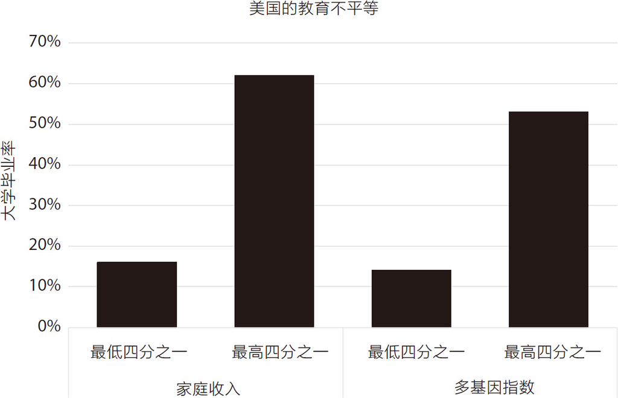

图1.1 美国大学毕业率的不平等，基于家庭收入的差异与遗传差异。家庭收入与大学毕业率之间关系的数据，出自Margaret W.Cahalan et al.,Indicators of Higher Education Equity in the United States:2020 Historical Trend Report (Washington,DC:The Pell Institute for the Study of Opportunity in Higher Education,Council for Opportunity in Education (COE),and Alliance for Higher Education and Democracy of the University of Pennsylvania (PennAHEAD),2020),https://eric.ed.gov/?id=ED606010。多基因指数与大学毕业率之间关系的数据，出自James J.Lee et al.,“Gene Discovery and Polygenic Prediction from a Genome-Wide Association Study of Educational Attainment in 1.1 Million Individuals,”Nature Genetics 50,no.8 (August 2018):1112–21,https://doi.org/10.1038/s41588-018-0147-3 ；额外分析由Robbee Wedow提供。多基因指数分析的对象仅包括这样的人：他们具有共同的遗传血统特征，他们的近代祖先都居住在欧洲。在美国，这样的人在种族上很可能被认定为白人。种族和遗传血统之间的区别将在第四章详述。

在本书中，我将论证，无论在实证层面还是道德层面，图1.1右侧的数据（显示基因和教育结果之间的关系）对理解社会不平等也是至关重要的。就像出生在富裕还是贫困家庭一样，一个人拥有某种遗传变异是“出生的抽彩”的结果。你没有办法选择你的父母：你既不能选择父母给你什么样的生活环境，也不能选择他们给你什么样的基因。而且，就像社会阶层一样，基因抽彩的结果是一种系统性的力量，它能决定，对于我们在社会中想要的几乎一切，谁会得到更多，谁会得到更少。

#### 人们如何看待遗传学

如果你认为遗传跟教育不平等和社会不平等有关联，那么你就是在自找麻烦。这个想法似乎很危险。坦率地说，这似乎属于优生学。一位历史学家将那些把遗传与大学毕业等结果联系在一起的科学家跟屠杀犹太人的德国人相提并论，称这些科学家为“CRISPR技术的自愿刽子手”。 ㊟ 【Nathaniel Comfort,“Nature Still Battles Nurture in the Haunting World of Social Genomics,”Nature 553 (January 15,2018):278–80,https://doi.org/10.1038/d41586-018-00578-5.】 一位同行曾给我发邮件说，因为我在做遗传学和教育方面的研究，所以我“并不比否认大屠杀的人好”。根据我的经验，许多学者持有这样的信念：讨论社会不平等的遗传原因，从根本上说是种族主义、阶级主义和优生主义的做法。

那些探讨遗传造成的个体差异的科学家，在一般公众眼中的形象如何呢？我们也有一些了解。公众的态度是非常负面的。

在一项社会心理学研究中，实验参与者被要求阅读一个关于虚构的科学家卡尔松博士的故事。 ㊟ 【Ivar R.Hannikainen,“Ideology Between the Lines:Lay Inferences About Scientists'Values and Motives,”Social Psychological and Personality Science 10,no.6 (August 1,2019):832–41,https://doi.org/10.1177/1948550618790230.】 这个小故事有两个版本。在这两个版本中，卡尔松博士的研究项目和科学方法被以完全相同的方式描述，不同的是卡尔松博士的研究结论。在一个版本中，实验参与者得知，卡尔松博士发现，遗传原因与数学能力测试成绩关系不大，遗传只能解释人与人之间成绩差异的4%左右。在另一个版本的研究结论中，遗传因素的影响更强，能解释成绩差异的26%。

在阅读了这些研究结论之后，参与者受到提问，卡尔松博士同意下列五项声明的可能性有多大。

1.人们在社会中的地位应当与他们的先天能力匹配。

2.我相信人们和社会群体应当被平等对待，不考虑其能力。

3.某些人拥有天赋，所以他们应当被视为优于其他人。

4.如果社会允许某些人比其他人拥有更多的权力和成功，这没问题，因为这是自然法则。

5.社会应当努力创造公平的竞争环境，使社会变得公正。

这些声明旨在衡量“平等主义”价值观。《韦氏词典》对“平等主义”(egalitarianism)的定义是：“对人类平等的信仰，特别是在社会、政治和经济事务方面；一种主张消除人与人之间不平等的社会哲学。”当实验参与者读到卡尔松博士发现遗传与数学能力有较强关联的证据时，他们认为他具有较差的平等主义价值观，也就是说：卡尔松希望将某些人视为优于其他人，对使社会更加公正不感兴趣，不相信人们应该被平等对待。

这项研究还发现，认为遗传对智力有影响的科学家也被认为是不太客观的，更可能是先有结论然后去找证据，而且更有可能在开始其科研生涯之前就持有不平等主义的信念。自称是政治保守派的人一律怀疑科学家的客观性，不管其研究结果如何，而自称是政治自由派的人，在科学家报告遗传对智力有影响时，特别容易怀疑他的客观性。

这项研究很重要，因为实验参与者并不是在遗传学、数学或政治哲学方面有特殊专长的科学家或学者。他们是大学本科生，参与这个实验是课程的要求；或者是在家工作的人，想通过填写调查问卷来赚外快。这项研究表明，人们，特别是具有自由主义政治意识形态的人们，十分普遍地相信，“关于遗传如何确实(do)影响人类行为的经验性陈述”与“关于人们应当(should)被平等对待的道德信念”是不相容的。

#### 优生学影响深远的遗产

很多人认为遗传学研究的结果与社会平等不相容，这当然是有充分理由的。一百五十多年来，人类遗传学一直被用来推进种族主义和阶级主义的意识形态，对被列入“劣等”的人造成了可怕的后果。

1869年，弗朗西斯·高尔顿（查尔斯·达尔文的表弟，发明了“优生学”一词）出版了《遗传的天赋》。 ㊟ 【Francis Galton,Hereditary Genius:An Inquiry into Its Laws and Consequences (London and New York:Macmillan,1892).】 这本书基本上由数百页族谱组成，旨在证明英国的阶级结构是由“卓越品质”(eminence)的生物遗传产生的。换句话说，在科学、商业和法律方面有卓越专业成就的人，必然是其他伟人的后代。《遗传的天赋》以及高尔顿在1889年出版的《自然遗传》 ㊟ 【Francis Galton,Natural Inheritance (New York and London:Macmillan,1894).】 ，将“遗传”研究重塑为对亲属之间可测量的相似性的研究。 ㊟ 【Daniel J.Kevles,In the Name of Eugenics:Genetics and the Uses of Human Heredity (New York:Alfred A.Knopf,1985;repr.,Cambridge,MA:Harvard University Press,1998).】 这种科学方法一直延续到今天，我将在本书中描述的许多研究都是这样的。

不过，高尔顿不满足于仅仅以族谱的形式记录亲属的相似性。他希望对这种相似性进行量化，也就是用数字来表示。量化是他的毕生爱好，他的口号是“只要能做到，就计数”。 ㊟ 【Kevles.】 在寻找亲属相似性的数学表达时，高尔顿发明了一些基础的统计学概念，如相关系数(correlation coefficient)。在发展统计学的同时，他还思考了如何在人类当中操纵遗传。在1883年发表的某著作的一个脚注中，高尔顿提出了“优生学”(eugenics)这一新词，以“指称改良种群素质的科学”，其目的是“使更合适的种族或血统有更好的机会迅速胜过不合适的种族或血统”。 ㊟ 【Francis Galton,Inquiries into Human Faculty and Its Development (London:Macmillan,1883;second edition,Macmillan,1907,online at Project Gutenberg,http://www.gutenberg.org/ebooks/11562.】 因此，从一开始，新生的统计学和运用统计学来研究亲属相似性模式的手段，就与种族优越性的观念以及为改良物种而干预人类生殖的提议纠缠在一起。

高尔顿于1911年去世，生前向伦敦大学学院捐赠了一笔钱，以设立高尔顿优生学教授讲席，这个讲席被授予他的门生卡尔·皮尔逊(Karl Pearson)，他也是伦敦大学学院新成立的应用统计系的系主任。 ㊟ 【Kevles,In the Name of Eugenics.】 皮尔逊在他的岗位上继续为统计方法做出基础性的贡献，这些方法如今被普遍应用于科学和医学的每个学科。他用一种中立的语言来掩饰自己的研究活动：“我们高尔顿实验室的人并没有私利要追求。我们追寻真理的工作不会给我们带来任何好处，我们也没有任何损失。”但皮尔逊在政治上并不是中立的。皮尔逊以“心理特征”（如教师对学生的学术能力的评估）的家族相关性的统计数据为幌子，认为进步时代的社会改革，如全民教育，是无用的。他还反对劳动保护，如禁止童工、最低工资和八小时工作制等措施，理由是这些改革鼓励“无能力者”的繁殖。 ㊟ 【Kevles.】

在美国，查尔斯·达文波特(Charles B.Davenport)像高尔顿和皮尔逊一样，对家庭谱系数据的定量研究充满热情。达文波特在纽约长岛的冷泉港建立了一个优生学档案办公室。1910年，达文波特任命哈里·H.劳夫林为该办公室的主管，从而大力支持了美国历史上最强有力的优生立法倡导者。

新官上任之后，劳夫林差不多立刻就开始为他后来的著作《美国的优生绝育》做研究。 ㊟ 【Harry Hamilton Laughlin,Eugenical Sterilization in the United States (Chicago:Psychopathic Laboratory of the Municipal Court of Chicago,1922),http://hdl.handle.net/2027/hvd.hc4mzw.】 该书最终于1922年出版。劳夫林在书中引用了强制疫苗接种和隔离检疫等法律先例，主张“国家有权为改良种族而限制生育”。书中给出了“优生绝育法的范本”，供各州立法机构修改和采用，以防止“因遗传缺陷而不符合社会要求的人传宗接代”。“不符合社会要求”的人的定义是：任何“长期不能……使自己成为国家有组织的社会生活中有用成员”的人，以及“精神不健全”、罹患精神病、犯罪、罹患癫痫、酗酒、罹患梅毒、眼盲、耳聋、肢体残疾的人，孤儿、无家可归者和“流浪汉与贫民”。1924年，弗吉尼亚州通过了《优生绝育法》，该法直接使用了劳夫林范本的措辞。 ㊟ 【“Harry Laughlin and Eugenics:Laughlin's Model Law,”a selection from the Harry H.Laughlin Papers,Truman State University,accessed November 28,2020,https://historyofeugenics.truman.edu/altering-lives/sterilization/model-law/.】

急于确立弗吉尼亚州《优生绝育法》合宪性的优生学家很快在卡丽·巴克(Carrie Buck)身上找到了一个理想的试验案例。巴克的亲生母亲埃玛患有梅毒，巴克在被养父母的侄子强奸后，未婚生下了女儿薇薇安。 ㊟ 【“Carrie Buck Revisited and Virginia's Expression of Regret for Eugenics,”Eugenics:Three Generations,No Imbeciles:Virginia,Eugenics & Buck v.Bell (blog),accessed February 3,2021,http://exhibits.hsl.virginia.edu/eugenics/5-epilogue/.】 在“巴克诉贝尔案”中，最高法院大法官奥利弗·温德尔·霍姆斯代表多数派意见，支持弗吉尼亚州的《优生绝育法》，并对巴克家族做出了一句臭名昭著的评价：“三代低能儿已经够多了。”在“巴克诉贝尔案”宣判之后，一直到1972年，有8000多名弗吉尼亚人被政府强制绝育。其他一些州效仿弗吉尼亚州的做法，导致大约有六万名美国人被强制绝育。 ㊟ 【Paul Lombardo,“Three Generations,No Imbeciles:New Light on Buck v.Bell,”New York University Law Review 60,no.1 (April 1985):30–63,https://readingroom.law.gsu.edu/cgi/viewcontent.cgi?article=2593&context=faculty_pub.】

不过，对最热心的优生学支持者来说，绝育的速度还是太慢了。1933年希特勒上台之后不久，德国通过了自己版本的劳夫林绝育法，这时美国优生学家大力敦促在美国扩大绝育计划。约瑟夫·德贾尼特哀叹道：“德国人在我们发明的游戏中打败了我们。”德贾尼特出生于南方邦联的奴隶种植园，曾在“巴克诉贝尔案”中作证反对卡丽·巴克，并在弗吉尼亚州斯汤顿市的西部州立医院担任院长，监督了上千例绝育手术。 ㊟ 【“DeJarnette,Joseph S.(1866–1957),”Encyclopedia Virginia,accessed November 28,2020,https://www.encyclopediavirginia.org/DeJarnette_Joseph_Spencer_1866-1957#start_entry.】

1935年，纳粹政府通过了《纽伦堡法》，禁止犹太人和非犹太裔德国人结婚，并剥夺了犹太人、罗姆人和其他群体的合法权利和公民身份。这一年，劳夫林写了一封信给他的纳粹同行欧根·菲舍尔(Eugen Fischer)。菲舍尔在“异族通婚问题”方面的工作为《纽伦堡法》提供了意识形态基础。 ㊟ 【Paul A.Lombardo,“‘The American Breed':Nazi Eugenics and the Origins of the Pioneer Fund,”Albany Law Review 65,no.3 (2002):743–830,available at SSRN:https://papers.ssrn.com/abstract=313820.】 劳夫林给菲舍尔写信的目的，是把他介绍给威克利夫·普雷斯顿·德雷珀(Wickliffe Preston Draper)，德雷珀是一位纺织业巨头和优生学爱好者，不久之后将前往柏林参加纳粹关于“种族卫生”的会议。 ㊟ 【Lombardo,“‘The American Breed.’”】

回到美国后，德雷珀与劳夫林合作建立了开拓者基金会(Pioneer Fund)，该基金会于1937年成立，至今仍然存在。基金会的名字是为了纪念最早在美利坚殖民地定居的“开拓者”家庭，宗旨是促进对人类遗传和“种族改良问题”的研究。其最早期的活动之一是发行一部关于绝育的纳粹宣传片《遗传病》(Erbkrank)，该片得到了希特勒本人的特别认可。 ㊟ 【Lombardo.】

从20世纪初的这些优生主义者到今天的白人至上主义者，无论是在活动资金上还是在意识形态上，他们都有着直接的传承关系。例如，自称“种族现实主义者”的贾里德·泰勒认为美国黑人没有能力实现“任何形式的文明”，他最近便接受了开拓者基金会的资助。 ㊟ 【“Jared Taylor,”Southern Poverty Law Center,accessed November 28,2020,https://www.splcenter.org/.ghting-hate/extremist-.les/individual/jared-taylor.】 泰勒继承了皮尔逊和劳夫林的意识形态传统，将遗传学当作反对社会平等和政治平等的宣传武器。他在对行为遗传学家罗伯特·普罗明（我将在本书中介绍他的工作）的著作《基因蓝图》的评论中称，遗传学的新发展将敲响社会正义的丧钟：“如果［这些］科研结论被广泛接受，它们将摧毁过去六十多年来整个平等主义事业的根基。” ㊟ 【Jared Taylor,“Blueprint:How DNA Makes Us Who We Are,”review,American Renaissance,January 4,2019,https://www.amren.com/features/2019/01/blueprint-how-dna-makes-us-who-we-are/;Robert Plomin,Blueprint:How DNA Makes Us Who We Are (MIT Press,2018).】

2017年，白人至上主义者聚集在夏洛茨维尔，参加“团结右翼”(Unite the Right)集会。 ㊟ 【Hawes Spencer and Sheryl Gay Stolberg,“White Nationalists March on University of Virginia,”The New York Times,A12,August 11,2017,https://www.nytimes.com/2017/08/11/us/white-nationalists-rally-charlottesville-virginia.html.】 穿着卡其布服装的男子挥舞着纳粹旗帜，高呼“犹太人不会取代我们”，游行穿过埋葬着卡丽·巴克的小镇。这提醒我们，将种族隔离时代的弗吉尼亚州与纳粹德国联系起来的那种“种族纯洁”的疯狂意识形态，并未完全消失，而且它给巴克这样的贫穷白人带来了恐怖的后果。

#### 遗传学与平等主义：预览

在《遗传的天赋》出版之后的一个半世纪里，遗传学家查明了遗传的物理物质，发现了DNA的双螺旋结构，克隆了一只绵羊，对解剖学意义的现代人和尼安德特人的基因组进行了测序，创造了三亲胚胎(three-parent embryo)，并研发了CRISPR-Cas9技术来直接编辑DNA序列。但在这一个半世纪里，人们对遗传差异与社会不平等之间关系的理解，与高尔顿最初的表述几乎没有什么不同：经验性的主张（“人们的遗传差异导致了生理、心理和行为上的差异”）与道德应然（“一些人应该被视为优于其他人”）混在一起，可能产生可怕的后果。

本书的目标是重新认识遗传学与平等之间的关系。我们能否将人类行为遗传学（从高尔顿的观察开始，一直到关于智力和受教育程度的现代遗传学研究）从几十年来与之纠缠的种族主义、阶级主义和优生主义意识形态中剥离出来？我们能想象一种新的合题(synthesis)吗？这种新的合题能否拓展我们对平等以及如何实现平等的理解？

为了帮助解释我们可以如何重新思考遗传学与平等主义之间的关系，在此不妨描述一下我与遵循高尔顿传统的一本书——理查德·赫恩斯坦和查尔斯·默里的《钟形曲线》的分歧之处。 ㊟ 【Richard J.Herrnstein and Charles Murray,The Bell Curve:Intelligence and Class Structure in American Life (New York:Free Press,1994).】 《钟形曲线》的书名是对高尔顿的统计学关怀的致敬。高尔顿观察到，将人类特征不同数值的群体频率(population frequency)绘成图，会形成一个具有特殊数学性质的钟形“正态”分布。《钟形曲线》的副书名“美国生活中的智力和阶级结构”是对高尔顿的社会关怀的致敬，即阶级差异如何反映基因遗传的问题。

赫恩斯坦和默里关注的不是“卓越品质”，而是智力，并用抽象推理能力的标准化测试来衡量智力。与赫恩斯坦和默里一样（也与绝大多数心理学家一样），我也相信智力测试测量的是一个人心理的某个方面，这个方面与人们在当代教育体制和劳动力市场上的成功有关；并且双生子研究(twin study)告诉我们，人与人之间的个体差异是有遗传原因的，而且智力是可遗传的（这是一个被严重误解的概念，我将在第六章中详细解释）。鉴于这些观点上的相似之处，难免会有人将本书与《钟形曲线》以及赫恩斯坦于1973年出版的关于智商和优绩主义的书进行比较。 ㊟ 【Richard J.Herrnstein,I.Q.in the Meritocracy (Boston:Little,Brown,1973).】 因此，在此简要列举我与赫恩斯坦、默里的观点差异，不仅可以预先避免误解，还可以预示我将在本书中提出的观点。

在本书中，我将论证，研究人类个体差异的科学完全可以与强有力的(full-throated)平等主义相容。《钟形曲线》的最后一节提到，可以用遗传学来支持平等主义的论点，以实现更大的经济平等。“为什么［某人］的收入和社会地位要受到惩罚？……我们可以承认，这不是一个‘活该如此’的问题，而是一个经济实用主义的问题，即如何为社会中最弱势的群体提供补偿性的利益。”

这短短几句话包含了两个重要的观点：(1)人们不应该仅仅因为他们碰巧遗传了某些特定的DNA组合而“活该”在经济上处于不利地位；(2)社会应该被组织起来，以便使社会中处境最不利的成员受益。在《钟形曲线》中看到这些观点，颇有些令人迷惑，因为它们听起来像是出自一本与之迥异的书：平等主义政治哲学家约翰·罗尔斯的《正义论》。

在《正义论》中，罗尔斯用“自然抽彩”(natural lottery)的比喻来描述人们在生活中的初始位置是多么不同。正如我将在第二章描述的，抽彩是描述遗传的一个绝佳的比喻：每个人的基因组都是大自然的强力球彩票的结果。

然后，罗尔斯用了几百页的篇幅来探讨应该如何安排一个公正的社会，因为人们在自然和社会这两种“出生的抽彩”中的结果确实存在差异。罗尔斯远没有把人们在“先天能力”上的差异看作将不平等正当化的理由，他谴责那些按照“自然界中的任意性”构建的社会的不公正。他的正义原则使他认为，源于自然抽彩的不平等，只有在它有利于社会中最弱势者的情况下才可以被接受。在罗尔斯看来，认真对待人与人之间的生物差异并没有损害平等主义；恰恰相反，生物差异是促使他倡导更平等社会的理由之一。

《钟形曲线》对罗尔斯思想的短暂提及，模糊地指向了一种探讨遗传学和社会平等的新方式。但是，赫恩斯坦和默里在花了半页篇幅以诱人的方式探讨平等主义之后，又退回到其根底里的不平等主义，并抱怨道：“说一些人比其他人优越，这种说法已经变得令人反感了……尽管我们对有些东西比其他东西更好的想法不会见怪——不仅根据我们的主观观点，而且根据持久的优劣标准。”（强调是我加的）读了500页《钟形曲线》之后，我们会清楚地看到，赫恩斯坦和默里认为什么样的东西和什么样的人更好。按照他们的说法，在智商测试中得分较高的人就是优越的；白人就是优越的；阶级较高的人就是优越的。事实上，他们把经济生产力（“对世界的付出多于索取”）描述为“人类尊严的基础”。

让我们将赫恩斯坦和默里认为一些人比其他人优越的油腻观点，跟政治哲学家伊丽莎白·安德森给出的不平等主义的定义进行比较 ㊟ 【Elizabeth S.Anderson,“What Is the Point of Equality?,”Ethics 109,no.2 (January 1999):287–337,https://doi.org/10.1086/233897.】 ：

不平等主义主张，将社会秩序建立在人类的等级制度上，是公正的或必要的，而人类的等级是根据人类内在价值来划分的。不平等与其说是指商品分配的不平等，不如说是指优等人与劣等人之间的关系……这种不平等的社会关系产生了自由、资源和福利分配上的不平等，并被认为是这些不平等的正当理由。这是种族主义、性别歧视、民族主义、种姓制度、阶级和优生主义等不平等主义意识形态的核心。

换句话说，优生学意识形态认为，人类可分为三六九等，一个人的DNA决定了他的内在价值和他在等级制度中的地位。根据优生学思想，由这种等级制度产生的社会、政治和经济不平等（优等人得到更多，劣等人得到更少）是不可避免的、自然的、公正的和必要的。

对优生学意识形态的标准反驳，是强调人类基因的同一性。毕竟，如果人类的DNA没有差异，就不能用DNA差异来决定人的价值和等级。这种将政治平等和经济平等跟基因相似性联系起来的立场，在比尔·克林顿总统宣布“人类基因组计划”已经完成人类DNA序列第一份完整草案的措辞中得到了明确的体现。 ㊟ 【“Remarks by the President ...on the Completion of the First Survey of the Entire Human Genome Project,”White House press release,June 26,2000,https://clintonwhitehouse3.archives.gov/WH/New/html/genome-20000626.html.】 克林顿大力宣扬人类的基因同一性，认为这是一个支持平等主义理想的经验真理(empirical truth)：

人人生来平等，在法律面前人人平等……我相信，从这次对人类基因组的胜利考察中得出的一个伟大真理是，从遗传学角度看，所有人类，无论什么种族，都有99.9%以上的相同之处。

克林顿在另一个场合承认自己“犯了错误”，而我认为将基因同一性与平等主义理想联系起来也是克林顿的错误之一。的确，与盘绕在每个人的细胞中的长长的DNA链条相比，任何两个人之间的遗传差异都是极小的。但是，在试图理解为什么一个孩子有自闭症而另一个孩子没有，为什么一个人耳聋而另一个人有正常听力，以及（正如我将在本书中描述的）为什么一个孩子的学习成绩很差而另一个很好时，我们之间的遗传差异就显得非常重要了。遗传差异对我们的生活有着深刻的影响。它们导致了我们所关心的事情的不同。把对平等主义的承诺建立在人类基因的同一性上，就是沙上建塔。

生物学家J.B.S.霍尔丹将卡尔·皮尔逊比作克里斯托弗·哥伦布：“皮尔逊的遗传理论在某些基本方面是不正确的。哥伦布的地理理论也是如此。他出发去找中国，结果发现了美洲。” ㊟ 【J.B.S.Haldane,“KARL PEARSON,1857–1957,”Biometrika 44,no.3–4 (December 1957):303–13,https://doi.org/10.1093/biomet/44.3-4.303.】 我认为，将哥伦布跟皮尔逊及其优生学同行进行比较，确实是有道理的。哥伦布与皮尔逊等人在理论上的错误的严重性、他们给无辜人民带来的暴力和伤害的严重性，以及他们发现的东西的重要程度，都是相似的。我们已经有了相关的知识，所以不能假装美洲大陆不存在。同样，我们已经有了相关的知识，所以不能假装基因不重要。相反，我们必须小心翼翼地剔除优生主义者的科学错误和意识形态谬误，我们必须阐明如何在平等主义框架内理解遗传科学。

在本书中，我将论证，说人们在基因上有差异，并不等于优生主义。说人与人之间的遗传差异导致一些人更容易发展某些技能和功能，也不等于优生主义。社会科学家研究和记录教育体制、劳动力市场和金融市场如何以经济形式和其他形式奖励人们特定的、受历史和文化影响的天赋和能力，也不等于优生主义。那么，怎么样才算是优生主义呢？将人固有的劣势和优势、人类的等级或自然秩序的概念，与人类的个体差异以及造成这些个体差异的遗传变异联系起来，那就是优生主义。在遗传变异随机分配的基础上，制定和实施在资源、自由和福利方面造成或巩固人们之间不平等的政策，那就是优生主义。

那么，反优生主义就是要(1)了解遗传的运气在塑造我们的身体和大脑方面所起的作用；(2)记录我们当前的教育体制、劳动力市场和金融市场如何奖励具有某些类型身体和大脑（而不是其他类型的身体和大脑）的人；以及(3)重新思考如何能够改变这些体制，使其包容所有人，无论人们的基因抽彩的结果如何。正如哲学家罗伯托·曼加贝拉·昂格尔所写的，“社会是人构建和想象出来的……它是人造的，而不是潜在自然秩序的表达”。 ㊟ 【Roberto Mangabeira Unger,Social Theory:Its Situation and Its Task (Cambridge,UK:Cambridge University Press,1987;repr.,London and Brooklyn:Verso,2004);“Roberto Mangabeira Unger's Alternative Progressive Vision,”The Nation,July 21,2020,https://www.thenation.com/article/culture/roberto-mangabeira -ungers-alternative-progressive-vision/.】 本书将对自然界（通过遗传变现出来）的理解，视为“重塑和重新想象社会”这项事业的盟友，而不是敌人。

#### 为什么我们需要一种新的合题

遗传学对推进社会平等有助益，这种说法经常遭到质疑。我们都深刻认识到了优生学的潜在危险。将遗传与社会不平等联系起来，看起来好像没什么好处。即使我们能够将遗传和平等主义综合起来，我们为什么要冒险？鉴于美国优生学的黑历史和恶劣影响，设想遗传学研究能够以一种新的方式被理解和应用，可能显得过于乐观，甚至幼稚。

但是，在考虑风险和利益的时候，很多人忘记了继续维持现状带来的风险。现状就是，学术界和非专业人士普遍认为，了解个体之间的遗传差异如何造成社会不平等，是一种禁忌。但这种现状已经无以为继。

正如我将在第九章中解释的，忽视人与人之间存在的遗传差异的普遍趋势，阻碍了心理学、教育学和社会科学其他分支的进步。 ㊟ 【Jeremy Freese,“Genetics and the Social Science Explanation of Individual Outcomes,”American Journal of Sociology 114,suppl.S1 (2008):S1–35,https://doi.org/10.1086/592208.】 这导致我们在理解人类发展和施加干预以改善人类生活方面的成功率，远远低于我们原本可以做到的。并没有无限的政治意愿和资源可以用来改善人们的生活；并没有无限的时间和金钱可以浪费在不可行的方案上。正如社会学家苏珊·迈尔所说，“如果你想帮助［人们］，你必须真正知道他们需要什么样的帮助。你不能简单地自信已经掌握了解决方案”（强调是我加的）。 ㊟ 【“Susan Mayer on What Money Can't Buy,”Econlib,accessed July 22,2020,http://www.econtalk.org/susan-mayer-on-what-money-cant-buy/.】 如果社会科学家要共同面对改善人类生活的挑战，我们就不能忽视一个关于人性的基本事实：人们不是生来就一模一样的。

忽视人与人之间的遗传差异，也留下了一个阐释的真空，而政治极端分子都很乐意填补。贾里德·泰勒并不是唯一对遗传学兴致盎然的极端分子。正如遗传学家耶底底亚·卡尔森和凯丽·哈里斯总结的，“白人民族主义运动的成员和附属机构是科学研究的贪婪消费者”。 ㊟ 【Jedidiah Carlson and Kelley Harris,“Quantifying and Contextualizing the Impact of bioRxiv Preprints through Automated Social Media Audience Segmentation,”PLOS Biology 18,no.9 (September 22,2020):e3000860,https://doi.org/10.1371/journal.pbio.3000860.】 记者和科学家们都对“风暴前线”（Stormfront，其座右铭为“白人骄傲全世界”）等白人至上主义网站如何剖析和利用遗传学研究敲响了警钟。 ㊟ 【Amy Harmon,“Why White Supremacists Are Chugging Milk (and Why Geneticists Are Alarmed),”The New York Times,October 17,2018,https://www.nytimes.com/2018/10/17/us/white-supremacists-science-dna.html;Aaron Panofsky and Joan Donovan,“Genetic Ancestry Testing among White Nationalists:From Identity Repair to Citizen Science,”Social Studies of Science 49,no.5 (October 1,2019):653–81,https://doi.org/10.1177/0306312719861434;Michael Price,“‘It's a Toxic Place.'How the Online World of White Nationalists Distorts Population Genetics,”Science,May 22,2018,https://www.sciencemag.org/news/2018/05/it-s-toxic-place-how-online-world-white-nationalists-distorts-population-genetics.】 卡尔森和哈里斯分析了社交媒体用户如何分享科学家发布在bioRxiv资料库的论文，所以这两位研究者能够为上述现象提供可靠的数字。他们的分析显示，关于遗传学的论文在白人民族主义者中特别受欢迎。

我在自己的工作中也看到了这种现象。以我与别人合著的一篇论文为例，该论文论述了遗传差异与所谓“非认知技能”之间的关系，经济学家认为“非认知技能”与正规教育的成功有关（我将在第七章详细解释这篇论文）。 ㊟ 【Perline Demange et al.,“Investigating the Genetic Architecture of Noncognitive Skills Using GWAS-by-Subtraction,”Nature Genetics 53 (January 7,2021):35–44,https://doi.org/10.1038/s41588-020-00754-2.】 卡尔森和哈里斯的分析发现，在这篇论文的六个最大的推特受众群中，有五个受众群，从他们的简介和用户名的措辞来看，似乎是心理学、经济学、社会学、基因组学和医学领域的学者（图1.2）。而第六个受众群是由某些类型的推特用户组成的，他们的简介中包括“白人”“民族主义者”等词语，以及绿青蛙表情符号，反犹主义和白人至上主义群体会用这种表情符号表达仇恨。 ㊟ 【“Pepe the Frog,”Anti-Defamation League,accessed August 6,2020,https://www.adl.org/education/references/hate-symbols/pepe-the-frog.】

这是一个危险的现象。我们生活在遗传学研究的一个黄金时代，新技术使我们可以很容易地收集来自千百万人的遗传数据，并迅速开发出新的统计方法来分析这些数据。但是仅仅生产新的遗传学知识是不够的。随着遗传学研究离开象牙塔并在公众中传播，科学家和公众必须努力明确这项研究对人类身份认同与平等的意义。不过，创造意义的重要任务往往被拱手让给了最极端和充满仇恨的声音。正如埃里克·特克海默、理查德·尼斯贝特和我本人所警告的 ㊟ 【Eric Turkheimer,Kathryn Paige Harden,and Richard E.Nisbett,“Charles Murray Is Once Again Peddling Junk Science about Race and IQ,”Vox,May 18,2017,https://www.vox.com/the-big-idea/2017/5/18/15655638/charles-murray-race-iq-sam-harris-science-free-speech.】 ：

如果具有进步政治价值观的人（他们拒绝接受遗传决定论和伪科学的种族主义臆想）自己放弃了在人类能力科学和人类行为遗传学领域教育公众的责任，那么公众传播界就会被那些不认同进步政治价值观的人主宰。

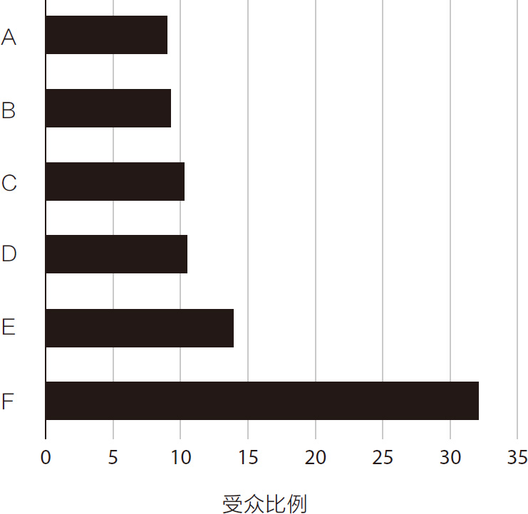

前六大受众群的推特关键词

A 博士，学生，遗传学，基因组学，研究(research)，生物学，大学，科学，实验室，科学家，博士后，生物信息学，生物学家，数据，分子，研究者，癌症，研究员，候选人，教授，计算的，研究(studying)，人类，……

B 健康，医学博士，医学的，医疗保健，医药，护理，研究，医生，博士，公共，内科医生，主任，教授，科学，临床，作者，教育，家庭，营养，病人，新闻，研究者，激情的，倡导者，服务……

C ， ，让美国再次伟大， ，白人，民族主义者，美国人，特朗普，保守，生命，世界， ，上帝，基督徒，人民，美国， ，自由，真理， ，爱，媒体，新闻，骄傲， ，时间，国家， ，音乐，天主教徒

D 研究，教授(professor)，健康，博士，社会学，大学，政策，社会学家，科学，研究者，教授(prof)，助理，学生，数据，公众，不平等，研究员，人群，家庭，人口统计学，教育，联系，政治……

E 经济学，博士，经济学家，教授(professor)，研究，发展，学生，大学，政策，助理，经济，健康，候选人，公众，教育，数据，研究员，政治的，经济的，教授(prof)，助理，劳动力，实验室，科学，研究者

F 博士，研究(research)，心理学，遗传学，科学，大学，健康，学生，教授，心理学家，研究者，神经科学，认知，精神，临床，医生，大脑，科学家，研究员，人类，博士后，助理，数据，研究(studying)……

图1.2 关于遗传学和非认知技能的科学论文的前六大社交媒体受众群。受众分析方法见Jedidiah Carlson and Kelley Harris,“Quantifying and Contextualizing the Impact of bioRxiv Preprints through Automated Social Media Audience Segmentation,”PLOS Biology 18,no.9 (September 22,2020):e3000860,https://doi.org/10.1371/ journal.pbio.3000860。Audiences are presented for preprint of Perline Demange et al.,“Investigating the Genetic Architecture of Noncognitive Skills Using GWAS-by-Subtraction,”Nature Genetics 53,no.1 (January 2021):35–44,https://doi.org/10.1038/ s41588-020-00754-2.

#### 本书的目标

那么，关于人类能力的科学和人类行为遗传学对社会平等究竟意味着什么？为了回答这个问题，本书分两部分进行探讨。在第一部分，我希望能说服读者相信，遗传学对理解社会不平等很重要。对这一观点的常见反驳包括：双生子研究存在无可救药的缺陷；对遗传率(heritability)的估计毫无用处；被测DNA与人类的后天表现仅具有相关关系，并不能证明二者之间有因果关系；或者基因可能与人类的后天表现有因果关系，但如果我们不知道其中的机制，那么有无因果关系就不重要了。所有这些反对意见在仔细检视之下都站不住脚，但为了解释原因，我们有必要深入探讨行为遗传学研究的一些方法论细节，以及一些关于这些方法取得的成绩的科学哲学。

在第二章，我首先会更详细地解释基因彩票的比喻，并引入一些生物学和统计学概念，如基因重组(genetic recombination)、多基因遗传(polygenic inheritance)和正态分布(normal distribution)。在第二章，以及在整本书中，我会重点关注由偶然（chance，即通过遗传的自然抽彩）而非选择（choice，如通过胚胎植入前遗传诊断或其他生殖技术）所造成的人与人之间的遗传差异。 ㊟ 【Allen Buchanan et al.,From Chance to Choice:Genetics and Justice (Cambridge,UK:Cambridge University Press,2000).】

在第三章，我会解释一些常用的方法，特别是全基因组关联分析(Genome-wide association study)和多基因指数研究，如何用于检验个体遗传差异与生活结果差异之间的关系。然后，第四章会解释全基因组关联分析的结果不能告诉我们群体特别是种族群体之间的差异的原因。关于“先天性”种族差异的书籍和文章不断涌现，固然热闹，却毫无意义。关于社会不平等的遗传学研究，包括双生子研究和DNA的测量研究，则几乎完全集中在个体差异上，而这些个体近期的遗传血统完全属于欧洲 ㊟ 【令人沮丧的是，对于用什么措辞来描述遗传血统的模式，学界仍然没有达成共识。我按照惯例，用“欧洲的”这个形容词来描述具有某些遗传血统模式的人，但我认识到这种措辞并不精确，对不同的读者可能有不同的直观含义，而且有可能将种族的社会类别具体化为“纯”生物学的实体。我将在第四章更详细地讨论这些问题。Adam Auton et al.,“A Global Reference for Human Genetic Variation,”Nature 526,no.7571 (October 2015):68–74,https://doi.org/10.1038/nature15393.】 ，绝大部分都有可能被认定为白人。

研究范围的这种缩小，为我在本书中描述的所有经验性结论提供了一个基本的限定。对社会表型和行为表型(phenotypes)的遗传学研究，由于其目前集中于欧洲遗传血统的人士，所以不能有意义地帮助我们科学地理解种族和民族群体之间的社会不平等。不过，正如我在第四章中描述的，我们对“人们为何一再回到毫无科学意义的遗传种族差异问题”的考虑，揭示了某些人如何以遗传学的解释为借口，拒绝社会变革，否认人们肩负着推动变革的社会责任。这个借口将遗传视为否定社会责任的理由。无论基因在社会构建的种族群体之内或之间如何分布，我们都必须消灭这个借口。

考虑到群体差异和个体差异的区别，第五章首先讨论关于全基因组关联分析和多基因指数研究结果的一个基本问题：这些研究能否解释遗传原因？为了回答这个问题，我会退一步，先回答一个更普遍的问题：“什么是原因？”明确了什么是原因（以及什么不是原因）之后，第六章将探讨全基因组关联分析和遗传率研究的结果。在这里，我也审视了大量的证据，它们表明基因会导致重要的生活结果，包括受教育程度。第七章是本书第一部分的结尾，描述了我们如何理解基因和教育之间的联系机制。

在本书的第二部分，我会探讨这样的问题：既然我们已经知道遗传学对于理解社会不平等很重要，那么我们应当如何运用这一知识？一旦我们抛弃了优生学的提法，即遗传差异构成了人类先天优劣等级的基础，那么还剩下什么？在第八章和第九章，我会探讨理解人与人之间的遗传差异如何能够帮助我们通过社会政策和干预来改变世界。在第十章，我会探讨这样的问题：为什么人们会拒绝接受有关人类行为之遗传原因的信息，以及为什么认定基因是人们生活中运气的来源，实际上会减少在教育和经济上“不成功”的人受到的指责。在第十一章，我会探讨为什么很难将“遗传对智力测试分数和教育结果的影响”从人类优劣的概念中剥离出来，并将“我们如何看待关于人类心理这些方面的遗传学研究”与“我们如何看待关于其他特征（如耳聋或自闭症）的遗传学研究”做一个比较。最后，在第十二章，我会描述反优生的科学与政策的五项原则。

在整本书中，我不会试图掩盖我自己的“左”倾政治立场。但我真诚地希望，即使是政治立场与我截然不同的读者，也会相信我在本书中思考的问题是重要的，即使他们坚决不同意我给出的答案。我请我的保守派读者记住，古希腊人、《圣经》作者和美国开国元勋也关注“正义”这个理念。在一个技术变革加速、遗传学知识激增的时代，我们如何像先知弥迦劝诫的那样“行公义” ㊟ 【《旧约·弥迦书》第6章第8节：“世人哪，耶和华已指示你何为善。他向你所要的是什么呢？只要你行公义，好怜悯，存谦卑的心，与你的神同行。”据和合本。】 ？我相信，不管我们属于哪个党派，“正义”都是一个对我们所有人都有重大影响的问题。

写一本关于平等的书需要勇气。作为心理学家和行为遗传学家，我自己的专长和学术研究领域是儿童和青少年时期人类行为的遗传学。关于平等的理论很少谈及基因。不过，关于平等的理论确实谈到了技能、天赋、能力、禀赋、才干、雄心、竞争、优绩、运气、先天性、偶然性和机会。而且，我希望通过本书告诉读者，行为遗传学领域对所有这些问题都有很多话要说，尽管遗传学能（和不能）告诉我们的东西比乍看起来要复杂得多。

## 第二章

## 基因彩票

我女儿的生活中，最有魅力的人是一个叫凯尔的8岁女孩。她有一头飘逸的齐腰长发，用闪亮的蝴蝶结束发带挽着。她收藏了很多《冰雪奇缘》娃娃。而且，最诱人的是，凯尔家的前院里有一张蹦床。

蹦床是凯尔的妈妈在凯尔的双胞胎弟弟埃兹拉做脑部手术的那一年安装的游乐设施的一部分。埃兹拉患有自闭症和癫痫。大多数人不知道，自闭症儿童有较大可能同时患有癫痫。 ㊟ 【Roberto Tuchman and Isabelle Rapin,“Epilepsy in Autism,”The Lancet Neurology 1,no.6 (October 1,2002):352–58,https://doi.org/10.1016/S1474-4422(02)00160-6.】 尽管我接受过临床心理学训练，并管理着一个儿童发展研究实验室，但我在住到凯尔家隔壁之前也不知道这一点。自闭症儿童如果同时有智力障碍（临床上定义为智商低于70分），就特别容易受到癫痫的影响。超过20%的自闭症儿童同时患有癫痫。

埃兹拉4岁时，他的癫痫发作很快变得非常频繁，令他衰弱不堪，于是医生为他植入了迷走神经刺激器(vagus nerve stimulator)，这相当于大脑的起搏器。他仍在接受严格的高脂肪、低碳水化合物的生酮饮食，以控制他的癫痫发作。 ㊟ 【Christine A.Olson et al.,“The Gut Microbiota Mediates the Anti-Seizure Effects of the Ketogenic Diet,”Cell 173,no.7 (June 14,2018):1728–41.e13,https://doi.org/10.1016/j.cell.2018.04.027.】 埃兹拉的妈妈是一位有成就的学者，而且擅长做符合生酮饮食要求的美味的巧克力生日蛋糕。

在美国，被诊断为患有自闭症或智障的孩子的父母，几乎一定会读到一篇1980年代的文章，题为《欢迎来到荷兰》。 ㊟ 【Emily Perl Kingsley,“Welcome to Holland,”Contact 136,no.1 (January 2001):14,https://doi.org/10.1080/13520806.2001.11758925.】 这篇文章提出，有特殊需求的儿童的父母就像计划去意大利单程旅行的旅行者。他们学会了用意大利语说再见，并期待着看到米开朗琪罗的大卫雕像，但当他们的飞机降落时，空姐宣布他们降落在荷兰。他们没有办法离开荷兰。有的家长觉得这个比喻令人欣慰：“荷兰有郁金香。荷兰甚至有伦勃朗。”也有的家长认为这很让人恼火。“我厌倦了荷兰，想回家”是一位母亲博客上的帖子标题。 ㊟ 【Tara Lakes,“I'm Tired of Holland and I Want to Go Home,”Grace for That (blog),June 10,2015,https://momlakes.wordpress.com/2015/06/10/im-tired-of-holland-and-i-want-to-go-home/.】 我还没有问过荷兰人，他们对美国人用他们的国家来比喻养育一个有严重残疾的孩子有何看法。

因为埃兹拉有一个双胞胎姐姐，所以很容易让人设想，如果他们的家庭按计划在意大利而不是在荷兰降落，会是什么样子。凯尔在蹦床上蹦蹦跳跳，体态轻盈，能够轻松地与成年人交谈。自从他家搬到这里之后的几年里，埃兹拉的状况有所退步。他的说话能力和社交兴趣已经萎缩，步态也变得僵硬。双胞胎让我们着迷，既是因为他们的相同之处，也是因为他们的不同。凯尔并非埃兹拉的镜像，她是他的“反事实”，他的“如果……”。而且，“如果……”并不仅限于此。我们不仅可以将凯尔和埃兹拉相互比较，还可以将他们与未出生的三胞胎弟弟相比较，这个弟弟在子宫里就死亡了。

尽管我们通常无法确切地知道造成个别流产或自闭症病例的原因，但我们可以推测凯尔、埃兹拉和他们无名的三胞胎弟弟之间的遗传差异可能塑造了他们不同的命运。大约一半的早期妊娠流产是由基因异常造成的。 ㊟ 【Raj Rai and Lesley Regan,“Recurrent Miscarriage,”The Lancet 368,no.9535 (August 12,2006):601–11,https://doi.org/10.1016/S0140-6736(06)69204-0.】 在导致人易受自闭症影响的变异中，多达90%是人与人之间的遗传差异造成的。一个胎儿在分娩前死亡；另一个孩子度过了表面上正常的婴儿期，随后退步到沉默的状态；第三个孩子茁壮成长、蹦蹦跳跳、健谈。尽管他们有共同的父母，但兄弟姐妹的命运可能会有很大的不同。

明尼苏达大学的心理学家进行了一项研究，请人们估计遗传因素在诸如眼睛颜色、抑郁症和个性等方面“对人与人之间的差异有多大贡献”（图2.1），然后将这些估计值与科学界对某一特征的遗传率的共识进行比较。这个共识来自双生子研究中的估计，双生子研究指的是比较同卵双胞胎和异卵双胞胎在某些特征上的相似程度的研究。 ㊟ 【Emily A.Willoughby et al.,“Free Will,Determinism,and Intuitive Judgments About the Heritability of Behavior,”Behavior Genetics 49,no.2 (March 2019):136–53,https://doi.org/10.1007/s10519-018-9931-1.】 我将在第六章详谈遗传率的定义和双生子研究的细节，这里我只想指出，非专业人士对“遗传对人与人之间差异有多大影响”的估计，与双生子研究得出的遗传率估计值相当接近。而且，有一个人群的直觉尤其准，那就是多子女的母亲。

妈妈们的判断如此准确，是有道理的。多子女的母亲处于绝佳的位置，能够近距离观察人类差异的发展。我自己的几个孩子之间的差别虽然没有凯尔和埃兹拉之间那么明显，但在我看来，他们之间的差别仍然是非常显著的。对多子女的父母来说，从他们的第二个孩子来到人世的那一刻起，他们就会体验到，第二个孩子的每一个发展里程碑都与第一个孩子大不相同。每个孩子都具有令人惊讶的独特性。

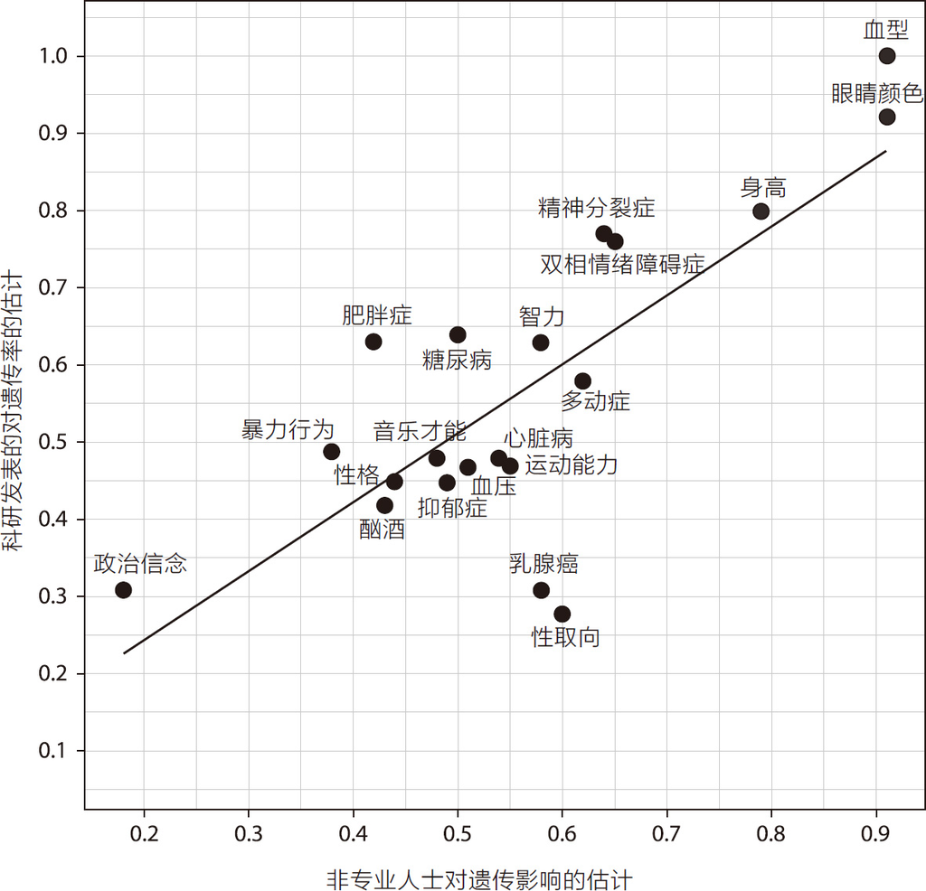

图2.1 人们对遗传因素之于人类差异的贡献程度的估计（横轴）与来自双生子研究的遗传率的科学估计（纵轴）。非专业人士的估计与科学估计之间的对应关系为r=0.77。Figure reprinted by permission of Springer Nature from Emily A.Willoughby et al.,“Free Will,Determinism,and Intuitive Judgments about the Heritability of Behavior,”Behavior Genetics 49,no.2 (March 2019):136–53,https://doi.org/10.1007/s10519-018-9931-1.

在我们的孩子之间的差异中，我们看到了隐藏在我们的细胞和我们伴侣的细胞中的遗传变异(genetic variation)的迹象（我所说的遗传变异是指人与人之间在DNA序列上的差异）。我们很容易接受，遗传变异对于我们的孩子是高还是矮，是蓝色眼睛还是棕色眼睛，甚至是否会出现自闭症，都很重要。那么，遗传变异对于我们的孩子是否会在学校取得成功、是否会有经济保障、是否会犯罪、是否会对他们的生活结果感到满意，也有影响吗？这个问题更为复杂。而社会应该如何处理这种与基因有关的不平等，就是一个更加复杂的问题了。但在开始解答这些复杂问题之前，我们首先需要明确一些基本的概念。

在本章的开始，我首先介绍一些生物学和统计学概念，如基因重组、多基因遗传和正态分布。要理解基因彩票的比喻，我们就必须充分掌握这些概念。有了这些概念，接下来我将介绍一些研究，它们向我们展示了基因彩票塑造人生的力量。这些研究引出了关于其方法的科学问题和关于如何阐释其结论的道德问题，而这些问题就是本书余下部分关注的对象。

#### 我们的身体蕴含千千万万的可能性

细菌没有真正意义上的有性生殖。它们繁殖的方式是通过自我复制形成子细胞，这些子细胞互相之间完全相同，与它们的母体也完全相同。而人类需要将自己的DNA与其他人的DNA混合，以产生女儿（或儿子），为此我们需要配子(gametes)，即精子和卵细胞。制造精子或卵子的过程叫作减数分裂(meiosis)。在受精过程中，我们将从母亲那里继承的DNA和从父亲那里继承的DNA重新混合，创造出史无前例、将来也不会再有的新的DNA排列。

一个女婴出生时，她小小的卵巢里大约有200万个未成熟的卵子。在她的一生中，大约有400个卵子会成熟并在排卵期间释放。男孩直到青春期才开始产生精子，然后在他们的一生中平均产生5250亿个精子。 ㊟ 【Eric R.Olson,“Why Are Over 250 Million Sperm Cells Released from the Penis during Sex?,”Scienceline,June 2,2008,https://scienceline.org/2008/06/ask-olson-sperm/.】 对于每个精子或卵细胞，DNA的减数分裂都要重新开始。由此产生的来自任何一对父母的儿童基因型(genotype)的潜在组合数量之多，令人难以置信：每对父母可以产生超过70万亿个具有独特基因排列的后代。 ㊟ 【Sean B.Carroll,A Series of Fortunate Events:Chance and the Making of the Planet,Life,and You (Princeton,NJ:Princeton University Press,2020).】 这还没有考虑到发生新的基因突变(genetic mutation)的可能性，即在配子生产过程中出现的全新的遗传变异。就像强力球彩票中的特定6球组合一样，在你的父母结合后可能产生的所有DNA序列中，你之所以拥有这种（而不是别的）DNA序列，纯粹是因为运气。所以我说，你的基因型（也就是你独特的DNA序列）是基因彩票的结果。

例如，CFH基因有一个遗传变异（我说的变异是指该基因有不止一个版本），它编码的东西叫作“补体因子H蛋白”(complement factor H protein)。我从父母那里分别遗传了不同版本的CFH变异。在我的CFH基因的一个版本中，我的DNA序列（核苷酸，nucleotides）含有一个胞嘧啶（cytosine，缩写为C）。在另一个版本中，在相应位置包含一个胸腺嘧啶（thymine，缩写为T）。当我作为胎儿的小小身体在制造更小的卵子时，我的CFH基因的T版本和C版本被分离出来，并被包装进不同的卵子。所以我的一半卵子有CFH基因的T版本，一半有C版本。我的卵巢中包含了千千万万个卵子。因此，我的后代可能彼此不同，比如，我的儿子继承了我的T版本，我的女儿则继承了我的C版本。我进行了生殖，潜伏在我身体里的遗传差异被表现为我的后代之间的遗传差异。

生活在高收入、低生育率国家的现代人很容易低估同一家庭的孩子会有多大差异。我们的家庭规模往往很小，甚至可能没有孩子。大约四分之一的美国家庭只有一个孩子。 ㊟ 【“The American Family Today,”Pew Research Center Social & Demographic Trends,December 17,2015,https://www.pewsocialtrends.org/2015/12/17/1-the-american-family-today/.】 旧金山的狗和孩子一样多。 ㊟ 【Lisa Picko.-White and Ryan Levi,“Are There Really More Dogs Than Children in S.F.?,”KQED,May 24,2018,https://www.kqed.org/news/11669269/are-there-really-more-dogs-than-children-in-s-f.】 家庭的缩小，削弱了我们对生殖的极多可能性的想象力（并使疾病的家族史较难反映我们基因组中潜伏的危险）。

为了理解兄弟姐妹之间遗传差异的力量，我们可以把目光投向人类家庭以外的拥有庞大家庭规模的物种。 ㊟ 【Naomi R.Wray et al.,“Complex Trait Prediction from Genome Data:Contrasting EBV in Livestock to PRS in Humans,”Genetics 211,no.4 (April 1,2019):1131–41,https://doi.org/10.1534/genetics.119.301859.】 以奶牛为例：仅一只黑白相间的荷尔斯泰因公牛（名为“玩具总动员”），通过人工授精，可拥有超过50万个后代。几十年来，奶牛一直是密集的人工选择育种计划的对象，这使得单一奶牛的产奶量发生了巨大的变化。一头在1957年产奶量排名达到前千分之一的奶牛，如今只能算是普通的奶牛。重要的是，奶牛的选择性育种是通过利用每个家族中存在的巨大的遗传多样性来实现的。“玩具总动员”的50万个后代代表了其基因组的50万个随机样本，我们可以在这些后代中选择（产奶量）最优者作为下一代父母，所以能够在如此短的时间内极大地提升牛奶的产量。

除了能够展现家族内遗传变异的极大多样性和强大力量之外，选择性育种计划还凸显了遗传变异的组合（而不是单一基因）的重要性。自1950年代以来，奶牛产奶量的快速增长并非主要归功于引入了新的遗传变异。实际上，导致2019年牛奶产量大增的所有基因力量在1957年就已经在奶牛的基因库中漂浮了。选择性育种所做的，是让能够增加产奶量的遗传变异在奶牛群体中更加普遍，这就增加了以组合形式集中于任一奶牛身上的增奶遗传变异的数量。 ㊟ 【Wray et al.】

想象许多遗传变异的组合（这些变异可以在不同程度上集中于单一动物）可能不太直观。如果你像我一样，是在高中生物课上第一次接触到遗传学，那么你对遗传学的入门肯定是孟德尔和他的豌豆。孟德尔研究的豌豆特征（高与矮、皱与光滑、绿与黄）是由一个单一的遗传变异决定的。相比之下，我们最关心的人类特征（如性格、精神疾病、性行为、寿命、智力测试分数和受教育程度）受到许多（非常、非常、非常多）遗传变异的影响，其中每一个变异都仅仅对造成差异的基因池贡献一小滴水。并没有单一的基因能够决定一个人是否聪明、外向或抑郁。这些结果是多基因造成的。

此外，孟德尔研究的植物通常是“纯育”(breed true)的，也就是说绿豌豆总会产生更多绿豌豆。纯育植物的后代的多样性很有限。我们很容易将我们关于“继承”和“遗传”的概念嫁接到我们朦胧的高中遗传学知识上，从而产生这样的想法：人类也是纯育的，也就是说孩子总是像父母。孟德尔关于豌豆植株的故事，就像我们对自己说的关于我们如何与父母相似的故事，讲的是连续性、相似性和可预测性。

但是孟德尔关于豌豆植株的故事、关于纯育植物的故事、关于连续性和相似性的故事，并不适用于放养的(free-range)人类。我们在自己身上重视的东西，我们担心的东西，以及我们在孩子身上欣赏的东西，都不是豌豆是光滑还是皱巴巴那么简单。这些东西不受单一遗传变异的影响，并且人类不是纯育的。

#### 正态分布

除了奶牛之外，还有很多物种的繁殖被新技术革命化了。以肖恩和他的丈夫丹尼尔为例。为了拥有自己的亲生孩子，他们一直在努力攒钱，以支付卵子捐赠者、体外人工授精和代孕的费用。 ㊟ 【Names have been changed to protect privacy.】 2019年夏天，他们选择了一个卵子捐赠者，一个他们通过Zoom软件交谈过但从未谋面的女人。

选择生殖伴侣从来都不是随机的。现代人的交配与婚姻，被浪漫和性吸引的无意识与难以捉摸的力量支配着。选择卵子捐赠者的过程，则可以免除这种支配。不过在某些方面，选择卵子捐赠者其实更难。你应当如何选择？肖恩和丹尼尔的卵子捐赠者喜欢骑摩托车。当肖恩谈到科学，谈到在唱诗班唱歌，谈到小时候做逻辑题，以及谈到骑摩托车的卵子捐赠者时，他的眼睛亮了起来。

从捐赠者那里获得的一半卵子将由丹尼尔授精，另一半由肖恩授精。他们希望总共获得20个受精胚胎。这20个潜在的全兄弟姐妹和半兄弟姐妹，是以一种在人类历史大部分时间里都无法想象的方式创造出来的。肖恩有六个兄弟姐妹，有将近20个侄子侄女或外甥外甥女，还有许多表堂亲，其中有的人他都叫不出名字。肖恩也许会满足于没有自己的亲生孩子，但丹尼尔是独生子。拥有一个与你骨肉相连、与你血脉相通的孩子的愿望，是不可能轻易被打败的。因此，他们打算使用辅助生殖技术来建立一个家庭。

就像在奶牛身上一样，应用于人类的辅助生殖技术让我们能够更清晰地理解基因彩票的运作，以及家族内部的遗传差异有多大。每个男人（肖恩和丹尼尔）的10个精子将为10个卵子授精，这只是他一生中产生的数十亿个精子中的一个小样本。卵子捐赠者产生的20个卵子则是她的成熟卵子库中一个稍大的样本。由此产生的20个胚胎在基因上将彼此不同。但是有多大的不同呢？

我在一个遗传学统计方法研讨会上见到了肖恩。经济学、社会学和心理学领域的几十名聪明绝顶的博士生聚集在一起，听取关于如何对大型遗传数据集(data set)进行新分析的讲座。肖恩的讲座之一是关于创建多基因指数的。多基因指数是农业中“估计育种价值”(EBV)的人类版本。“玩具总动员”因为其EBV而被选中，所以才能拥有50万个后代。如果一头公牛或母牛拥有高产奶量的EBV，说明它的后代的平均产奶量更高。如果你拥有高的身高多基因指数，这说明，在其他所有环境条件相同的情况下，你的后代会更高。

当遗传学领域之外的人第一次听到多基因指数时，他们立即想到，它是否能帮助肖恩和丹尼尔那样的人做生殖方面的决定。应当使用哪个卵子捐赠者？对哪一个卵子授精？植入哪个胚胎？然而，尽管肖恩本人是多基因指数方法的世界顶级专家，但他并没有计划用该方法来选择他们的卵子捐赠者或胚胎。在这里，我们要谈论的是20个胚胎可以“落入尾部”(into the tails)多远。

我所说的“尾部”，是指遗传分布的尾部。19世纪末，弗朗西斯·高尔顿认为他的远房表亲查尔斯·达尔文的观点也可用来理解人类行为的演化，于是高尔顿做出了或许是他最正面的一项科学贡献。他发明了一个装置，以说明正态分布（我们熟悉的钟形曲线）是如何通过随机事件的积累产生的。 ㊟ 【Francis Galton,Natural Inheritance (New York and London:Macmillan,1894).】

高尔顿板(Galton boar)，或称梅花机(quincunx)，是一块垂直的板子，上面有几排交错排列的钉子（图2.2）。小珠子从板子的顶部掉下来，在各排钉子当中打转，在每一排随机向左或向右弹跳，最后落入板子底部的多个槽之一。

大多数珠子最后都落到中间的槽里，因为如果一个珠子向右弹跳的次数和向左弹跳的次数一样多，它就会落在中间的槽里。珠子只有每次都向左或向右弹跳，才会落入最左边或最右边的槽里（即“尾部”）。珠子在每一行都向右而不是向左弹，如同硬币连续掷十几次，每次都是正面。这种情况很少发生，但它有可能发生。

落到梅花机底部的珠子呈现的形状就是钟形曲线，大部分珠子堆积在中心周围，从中心向左尾部或右尾部看，珠子逐渐减少。许多不同的人类特征的分布形状都是钟形曲线。例如，如果我测量1000个人的身高，并制图来表示有多少人的身高是1.52米、1.55米、1.57米等，一直到1.95米，这个图看起来就是钟形曲线。用统计学的术语来说，它是正态分布的。

高尔顿不知道DNA是什么，因为那时它还没有被发现。但他对人类特征的统计分布的观察，乍看上去似乎不符合孟德尔发现的遗传定律。孟德尔的豌豆植株有两种高度：矮和高。高矮植株杂交并没有产生一个大多数植株都是中等高度的植株群。相反，高植株与矮植株杂交产生的后代都是高植株；第二代杂交产生的高植株和矮植株的比例为3:1。当时新兴的遗传学很难解释在新兴的统计学中观察到的模式。

罗纳德·费希尔解决了这个表面上的悖论。他是现代统计学、群体遗传学(population genetics)和实验设计方面的开创性人物，也是主张对“精神缺陷者”进行绝育的优生主义者 ㊟ 【C.P.Blacker,“The Sterilization Proposals,”The Eugenics Review 22,no.4 (January 1931):239–47.】 （就像我在本章开头介绍的凯尔和埃兹拉一样，费希尔也有他的“如果……”情境：他的双胞胎兄长先出生，却是死胎） ㊟ 【A.W.F.Edwards,“Ronald Aylmer Fisher,”in Time Series and Statistics,ed.John Eatwell,Murray Milgate,and Peter Newman,.rst published in The New Palgrave:A Dictionary of Economics (London:Palgrave Macmillan UK,1990),95–97,https://doi.org/10.1007/978-1-349-20865-4_10.】 。在发表于1918年的著名论文《孟德尔遗传假定下的亲戚之间的相关性》中，费希尔指出，孟德尔遗传确实会导致结果的钟形曲线分布，但条件是结果受到许多不同的“孟德尔因素”的影响，我们今天称之为遗传变异。 ㊟ 【R.A.Fisher,“XV.—The Correlation between Relatives on the Supposition of Mendelian Inheritance,”Earth and Environmental Science Transactions of The Royal Society of Edinburgh 52,no.2 (1918):399–433,https://doi.org/10.1017/S0080456800012163.】

让我们重温一下我向肖恩提出的问题：在他即将进行的一轮体外人工授精中，20个胚胎能“落入尾部”多远？我们假设，每一个潜在的胚胎都是一个珠子，摆在高尔顿板的顶端。而每一排钉子代表一个遗传变异，由于丹尼尔或肖恩是杂合子(heterozygous)，这意味着他的一个基因有两个不同版本。也就是说，正如珠子可能向左或向右跳动，胚胎有可能继承A或a基因。假设向左跳，你得到的是使你更矮的版本的基因；向右跳，你得到的是使你更高的版本的基因。大多数潜在的后代会落到高尔顿板底部中间的一个槽里，因为向右跳的次数和向左跳的次数差不多。他们最终会拥有大约平均数量的可增加身高的遗传变异。但是，基因仍然有变异，所以身高也会有差异。亲兄弟的身高往往是不一样的，而且偶尔也会有人最终比他们的父母矮很多或高很多。这样的人就是最终落入了分布的尾部。

[figure not shown]

图2.2 一个高尔顿板，显示了正态分布是如何从许多随机事件的积累中产生的。照片由Mark Hebner拍摄。

#### 幸运比优秀更重要

鉴于肖恩和丹尼尔以及他们的卵子捐赠者都是相对平均的身高，他们的孩子不太可能像肖恩·布拉德利一样高。布拉德利身高约2.29米，是有史以来在NBA打球的最高的篮球运动员之一。有一次乘飞机的时候，他坐在一位遗传学家旁边， ㊟ 【Ben Cohen,“Shawn Bradley Is Really,Really Tall.But Why?,”Wall Street Journal,September 18,2018,https://www.wsj.com/articles/shawn-bradley-genetic-test-height-1537278144.】 遗传学家告诉他，他在增加身高的遗传变异的遗传分布中处于非常、非常、非常遥远的尾部（图2.3）。在布拉德利有可能继承的所有增高遗传变异中，他恰好得到了比平均水平多得多的遗传变异。 ㊟ 【Corinne E.Sexton et al.,“Common DNA Variants Accurately Rank an Individual of Extreme Height,”International Journal of Genomics 2018 (September 4,2018):5121540,https://doi.org/10.1155/2018/5121540.】 打个比方，布拉德利的基因组在梅花机上摇晃，一直向右弹跳，而不是向左弹跳。

一个数字比平均水平高多少，可以用一种叫标准差(standard deviation)的单位来表示。一个在增高遗传方面高于平均水平1个标准差的人，其增高遗传变异数量多于84%的人。一个身高高于平均水平2个标准差的人，拥有比98%的人更多的增高遗传变异。肖恩·布拉德利的增高遗传变异的数量比平均水平高4.2个标准差，这比99.999%的人都要高。也就是说，他不是最高的1%，不是最高的0.1%，不是最高的0.01%，而是最高的0.001%。

[figure not shown]

图2.3 一个身高极高的人的增高遗传变异。右侧是肖恩·布拉德利的照片，他旁边的尺子显示他有7英尺6英寸高（约2.29米）。左侧是由2910个与人类身高有关的遗传变异构建的“遗传分数”（即多基因指数）的分布。布拉德利的分数是10.32，而研究对象的平均分数是0.98，标准差是2.22。布拉德利的得分比平均值高出4.2个标准差。Figure adapted from Corinne E.Sexton et al.,“Common DNA Variants Accurately Rankan Individual of Extreme Height,”International Journal of Genomics 2018 (September 4,2018):5121540,https://doi.org/10.1155/2018/5121540.

安东尼奥·雷加拉多在为《麻省理工科技评论》撰稿时调侃说，布拉德利“赢得了遗传运气的争球(jump ball)……［这使］他比99.99999%的人更高”。 ㊟ 【“Biologists Checked Out This NBA Player's DNA for Clues to His Immense Height,”MIT Technology Review,September 1,2018,https://www.technologyreview.com/s/612014/biologists-checked-out-this-nba-players-dna-for-clues-to-his-immense-height/.】 布拉德利本人在思考对他的篮球生涯至关重要的遗传基因时告诉《华尔街日报》，他的净资产估计达到了2700万美元：“我能有今天，感到非常幸运，非常有福气。” ㊟ 【Cohen,“Shawn Bradley Is Really,Really Tall.But Why?”】

运气的比喻很恰当，也是对“我们生活中哪类运气更重要”这个问题的一种新的思考方式。我们通常认为运气是我们身体之外的东西，比如你和一个貌美的熟人来到同一座城市，你会觉得自己幸运。或者你开车出城，因为找房子失败而感到沮丧，这时你看到有人在前院挥锤敲一块“出租”的招牌，你会觉得自己幸运。或者，一辆出租车在曼哈顿的人行横道上停了下来，只差几英寸就能撞到你，你会觉得自己幸运。当我们能清楚地想象到本来可能发生的事情（却并没有发生）时，我们感到最幸运（或最不幸）。

但运气不仅仅是降临到我们身上的外部事物。它也被“缝”在我们体内。我们每个人都是百万分之一，或者更确切地说，是70万亿分之一，因为任何一对父母可能产生的独特基因组合是70万亿种。而我们父母的每一个基因组，又是他们父母的DNA所有可能组合中的70万亿分之一，以此类推，一直到人类历史的最早期。我们的每一个基因组都是一代又一代随机事件的最终结果，这些事件完全可能会以另一种方式发展。我们的基因组中没有任何部分可以归功于我们自己，我们的DNA中没有任何部分可以由我们自己控制。

所以，我们的所有基因组都可以被认为是我们生活中的一种运气。不过，在努力了解遗传运气对行为结果和社会结果（如教育或收入）的影响时，科学家往往关注基因组的特定部分，即在生物家庭中变化的部分，这里的“家庭”是指仅隔一代的亲缘关系。也就是说，正如我将在第六章中详细描述的，科学家通常对兄弟姐妹之间的差异（一个人继承了哪些DNA，而他们的兄弟姐妹没有继承？）或父母与子女之间的差异（子女继承了父母的哪些DNA，又没有继承哪些？）特别感兴趣。 ㊟ 【在整本书中，我将在狭义上使用“父母”“子女”“家庭”“兄弟姐妹”等词语，指的是通过遗传过程相互关联的人。这并不是要否认定义“家庭”的社会关系的重要性，而只是反映了本书对遗传影响的关注。】

科学家之所以着重研究仅在一代人身上发生的基因抽彩（人们如何与他们的父母和兄弟姐妹不同），是因为一旦考虑多代人的遗传差异，这些遗传差异就会与地理和文化的差异以及人类历史的所有其他线索纠缠在一起。那样的话，要理解人与人之间的差异是由基因造成的还是由与这些基因共同出现的环境因素造成的，就会变得很困难，有时甚至几乎不可能。

不同人群之间的遗传差异，与不同人群之间的环境和文化差异的纠葛，被称为“群体分层”(population stratification)。不同人群之间存在遗传差异：例如，具有东亚遗传血统的人，比具有欧洲遗传血统的人更有可能拥有某种形式的ALDH2基因。 ㊟ 【“ALDH2 Gene,”Genetics Home Reference,accessed July 28,2020,https://ghr.nlm.nih.gov/gene/ALDH2.】 不同人群在文化上也有差异：例如，在东亚文化中长大的人，比在欧洲文化中长大的人更可能使用筷子。但是，特定基因型和饮食习惯的共同出现，并不是ALDH2基因对使用筷子的因果效应所致。 ㊟ 【D.Hamer and L.Sirota,“Beware the Chopsticks Gene,”Molecular Psychiatry 5,no.1 (January 2000):11–13,https://www.nature.com/articles/4000662.】 甚至那些乍看起来相当同质的人群（例如“英国白人”）内部也可能出现形式微妙的群体分层。 ㊟ 【Simon Haworth et al.,“Apparent Latent Structure within the UK Biobank Sample Has Implications for Epidemiological Analysis,”Nature Communications 10,no.1 (January 18,2019):333,https://doi.org/10.1038/s41467-018-08219-1.】

相比之下，我们专注于一代人身上发生的基因抽彩时，在科学上就更易处理。例如，我和我哥哥之间的遗传差异，独立于我们的地理、阶级或文化而存在。我所有的DNA都是运气。但是只有研究我的DNA中与我的直系亲属不同的部分，才能让科学家更清楚地看到遗传运气的影响。

#### 基因彩票与财富

基因彩票的比喻抓住了有性繁殖中固有的随机性，但人们玩彩票并不只是为了近距离欣赏随机性的运作。玩彩票是为了挣钱。

2020年，丹尼尔·巴思、尼古拉斯·帕帕乔治和凯文·托姆等三位经济学家，在《政治经济学期刊》上发表了一篇论文，题为《遗传禀赋与财富不平等》。 ㊟ 【Daniel Barth,Nicholas W.Papageorge,and Kevin Thom,“Genetic Endowments and Wealth Inequality,”The Journal of Political Economy 128,no.4 (April 2020):1474–1522,https://doi.org/10.1086/705415.】 他们认为，遗传差异不仅与身高等身体特征的个体差异有关，还与财富的个体差异有关。

财富的定义是资产总值（房子、汽车、现金、退休储蓄、投资和股票）减去债务。衡量一个人退休时的财富是特别有趣的事情。到退休时，一个人拥有的财富反映了几十年来的晋升、加薪、裁员、股市繁荣、房地产泡沫、遗产、离婚协议、助学贷款债务支付、赡养费支付、供孩子上大学、信用卡消费和医疗账单的历史。财富反映了“命运的暴虐的毒箭” ㊟ 【出自《哈姆雷特》第三幕第一场。】 的后果。事实证明，一个人的财富也包括他的遗传财富。

巴思、帕帕乔治和托姆在这篇论文中专注于一个非常特殊的美国人群体：有一个或两个成年人的家庭，家中每个人都是白人，年龄在65岁至75岁之间，不是同一性别，退休或不为报酬工作。这是美国社会的一个相当狭窄的切片，很多美国家庭不是这样的。但是，即便在这个相对同质的群体中，有些美国人也比其他人富裕得多。在该论文的样本中，底层10%的人平均拥有约5.1万美元；前10%的人拥有超过130万美元。

为了衡量一个人的“遗传禀赋”，巴思、帕帕乔治和托姆使用了一个多基因指数。 ㊟ 【多基因指数更经常被称为“多基因评分”。但是，在应用于有关人类DNA的信息时，“分数”(score )一词可能暗含价值分三六九等的意思。根据我的同事帕特里克·特利和丹·本杰明的建议，我自始至终使用“多基因指数”这一替代术语。】 在下一章，我将更详细地讨论多基因指数是如何构建的。这里我们暂时只对多基因指数做一个简单的定义：它是一个单一的数字，根据以前的研究（估计某遗传变异与测量结果的关系有多大）将一个人有多少遗传变异加在一起。因此，身高的多基因指数，如用于研究NBA球员肖恩·布拉德利的指数，从以前的研究中获取了关于哪些遗传变异与身高相关的信息，并使用这些信息来计算一个人拥有多少“增高”的遗传变异。而在上述关于财富的研究中，调查人员集中关注的是一个特定的多基因指数（下面简称为“教育多基因指数”），它总结了已知与受教育程度（即在学校读书的时间有多长）相关的遗传变异信息，并比较了该多基因指数水平不同的人们拥有的财富多寡。

在这项研究针对的白人退休老人当中，教育多基因指数低的人（后四分之一）的财富平均比教育多基因指数高的人（前四分之一）少47.5万美元。同一个结果的另一种表达方式是，教育多基因指数比平均水平高1个标准差的人的财富，比多基因指数处于平均水平的人的财富多出近25%。虽然这个多基因指数是根据与受教育程度有关的遗传变异构建的，但多基因指数高的人不一定拥有更多的学校教育，他们的生活结果不能仅仅用“受教育程度更高的人挣钱更多”来解释。即使在比较受教育程度相同的人时，教育多基因指数增加1个标准差，财富也能增加8%。

不过，巴思、帕帕乔治和托姆的分析，比较的不是兄弟姐妹，而是不同的家庭。这一点很重要，因为正如我之前提到的，有些基因运气是与不同家庭之间的其他差异交织在一起的。基因和财富之间的关系，会不会是由群体分层的问题造成的？例如，教育多基因指数较高的人也更有可能拥有受过高等教育的父母。这样的话，拥有“更幸运”基因的人也赢得了社会彩票，因为他们是更优越的童年环境的受益者，而且他们有可能继承了丰厚的遗产。由于这些原因，仅从这项研究来看，尚不清楚遗传和财富不平等之间的关联是否真的能说明遗传有多重要。他们的分析可能只是发现了群体分层，即来自不同社会阶层的人们在生物学上并不重要的差异。

为了解决这个问题，由哥伦比亚大学教授丹尼尔·贝尔斯基领导的另一项研究考察了兄弟姐妹之间的差异。 ㊟ 【Daniel W.Belsky et al.,“Genetic Analysis of Social-Class Mobility in Five Longitudinal Studies,”Proceedings of the National Academy of Sciences 115,no.31 (July 31,2018):E7275–84,https://doi.org/10.1073/pnas.1801238115.】 贝尔斯基和他的同事对社会流动性特别感兴趣。所谓社会流动性，是指人们在教育、职业声望和金钱方面超过或逊于父母的程度。贝尔斯基等人的研究观察了来自世界各地的五个数据集，其中一个包括近2000对兄弟姐妹。他们发现，拥有较高的教育多基因指数的人（他们在基因抽彩中“得奖”，也就是说他们比自己的兄弟姐妹继承了更多与教育有关的遗传变异）在退休时也更富有。

这些结果表明，如果人们生来就有不同的基因，如果基因“强力球”落在不同的多基因组合上，那么他们不仅在身高上有差异，在财富上也有差异。正如雷加拉多对肖恩·布拉德利所说的，有些人“赢得了遗传运气的争球”。赢了基因彩票是有回报的。

#### 然后呢？

像这样的结果提出了一系列科学问题：多基因指数是如何构建的？为什么这些研究只使用美国白人或北欧人的样本？这些结果对理解不同种族间的财富差距（这种差距大得惊人）有什么帮助？（简短的回答：没有帮助。）我们真的可以说，基因会导致某些人更富有吗？（简短的回答：会。）

这样的结果也提出了一系列道德和政治问题：这是否意味着，财富的差异是天生的或不可避免的？旨在促进平等或再分配财富的社会和经济政策是否注定要失败？第一项关于收入的双生子研究就得到了这样的阐释。1977年，心理学家汉斯·艾森克(Hans Eysenck)告诉伦敦的《泰晤士报》，关于收入遗传率的研究结果是一个信号，它告诉我们，负责再分配财富的政府机构干脆“关门算了”。 ㊟ 【Arthur S.Goldberger,“Heritability,”Economica 46,no.184 (1979):327–47,https://doi.org/10.2307/2553675.】 艾森克的观点是不正确的，我将在本书中详细解释为什么。但几十年来，也有人一直坚持认为，关于收入和财富等结果的遗传学研究与社会政策“毫无关联”。如果这是真的，那为什么基因和财富之间的联系如此困扰我们？

在接下来的篇幅中，我将试图解答我在上面两段列出的一连串问题。像任何研究项目一样，关于基因彩票如何塑造我们生活的研究也有缺陷和漏洞。它做出了不可能真实的简化假设；它不得不与不完整的数据作斗争。但是，我们仍然需要认真对待这个研究项目。正如统计学家乔治·博克斯所说：“所有的模型都是错的，但有些模型是有用的。” ㊟ 【George E.P.Box,“Science and Statistics,”Journal of the American Statistical Association 71,no.356 (December 1976):791–99,https://doi.org/10.1080/01621459.1976.10480949.】 继承了不同基因的孩子在生活中的表现不同（可以用金钱来衡量），这是我们无法否认的事实。在下一章中，我将深入探讨多基因指数是如何构建的，比如在巴思、帕帕乔治和托姆的财富研究中使用的指数。

## 第三章

## 食谱和大学

当我儿子还是个婴儿时，儿科医生向我们推荐了一位神经科医生，因为她怀疑我儿子患有1型神经纤维瘤病（谢天谢地，只是虚惊一场）。神经纤维瘤病是一种罕见的遗传疾病，会在大脑、脊髓和神经末端产生无数的肿瘤。 ㊟ 【“Neurofibromatosis Type 1,”Genetics Home Reference,accessed November 7,2019,https://ghr.nlm.nih.gov/condition/neuro.bromatosis-type-1.】 它是由NF1基因的突变引起的，作为一种负责编码蛋白质的基因，NF1通常可以防止细胞像常春藤缠结在一起那样过度生长。神经纤维瘤病的主要症状之一是皮肤上出现咖啡牛奶斑，即加奶咖啡颜色的斑点。我儿子身上有两个这样的斑点。

我的新宝宝可能患有严重的遗传病，这当然是很可怕的。我当时的丈夫花了一个下午的时间来检查儿子的皮肤，翻来覆去，一遍又一遍，生怕有更多的咖啡牛奶斑被我们漏掉了。而我一整天都异常平静，然后在入睡之后陷入逼真的噩梦。在一个噩梦中，一个沉默的、像天使一样的生物给了我一把镊子，并告诉我，我可以治愈我孩子的神经纤维瘤病。但要做到这一点，我必须在天亮之前从他身体的每个细胞中一个一个地拔出NF1基因的突变。我开始了这项不可能完成的任务。我知道我不可能及时处理每一个细胞，但还是疯狂地用神奇的镊子戳着他小小的身体。

那是一个可怕的噩梦。它彰显了我们在思考基因时可能想到的东西的本质：基因具有我们无法逃避的强大力量，一个扭曲的分子可能决定一个人的整个命运。如果你有NF1基因的某种突变，你将不可避免地患上神经纤维瘤病。希腊的命运女神阿特洛波斯负责用“可恶的剪子”剪断生命线， ㊟ 【John Milton,Lycidas,accessed November 7,2019,https://www.poetry foundation.org/poems/44733/lycidas.】 而NF1基因突变意味着，某种医学上的命运是不可逆转的。

2013年，《科学》杂志发表了一项涉及超过12万人的研究结果，发现有三个遗传变异与受教育程度（即一个人完成了多少年的学业）有关。 ㊟ 【Cornelius A.Rietveld et al.,“GWAS of 126,559 Individuals Identifies Genetic Variants Associated with Educational Attainment,”Science 340,no.6139 (June 21,2013):1467–71,https://doi.org/10.1126/science.1235488.】 按照科学惯例给这三个变异取的名字仿佛是从斯塔西(Stasi)的档案系统中借来的：rs9320913、rs11584700和rs4851266。

这个结果（事实上，这项研究本身）看起来就像我被赋予一套神奇的基因编辑镊子一样可怕。总的来说，我们大多可以接受这样的观点：我们的基因决定了我们眼睛的颜色，或者我们会不会罹患像神经纤维瘤这样的罕见疾病。但获得良好的受教育程度是一种成就，是人生的一种成绩。而且，正如我在第一章中描述的，受教育程度与生活结果中几乎所有其他的不平等都有关联。但现在有人说，受教育程度是命中注定的，一个名为rs11584700的遗传阿特洛波斯可以消灭你的成就，可以剥夺你的成绩。这种想法难道会是真的吗？

我将在本章（乃至全书）中论证，把rs11584700和受教育程度之间的关系，看作像NF1基因和神经纤维瘤病之间的关系，是一个错误。一个人的基因并不能决定他的教育结果或经济命运。但与此同时，如果把基因和教育之间的关系视为微不足道或不重要，也是错的。正如我们在上一章看到的，一个人的基因可能不会决定他的生活结果，但仍然关系到他在退休时能否比别人多拥有数十万美元的财富。为了理解应当如何认真对待基因与教育的关联，而不误解这些关联，我们需要更详细地了解这类研究究竟在做什么（以及它们没有做什么）。因此，让我们来探讨一下《科学》刊登的这项研究。研究者究竟是如何得出结论，认为rs9320913、rs11584700、rs4851266是与受教育程度相关的遗传变异，而我们又如何解释这一结果？

#### 遗传食谱，基因组烹饪书

2013年《科学》刊登的这篇论文的主要作者之一是经济学家菲利普·科林格(Philipp Koellinger)。科林格身材瘦高，四十多岁，笑起来很爽朗，打破了人们对德国人和经济学家的刻板印象。他坚持认为，他参与创立的社会科学遗传学协会联盟(SSGAC)并不真正指望在他们的这篇论文中发现什么。毋宁说，他们是对之前的一系列心理学研究感到恼火，这些研究声称发现了与智力测试分数相关的基因，但研究样本太少，所以从统计学上看，其结论不可能是正确的。

（有人会把几年的时间投到一个项目中，收集12万人的数据集，以明确证明别人是错的。如果你对此感到惊讶，只能说明你不了解经济学家这个群体。）

科林格最喜欢吃柠檬鸡，而且是整只鸡，它依偎在洋葱和土豆之上，用等量的柠檬汁和橄榄油烘烤。他第一次访问得克萨斯州时为我做了柠檬鸡，并对做出来的效果与他在荷兰家中做的不同感到惊讶。得克萨斯H-E-B超市里的特大号酸柠檬产自加利福尼亚而不是西班牙。得克萨斯的土豆没有明确标明是适合软烘还是硬烘，所以他买的土豆解体成了美味的、适合婴儿的土豆泥。我那台陈旧的小烤箱，充其量只能粗略地设置温度。而且在得克萨斯州，什么都是大号的，家禽也是如此。我们这顿饭是在一个温暖的三月夜晚的户外吃的，很美味，但口味肯定与他在阿姆斯特丹的厨房里按照自己的食谱做的柠檬鸡不同。

所有关于基因的比喻都是错误的，但食谱的比喻是有用的：基因就像一个蛋白质的食谱。有些基因是编码基因，意思是它们直接给出了制造蛋白质的指令。其他的DNA片段的作用更像是在食谱正文周围用笔写下的注释，相当于说明书的说明书，仿佛是提醒你把黄油从冰箱里拿出来，以便它能达到室温。

任何一位家庭大厨都可以证明，完全相同的食谱可以产生截然不同的菜肴，这取决于可用的原材料和变幻无常的环境。奥斯汀的烤鸡和阿姆斯特丹的烤鸡是不同的。同样，基因在蛋白质中的表达，也会因组织、人和环境而异。也许最重要的是，在厨房抽屉里有一本食谱，并不代表你就能吃到东西。为了创造最终的产品，必须发生一些事情。

不过，最终产品是什么，确实受到食谱的限制。你拿着柠檬鸡的食谱，不会做出巧克力片曲奇。食谱如果有错，可能导致你做出一道稍微不那么合胃口的菜（比如盐不够）或实在太难吃，完全不能入口的菜（放了一杯盐而不是一杯糖）。同样，DNA序列的突变可以导致蛋白质的轻微改变或完全丧失功能。而且，有些食谱比其他食谱更能容忍错误、偏差和替代。正如制作意大利肉酱面不需要像制作巧克力蛋奶酥那样严格注意重量、温度和时间，有些基因比其他基因更不能容忍变异。

所有的比喻都有缺陷，但食谱是一个说得过去的比喻，可以帮助我们理解单一基因和单一蛋白质之间的关系。例如，LRRN2是富含亮氨酸重复神经元蛋白的基因“食谱”，重复神经元蛋白分子有助于使细胞粘在一起。但本书的主题不是蛋白质，而是人。LRRN2序列的一个小变化与大学能否毕业有关（关系非常、非常、非常弱），但LRRN2并不是上大学的“食谱”。我们需要将食谱的比喻延伸到一个新的方向，去理解大量基因的集体作用，从而建立一种关于“基因如何与距离分子生物学层面很远的结果相关”的新认识。

如果一个基因是一个食谱，那么你的基因组（包含在你所有细胞的23对染色体中的所有DNA）就是一个庞大的食谱集，一本巨大的烹饪书。当我写作本书时，我正在看我书架上的食谱书《丰饶》(Plenty)，这本素食食谱集来自名厨尤坦·奥图兰吉(Yotam Ottolenghi)开在伦敦的餐厅。假设你和朋友在奥图兰吉餐厅举行一个小型午餐派对。你的朋友刚刚升职，或者她宣布她终于怀孕了。你正在享用石榴籽烤茄子和山羊奶酪焦糖茴香。餐厅的服务很周到。伙伴们欢快而活泼。《丰饶》是你正在享用的食物的食谱(recipe)，但它并不是你正在享受的这场派对的“诀窍”(recipe)。

为什么不是呢？最明显的是，除了食物之外，还有很多因素会影响你的小午餐派对，从物理环境（灯光太亮或音乐太响，或椅子太让人腰酸背痛）到社会环境（你的朋友是情绪糟糕还是活泼愉快？）和文化层面（烤茄子是你熟悉的、让你想到家庭温暖的疗愈美食，还是令人激动的新鲜菜肴？）。总体的体验是由这么多相互作用的维度共同决定的，以至于有些问题完全是无稽之谈。“对于你今天的就餐满意度来说，哪一个更重要：在食物中加盐还是有一把椅子可以坐？”这就是一个愚蠢的问题。

同样，人类的生活是由基因和环境的相互作用共同决定的。经典的“先天与后天”(nature versus nurture)之争试图决出其中哪一个更重要。但如果我们记住，基因就像一个食谱，它会指示厨师在食物中放盐，而环境就像有一把椅子可坐，我们就可以看到，所谓的“先天与后天”辩论也是在问一个愚蠢的问题，因为基因和环境总是都很重要。

同时，即使我们始终牢记环境的重要性，我们也可以看到，基因组的差异对于我们理解人与人之间的差异关系重大，正如食谱的差异关系到我们与餐厅之间的差异的理解。不可否认，在奥图兰吉餐厅用餐的体验是由具体选择哪本食谱集塑造的。如果餐厅突然改成只提供安东尼·伯尔顿(Anthony Bourdain)的《传统法式料理》食谱中的菜肴，你的午餐派对就会变得大不一样。这是我们从几十年来人类行为遗传学研究中得到的基本的、无可争议的道理。如果你的基因组换了一种样子，你的认知能力、个性、教育、心理健康、社会关系都会有所改变。换言之，你的整个生活也会随之不同。

并非所有的差异都同等重要。基因组之间的一些差异类似于在一本食谱中用“糖”取代“盐”，或将每份食谱中的盐量增加一倍或两倍。亨廷顿舞蹈症就是一个很好的例子。HTT基因是亨廷顿蛋白的“食谱”，它在特定位点包含一段连续重复序列（如同重复“加入1/4茶匙孜然，加入1/4茶匙孜然，加入1/4茶匙孜然”）。导致亨廷顿舞蹈症的HTT基因版本在这个位点包含了太多次的重复，导致HTT基因异常长。然后这种蛋白质被剪成小的黏性碎片，在一个人的神经元内聚在一起。亨廷顿舞蹈症的所有可怕症状（抑郁和愤怒、抽搐的动作，最终丧失走路、说话和吃饭的基本能力）都可以追溯到单独一个蛋白质“食谱”的变化。

不过，人类之间的大多数遗传差异并不像用糖代替盐，也不像大幅度改变一种重要成分的数量，而像把“洋葱”这个词换成“韭葱”。科学家面临的挑战，是了解基因组中这种微小的变化对于理解人类生活之间的差异是否真的有意义，以及如果有意义，又是为什么。

#### 一次一个成分

让我们暂时把关于人生的问题放一边，重新拾起餐厅的比喻。如何确定微小的食谱变化是否会对人们的用餐体验产生影响？一种办法是，从你已知的关于烹饪和饮食的知识开始，然后将范围缩小到你认为可能很重要的一种成分。比如……香菜？有些人认为香菜的味道像肥皂，所以小心翼翼地把每片香菜小叶子从塔可上刮下来。掌握了“有些人不喜欢香菜”的知识，你就可以在城里挑选20家餐厅，看看他们提供的菜肴中是否包含香菜。

是的，只有20家餐厅，这确实不算多。但为了弥补样本太少的缺陷，你可以非常仔细地衡量人们的用餐体验。你不单单是问大家有多么喜欢他们的饭菜。你应当派一个训练有素的调查员，去数人们在吃饭时笑了多少次；你应当看看顾客的信用卡账单，看他们一年中在那家餐厅花了多少钱。到一天结束时，你只有关于一种成分的数据，只在几家餐厅测量过，但你对你试图测量的结果非常非常了解。然后，你可以继续测试你的假设是否正确：不提供香菜的餐厅，是否拥有更快乐的顾客？

这是许多心理学家和遗传学家在21世纪初采取的策略，即从一些关于生物学的先验(a priori)知识出发，将注意力集中在一个遗传成分上，并在相对较少的人群中非常密集地测量一个结果。这种方法被称为候选基因(candidate gene)研究。最著名的候选遗传变异被称为5HTTLPR，即血清素（被缩写为5HT，这有点让人糊涂）转运体基因连锁多态区域。 ㊟ 【Avshalom Caspi et al.,“Influence of Life Stress on Depression:Moderation by a Polymorphism in the 5-HTT Gene,”Science 301,no.5631 (July 18,2003):386–89,https://doi.org/10.1126/science.1083968.】 研究者的想法相对简单。我们已经认为血清素与抑郁症有关，因为如果你给患者服用针对血清素的抗抑郁药（如百忧解），他们的抑郁症（有时）会减轻。5HTTLPR是某个特定基因组的一个微小部分，该基因组会影响血清素在人的大脑神经元之间的穿梭。所以，也许拥有不同版本5HTTLPR的人，受抑郁症的影响程度会有所不同。

再进一步说，我们还知道，压力大的人更容易得抑郁症。离婚、失业、贫困、受虐待的童年，诸如此类的压力是抑郁症的最有力的预测器。因此，也许5HTTLPR变异并不会导致你变得抑郁，除非你已经在某种程度上受到了压力。

为了验证这一假设，研究者花费了数千万美元，不仅测量人们的DNA（这在过去和现在都变得越来越便宜），还仔细测量人们的大脑和思想的一切，比如他们是否符合医生对抑郁症的临床定义，也包括他们唤起悲伤记忆的速度，他们的眼睛在看令人悲伤的图片时花了多少毫秒，以及他们在听悲伤的音乐时大脑的哪些部分亮了起来。在数以百计甚至千计的科学研究中，同样的结果不断出现，即5HTTLPR变异会导致压力大的人变得抑郁。

问题是，所有这些结果都是错误的。到2019年，经过多年的礼貌警告、统计学上的抱怨，以及对似乎无穷无尽的5HTTLPR研究的不断升级的恼怒，心理学家马特·凯勒(MattKeller)发表了一项研究，其标题丝毫不拐弯抹角——《在多个大样本中，无证据表明历史上的候选基因或基因互作与严重抑郁症有关联》。 ㊟ 【Richard Border et al.,“No Support for Historical Candidate Gene or Candidate Gene-by-Interaction Hypotheses for Major Depression Across Multiple Large Samples,”The American Journal of Psychiatry 176,no.5 (May 1,2019):376–87,https://doi.org/10.1176/appi.ajp.2018.18070881.】 精神病学家、博客作者斯科特·西斯金德没有遵守科学期刊的礼貌惯例，而是对凯勒论文的结论作了更生动的总结。西斯金德谴责那些报告5HTTLPR“结果”的研究者，认为他们是在编造独角兽的故事，只不过更糟糕：“这不仅仅是一个探险家从东方回来，声称那里有独角兽。这是探险家在描述独角兽的生命周期，独角兽吃什么，独角兽的所有不同亚种，独角兽身上的哪种肉最好吃，以及详细描述独角兽和大脚怪之间的摔跤比赛。” ㊟ 【Scott Alexander [Siskind],“5-HTTLPR:A Pointed Review,”Slate Star Codex,May 8,2019,https://slatestarcodex.com/2019/05/07/5-httlpr-a-pointed-review/.】

从今天的角度来看，候选基因方法的主要问题是显而易见的，那就是没有单一的基因可以导致抑郁症，就像没有单一的食谱成分可以让餐厅成功一样。甚至十个基因也做不到。抑郁症、体型、大学毕业、冲动、甚至身高，这些都是复杂的特征，也就是说，在一个关键方面，它们根本不像亨廷顿舞蹈症。它们不是由单一基因引起的。它们受到成千上万个遗传变异的影响，每个变异都产生了微小的影响。由于影响如此之小，我们需要研究的人比早期候选遗传学研究中包括的样本要多得多。

2003年发表的一项早期的、高调的5HTTLPR研究的样本包括847人。2019年发表的对该研究的权威反驳的样本量为44.3264万人，约为前者的500倍。 ㊟ 【Caspi et al.,“In.uence of Life Stress on Depression”;Border et al.,“No Support for Historical Candidate Gene or Candidate Gene-by-Interaction Hypotheses for Major Depression.”】 第一项报告某些基因与抑郁症有可靠关联的研究（使用我将在本章下文描述的方法）的样本量为48.0359万人。 ㊟ 【Naomi R.Wray et al.,“Genome-Wide Association Analyses Identify 44 Risk Variants and Re.ne the Genetic Architecture of Major Depression,”Nature Genetics 50,no.5 (May 2018):668–81,https://doi.org/10.1038/s41588-018-0090-3.】 你没有足够的数据（事实上，对于你真正需要的数据，你只掌握了不到1%）就试图找到微小模式(tiny patterns)的一个残酷后果是：你不仅有可能错过真正存在的模式，还有可能采信那些看似真实但实际上只是噪声的假“模式”。

#### 全食谱关联分析 ㊟ 【戏仿“全基因组关联分析”。】

好吧，所以候选基因方法失败了。但你仍然想弄清楚哪些遗传变异（如果有的话）对人们的生活有影响，就好比你想找出对用餐体验有影响的微小食谱变化。A计划（从你的烹饪知识开始，提出看似合理的假设，并以此为基础进行研究）最初看起来很聪明，结果却完全没有产生有价值的知识。为了证明科学家在预测未来方面的成绩有多么糟糕，B计划（宣布你以前的烹饪知识是无用的，并不再尝试提出看似合理的假设）最初看起来不那么聪明，甚至很可笑。不过，正是这种方法最终开始产生结果。

这次，我们不是从在几家餐厅测量单一成分开始，而是把得克萨斯州奥斯汀市的每家餐厅提供的每道菜的食谱都拿出来，并把它们分解成微小的元素。每家餐厅产生的数据集都将是巨大的。会有几千甚至几十万行数据，代表数量、成分、时间、温度、仪器和说明，例如：切细，在300摄氏度下烘烤，一汤匙，孜然，煸炒，呈金褐色。

而且，就像基因组一样，这些数据在绝大多数餐厅都完全一样。所有人的99%以上的DNA都是相同的，就好比每家餐厅都使用盐。

因此，让我们过滤掉各家餐厅完全相同的食谱元素，只保留不同的东西。我家附近的一家餐厅提供油炸博洛尼亚香肠三明治，配上意大利辣腌菜。你不可能在任何地方都能找到意大利辣腌菜。

现在，我们已经把每家餐厅提供的食物分解成一点一滴的数据，我们还需要对餐厅本身进行测量。但我们不再使用仅有20家餐厅的小样本，所以我们没有时间或金钱去做顾客满意度的精细测量。我们需要一些快速和“粗糙”的东西，一些容易在数千家餐厅当中汇编的东西。也许……可以用Yelp评分？

在过去十年里上过网的人都知道，Yelp是一个众包本地企业信息的网站。用户可以在Yelp上写评论，对企业进行一星到五星的评分。一家餐厅要在Yelp上得到高分评价，需要有很多人喜欢在那里吃饭，并留下评论和好评，而且这家餐厅不能有太多差评。截至我写作本书的时候，得克萨斯州奥斯汀市Yelp评分第一的餐厅是一家名为“咸猪”(Salty Sow)的美食酒吧。正如其名字所示，它是所有猪肉菜肴的圣殿，比如糖渍猪肚、宽叶羽衣甘蓝配猪肘、培根魔鬼蛋。评分第二的是一家以炸鸡排闻名的南方风格咖啡馆，评分第三的是富兰克林烤肉店，人们为了吃到有完美焦皮的牛腩片，甘愿在那里排队等候几个小时。

现在，我们需要做的，是把我们在第一步编制的食谱元素数据，与Yelp上的餐厅评分数据结合起来，然后就可以了！我们就有了一个统计分析的雏形。不知提供意大利辣腌菜的餐厅的评分是否更高？

但是，等等！反对之声十分热闹。糖渍猪肚？炸鸡排？牛腩？纯素主义者提醒我们，Yelp的评分并不能反映某些我们也许应该接受的饮食价值观，比如在伦理层面反对吃肉。戴眼镜的时髦人士抱怨说，优先考虑大众市场的满意度与创新精神是对立的。社会学家提醒我们，花大量时间在互联网上匿名发帖的人，并不是真正有代表性的顾客样本。

因此，我们要考虑替代方案。与Yelp评分相比，也许餐厅收入是一个更好的衡量标准？相对于奥斯汀其他提供食物和酒水的商家，“完美10人俱乐部”的生意非常兴隆，但我怀疑那里的顾客不是为了食物来的 ㊟ 【“完美10人俱乐部”餐厅(Perfect 10 Men's Club)的特色是有脱衣舞表演，并且女服务员衣着性感。】 。也许专家的意见是衡量餐厅质量的更好的标准？毕竟《康泰纳仕旅行者》杂志的前20名名单中，包括了我个人最喜欢的几家餐厅。但话又说回来，也许中年教授的饮食偏好并不具有最广泛的代表性。

反对的声音是正确的。衡量标准确实很重要。食谱上的哪些词与“最佳”餐厅相关，取决于你如何定义“最佳”。专家意见可能会重视具有异域风情的成分（磨碎的海胆，有人想吃吗？），而某家餐厅的利润高，可能是因为食物只需要几乎没有技能或培训的工人就可以廉价而可靠地烹饪，或者服务员是衣着清凉的舞者。

在心理学中，我们花了很多时间来思考这类测量问题。你找到了一个你有兴趣研究的理论实体，或建构（例如，人们对一家餐厅的喜爱程度如何？），然后你需要想出一种方法，将数字有意义地附加到该建构上。什么样的测量方法是最好的？有些测量问题很简单，比如身高可以用英寸来衡量。但是，我们感兴趣的建构往往是难以描述的，而且是有争议的。比如，幸福感的单位是什么？聪明是指什么？什么是好的餐厅？

有些人可能会对试图量化餐厅质量的想法感到反感，不管你怎么去量化。食物的变化是无穷无尽的，怎么能把一座城市的餐厅场景的感官体验和文化体验的织锦浓缩为一个单一的数字呢？在遗传学研究的语境里，人们经常以类似的理由反对测量智力或个性：人也是变化无穷的，怎么能把他们所有的怪癖和才能浓缩为一个单一的数字呢？

简短的回答是：不能。幸运的是，对实体（无论是人还是餐厅）进行“浓缩”，并不是测量的目标。测量是将数字分配给事件或特征的过程，测量对所有的科学学科都至关重要。除非你能测量一样东西，否则你无法科学地研究它。一家餐厅的Yelp评分并不是它的终极衡量标准，而且使一家餐厅成为某人最喜爱的本地餐厅的特质，可能并不反映在匿名网民给它多少颗星上。但是，即使我们全心全意地拒绝“一家餐厅的一切有价值或有趣的东西都可以‘浓缩’为Yelp评分”的想法，我们也可以认为，Yelp评分是一个虽然粗略但仍然有用的衡量人们多么喜欢某家餐厅的标准。

不过，为了使Yelp评分有用，我们需要清楚地了解它的缺陷和局限性。利用Yelp评分来衡量餐厅的研究，给出的是一个不完美的衡量标准，即有多少人说他们喜欢在某家餐厅吃饭。但由此产生的按顺序排列的“好”餐厅名单，可能无法反映一个人对于什么是“好”食物的价值观。

当我教授心理学概论时，我让学生练习用下面的语言来谈论心理学研究：“这项研究是关于建构X的，通过Y来衡量。”例如，这项研究是关于幸福的，通过人们对某事物的评分来衡量，提问就是该事物使得他们今天感觉有多幸福。或者，这项研究是关于社会焦虑的，通过人们被要求在不苟言笑的评委面前做简短演讲时，唾液中的皮质醇(Cortisol)增加多少来衡量。我希望，这种语言练习能帮助学生学会关注“研究者如何测量像幸福和焦虑这样的抽象概念”，并对这些测量可能存在的缺陷感到好奇。

说到底，为了科学地研究一些东西，我们必须测量它们，而测量受到时间和金钱的限制。让我们回到对餐厅质量的研究，以Yelp的平均评分来衡量。我们分析数以百万计的相关关系：在不同餐厅之间，哪些不同的食谱元素与餐厅的Yelp评分相关？

这样运算的结果，可能是一个看起来像疯狂购物清单的东西。清单中的每个条目都会有一个小数字，代表它与一家餐厅的Yelp评分有多大关联。具有真正重大影响的严重的食谱错误，如用糖代替盐，将是罕见的，几乎不存在。如果一家餐厅提供没有盐的食物，它可能过不了多久就会关门，所以不会在我们的数据库中停留足够长的时间。

这种分析会发现一些微小但一致的模式。也许这些模式能证实你之前的一些预感。也许，正如厨师马里奥·巴塔利(Mario Batali)声称的，“酥脆”是卖出最多食物的广告词。也许分析结果会揭示出以前从来没有人想到的模式。无论是否出人意料，由此产生的关联性将非常弱。“我的堡”(Whataburger)快餐店和“昔客堡”(Shake Shack)之间的差异，或许不能归因为一份食谱中的一个词。

不过，无论我们的全食谱关联分析的结果如何，有几件事是显而易见的。首先，这些结果并不意味着餐厅的环境（座位、音乐、灯光、地段和装潢）对人们的体验而言不重要。其次，该分析不会告诉你，允许陌生人对本地企业写匿名评论的网站是不是一个好东西，不会告诉你这种评分是否公平，也不会告诉你，这些评分是否符合你的道德观和审美观，或者是否符合你对一家餐厅应该如何经营的理解。最后，这些结果绝对不会教你如何做饭。它能告诉你的，非常简单，就是在你根据某种衡量标准归类为“高”与“低”的餐厅中，哪些食谱元素更常见。

#### 从全食谱关联分析到全基因组关联分析

全基因组关联分析(GWAS)的工作方式，基本上和我刚才描述的“全食谱关联分析”是一样的。就像把食谱上的个别字词与餐厅的一些可测量特征关联起来一样，GWAS把基因组的个别元素与人类的一些可测量特征关联起来。基因组“食谱”中最常被分析的个别元素，被称为单核苷酸多态性(SNP)。

一个DNA分子是由两条含糖的链组成的，由四种不同类型的核苷酸——鸟嘌呤(G)、胞嘧啶(C)、腺嘌呤(A)和胸腺嘧啶(T)互相配对、紧密结合而成。SNP是人与人之间的遗传差异，有些人的基因组中的一个特定点（基因座）有一个核苷酸，而另一些人有一个不同的核苷酸。你可能有一个G，而我有一个T。SNP的不同版本被称为等位基因(alleles)。通常情况下，一个等位基因比另一个更常见。在人群中不太常见的等位基因被称为次等位基因。每个人的每个基因都有两个拷贝（一个来自母亲，一个来自父亲），所以你可以计算一个人对每个SNP拥有的次等位基因的数量（0,1或2）。GWAS在成千上万的人中测量数百万个SNP，并将每个SNP与表型(phenotypes)相关联。表型就是一个人身上可以测量的东西，如身高、身体质量指数(body mass index)或受教育程度。

即使是数以百万计的SNP，也只是人与人之间存在的遗传差异的总量的一小部分。但是GWAS通常可以忽略基因组的一部分数据，因为每个被测量的SNP都“标记”了其他许多人人有别的遗传变异。打个比方，当你读到一份包含“黑胡椒”字样的食谱时，你可以合理地猜测（即“推断”），该食谱可能也包含“盐”。同样，当人们有一种形式的SNP时，你通常可以合理地推断出其他附近的遗传变异的信息：如果某人在某一特定位置有一个“C”，你通常可以合理地推断他们在另一位置有一个“T”（罕见的变异，即只发生在少数人或少数家庭中的变异，基本上不会被标记）。

重组过程是孟德尔在数学观察的基础上推导出的独立分配律(law of independent assortment)的生物学基础。继承基因A的某个版本的概率，与继承基因B的某个版本的概率是相互独立的。

除非，基因A和基因B在基因组内彼此非常接近，那样的话，重组会将父系和母系染色体“洗牌”，但它洗得很糟，让许多张牌粘在一起。当两个基因在物理上比较接近时，在它们之间的某个空间发生重组的机会就比较小。物理上非常接近的基因有可能被一起遗传，而不是被重组“洗”开。由于物理上相互接近而有可能被一起遗传的基因，被称为处于连锁(linkage)中。连锁导致基因相互关联，即处于连锁不平衡状态（linkage disequilibrium，缩写为LD）。

了解人类基因组的LD结构，对于许多目的来说都是非常有用的，包括在全基因组关联分析(GWAS)中使基因组的测量更加高效。但是，如果GWAS发现一个特定的单核苷酸多态性(SNP)与（比方说）受教育程度有关，那么我们就不清楚这种关联是由这个特定的SNP本身驱动的，还是因为我们测量的SNP与一个我们没有测量的变异一起遗传了下来。

那么，我们可以把GWAS结果看作一张基因藏宝图。X标记了藏宝地点，现在你知道海盗的黄金位于某个荒岛的西南部。但是，你登陆荒岛之后发现，那里有一片由藤蔓和密密麻麻的树木组成的丛林，而且你没有办法翻遍丛林的每一寸土地，也就是没有办法对该岛进行“精细测绘”。

我在本章开始时告诉你的2013年的研究就是一个GWAS，它发现了三个与人能否从大学毕业有关的遗传变异。如果你把GWAS看成阅读人们的基因组“食谱”的一种极其粗略的方式，就更容易对其结果产生直观的认识。关于教育的遗传学研究和我们打比方的全食谱关联分析之间有重要的相似之处，这很值得思考。

第一，受教育程度被定义为一个人完成的正规学校教育的时长。这很像餐厅的Yelp评分。一方面，两者都会对真实生活造成影响。Yelp评分低的餐厅可能开不了多久，没有文凭的人找到工作的可能性较小。另一方面，这两个指标都不能完全代表我们可能珍视和重视的所有特征，高分者甚至可能有我们非常讨厌的特征。一家餐厅在Yelp上有很好的评分，可能是因为它在愉快的氛围中提供美味的食物。但它也可能是一家全国性的连锁店，提供工厂化养殖的肉类，并迎合游客的需求，把那些更有特色的本地餐厅排挤掉。一个人在教育领域有很好的成绩，可能是因为他们聪明、求知欲强和勤奋，也可能是因为他们循规蹈矩、规避风险和有强迫症，或者因为他们的其他一些特征（漂亮、高挑、苗条、肤色浅），使他们在一个难免有偏见的社会中享有特权。对在教育体制中取得成功的相关因素的研究，并不能告诉我们这个体制是否良好、公平或公正。

第二，谁能在教育体制中名列前茅，与文化和历史背景有关。在奥斯汀进行的全食谱关联分析的结果（高分餐厅的相关因素），可能与在曼哈顿（更不用说在德里或上海）进行同样的研究的结果大相径庭。同样，对1970年后出生的美国男性进行受教育程度的全基因组关联分析(GWAS)，会发现与该人群受教育程度更高相关的遗传变异，但这些遗传变异是否与在高等教育中的性别歧视被取缔之前成年的美国女性的受教育程度相关，就很难说了。这种在不同语境中发现的不一致，并不意味着Yelp评分是衡量餐厅受喜爱程度的一个有严重缺陷的标准，也不意味着GWAS的结果是无用的。不过，这确实意味着，一时一地的测量结果，不一定能代表所有时间和地点。

第三，GWAS的结果并没有以任何方式表明环境对教育不重要。GWAS甚至没有测量关于环境的任何东西。

第四，GWAS本身并不表明我们在“DNA的层面”理解教育，就像对食谱的自动化分析并不表明我们在“食材的层面”理解餐厅的社交活动。

第五，GWAS检测到的相关性是非常、非常、非常、非常弱的。它们也理应如此。“我的堡”快餐店和“昔客堡”之间的差异不能归因为食谱中的一个词，完成博士学业的人和高中辍学的人之间的差异也不能归因为单一的SNP。与受教育程度相关的每个SNP最多只相当于几周的教育，而且大多数SNP的价值比这还要小得多。

第六，GWAS的结果不会告诉你如何烹饪。也就是说，基因组成分(SNPs)的清单并不能帮助我们了解其机制，也就是这些成分如何组合成一个复杂的结果。

#### 噩梦般的，还是可忽略不计的？

当我们考虑到受教育程度与单个单核苷酸多态性(SNP)的关联是多么微不足道，再加上我们无法轻易分辨一个“显著”的关联是由被测量的SNP本身还是由该SNP“标记”的另一个变异所驱动，关于受教育程度的遗传学研究就不再显得仿佛噩梦了。相反，我们开始感觉，它就像将食谱中的词语与餐厅的Yelp评分相关联的研究一样微不足道。SNP rs11584700并不能决定你的命运。它甚至不能让你通过大一的第一次期中考试。所以很多人想知道：那么，为什么还要做GWAS呢？如果你专注于每个SNP对教育的影响程度，就很容易将整个GWAS事业视为浪费时间和金钱。

这就是一些人对GWAS的看法：它并不可怕，也不是优生主义的，而是微不足道和浪费资源的。例如，我的博士生导师埃里克·特克海默就因对GWAS的价值持怀疑态度而闻名。2013年，作为即将离任的行为遗传学协会主席，他在协会年会晚宴上发表了一次如今已经臭名昭著的演讲。晚宴在马赛举办，天空是粉红色和金色的，人们穿着西装外套和晚会长裙出席，气氛很融洽，直到埃里克上台说，做GWAS就像通过研究音乐CD上的凹点(pit)来了解一首歌曲是否好听。听众是为GWAS研究投入了数百万美元和多年心血的科学界同仁，所以埃里克的演讲很不受欢迎。

我当时并不感到震惊，因为我曾多次听到他的这一观点。而且截至2013年，我可能会（暗地里）同意他的观点。年复一年，我听了一个又一个关于努力寻找与美好人生相关的基因的科学讲座。所有这些讲座都以差不多相同的方式结束：“我们目前尚未发现任何东西，但我们只是差更多的样本！”

一连串代价昂贵的失败，再加上，说实话，我对基因组学方法似乎篡夺了传统的行为遗传学工具（双生子研究和家庭研究）的位置感到不满，而我刚刚花了十年时间掌握这些传统工具，因此我很容易同意埃里克的观点。人类的行为实在太复杂。我们不可能通过研究一张CD的凹点来了解德彪西，不可能通过做一项全食谱关联分析来了解一家好餐厅究竟好在哪里，不可能通过将真实的人类生活与SNP相关联来了解到任何有用的东西。

但我们错了。

#### 多基因指数和生活结果的（不）可预测性

要想理解全基因组关联分析(GWAS)为什么有价值，不妨回到我已经告诉过你的东西：任何单个单核苷酸多态性(SNP)和受教育程度之间的关联都是非常、非常、非常、非常弱的。这个结论可能看起来是废话，甚至是理所当然的。但这一结论与全球数以千计科学家的预测相左。在21世纪初，当GWAS方法刚被开发出来时，许多科学家预测，像精神分裂症或自闭症这样的现象可能是由十几个不同的遗传变异引起的。

如果这是真的，那么只要对几千人进行研究，我们就能轻易地了解到基因组的秘密，而且每个基因的影响力也会相对较大。但事实证明，这些早期的预测天真得可笑。精神分裂症、自闭症、抑郁症、肥胖症和受教育程度都与任何单一基因无关。它们甚至与十几个不同的SNP都没有关系。它们是由多基因决定的，也就是说与分散在一个人的基因组中的成千上万个SNP相关。

大规模多基因性(polygenicity)的最明显的例子也许是身高。正如我们在上一章讨论的，非常高的人，如篮球运动员肖恩·布拉德利，之所以这么高，是因为他们继承了非常多的增加身高的遗传变异。身高听起来可能是一个有点无聊的性状，但统计遗传学对身高的研究很多，因为身高很容易准确测量，而且具有高遗传率。几乎每一项生物医学研究都会收集身高的数据，因此研究者可以使用极多的样本。而且基因会影响人的身高这一事实没有争议，这使得科学家们有相对多的空间来建立他们的数学模型。

一个这样的数学模型计算出，有超过10万个SNP可能与人的身高有小的关联。 ㊟ 【Evan A.Boyle,Yang I.Li,and Jonathan K.Pritchard,“An Expanded View of Complex Traits:From Polygenic to Omnigenic,”Cell 169,no.7 (June 15,2017):1177–86,https://doi.org/10.1016/j.cell.2017.05.038.】 在这些计算的基础上，研究者提出了他们所谓的“全基因”(omnigenic)模型。当然，“全”(omni)的意思是所有，即所有的基因。准确地说，是所有这样的基因：它体现在身体组织中，而这些组织与研究者所研究的东西有关。例如，如果你在研究身高，那么相关的身体组织包括脑垂体（产生生长激素）和骨骼系统，以及其他的。如果你研究的是教育，相关的身体组织就是大脑。 ㊟ 【James J.Lee et al.,“Gene Discovery and Polygenic Prediction from a Genome-Wide Association Study of Educational Attainment in 1.1 Million Individuals,”Nature Genetics 50,no.8 (August 2018):1112–21,https://doi.org/10.1038/s41588-018-0147-3.】

随着研究结果变得更加多基因化，为了区分信号和噪声，需要研究的样本量也相应增加。如果连身高这样看起来很简单的性状都是由多基因决定的，那么社会和行为结果也同样是由多基因决定的。我在本章开头介绍的第一项关于受教育程度的研究认真考虑了多基因性的影响，所以样本量达到在当时看起来数量惊人的12.6559万人，最后发现了3个与受教育程度有关的SNP。这个研究小组坚持不懈，他们的第二项研究在三年后的2016年发表，样本量为29.3723万人，在基因组中找到了74个与受教育程度有显著关联的SNP。而2018年发表的第三项后续研究，样本量为110万人，发现了1271个与受教育程度有显著关联的SNP。 ㊟ 【Rietveld et al.,“GWAS of 126,559 Individuals Identifies Genetic Variants Associated with Educational Attainment”;Aysu Okbay et al.,“Genome-Wide Association Study Identifies 74 Loci Associated with Educational Attainment,”Nature 533,no.7604 (May 2016):539–42,https://doi.org/10.1038/nature17671;Lee et al.】 之前有人预测，只要有足够多的样本（也就是人），GWAS可以找到与受教育程度等复杂结果可靠地相关的SNP。事实证明这个预测是正确的。

当一个性状涉及成千上万个遗传变异时，每个变异的微小关联加总起来，就会形成人与人之间有意义的差异。研究者正是这样做的：将所有SNP的信息加总成一个单一的数字。更具体地说，在你做了GWAS之后，你会得到一个长长的数字列表，你测量的每个SNP都有一个数字，代表每个SNP和你的目标表型（在这个案例中是受教育程度）之间的关系强度。然后，你可以根据这一串数字，对新的一组人的DNA序列打分。每个人有多少个与教育相关的遗传变异的拷贝？是0个、1个还是2个？（记住，你的每个基因都有两个拷贝，一个来自你的母亲，一个来自你的父亲）每个SNP的拷贝数乘以它与受教育程度的关系强度，然后将你的基因组中所有被测量的SNP的结果加起来（图3.1）。这个综合指数就是多基因指数(polygenic index)。

上述的受教育程度GWAS的研究者随后在一个新的参与者样本中计算了受教育程度的多基因指数。这些参与者都是在1990年代读高中的美国白人。在那些教育多基因指数最低的人中，大学毕业生的比例是11%。相比之下，在多基因指数最高的人中，大学毕业率为55%。这种差距（高4倍）绝非微不足道。

我已经用教育多基因指数低的人和高的人之间的大学毕业率的差异来描述教育多基因指数和受教育程度之间的关系强度。表达这种关系强度（统计学家称之为“效应值”）的另一种方式是用所谓的决定系数(R2)，它衡量的是人们在一个特征上的差异能被我们测量的东西反映的程度。例如，人们的体重不同，而一般来讲高个子的人更重，那么知道人们的身高后，可以在多大程度上解释人们体重的差异？

R2表示为一个百分比，可以在0%和100%之间变化。在身高和体重的例子中，如果R2是100%，那就意味着人们的体重差异单纯是因为他们比别人高或矮，而且我们只需知道一个人的身高就能知道他的体重。如果R2是0%，那就意味着人与人之间的体重差异与他们的身高无关，而且知道一个人的身高无助于了解其体重。在现实中，R2值通常在这两个极端之间。在美国，身高差异大约能解释人们体重差异的20%。换句话说，人的体重差异的大约五分之一可以通过了解他们的身高而得到，但同样高的人之间体重仍然存在差异。

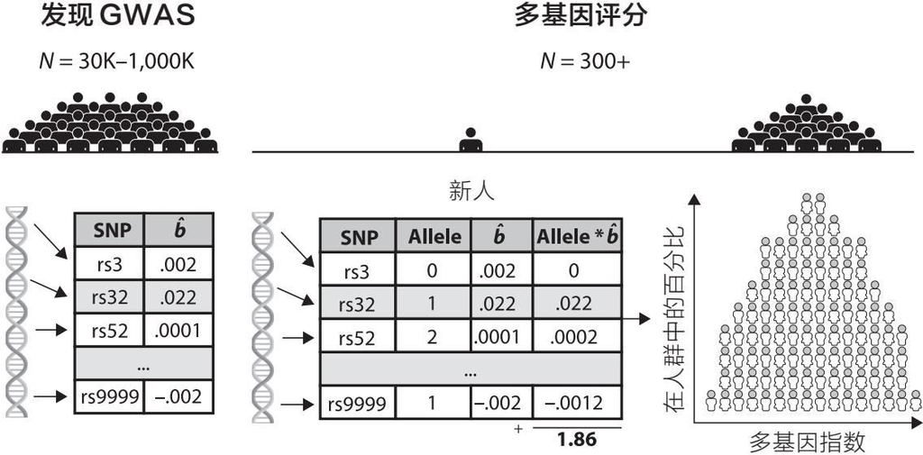

图3.1 创建一个多基因指数。图表转载自Daniel W.Belsky and K.Paige Harden,“Phenotypic Annotation:Using Polygenic Scores to Translate Discoveries from Genome-Wide Association Studies from the Top Down,”Current Directions in Psychological Science 28,no.1 (February 2019):82·90,https://doi.org/10.1177/0963721418807729。个别SNP和表型之间的相关性是在具有大样本量的“发现GWAS”中估计的。许多GWAS的样本量多达数百万人。然后，对一个新人的DNA进行测量。这个人的基因组中的次等位基因（0、1或2）的数量被计算为每个SNP，得出的数字被GWAS对SNP和表型之间相关性的估计加权，产生一个多基因指数。这个多基因指数将呈正态分布：大多数人的多基因指数在平均水平，少数人的分数会非常低或非常高。经SAGE Publications,Inc.许可转载。

研究者在谈论R2值时使用的措辞可能会引起混淆和误导。有两个词特别容易造成麻烦。一个词是“解释”。R2值经常被称为“可解释方差”(variance explained)，但在我看来，“解释”意味着对两件事情的关系有更深的理解。R2值并没有给出任何科学解释。它只是一个数学表达，表明一个变量与另一个变量共同出现的程度。

第二个制造麻烦的词是“预测”。在日常谈话过程中，当我们谈论“预测”天气、选举结果或股市活动的能力时，我们通常暗示这些对未来事件的预测是高度准确的。但研究者对未来事件的预测高度不确定且经常不准确时，他们也经常使用“预测”(predict)和“预测器”(predictor)这些词。在刚才举的身高和体重的例子中，我可以利用人们的身高信息，从统计层面说明人们体重的差异，也就是说，身高是体重的一个“预测器”。但实际上对于具体的人的体重，我仍然只能猜测。如果我知道他的身高，我的最佳猜测会比我没有掌握这个信息时更好。但即便如此，我的最佳猜测仍然会很糟糕，因为身高相同的人在体重上仍然会有很大的差异。

考虑到这些信息，多基因指数和教育结果的R2是多少？在生活在高收入国家的白人样本中，从受教育程度GWAS中创建的多基因指数，通常能捕捉到受教育年限、标准化学业考试成绩或智力测试分数等结果中10%—15%的差异。 ㊟ 【A.G.Allegrini et al.,“Genomic Prediction of Cognitive Traits in Childhood and Adolescence,”Molecular Psychiatry 24,no.6 (June 2019):819–27,https://doi.org/10.1038/s41380-019-0394-4.】

10%—15%听起来是很多还是很少，在很大程度上取决于你的视角。根据我的经验，人们往往轻视10%的R2，认为它微不足道、可以忽略不计。当然，10%的R2值告诉我们，多基因指数不能“算命”，不能准确预测任何个体的未来。 ㊟ 【Robert Plomin,Blueprint:How DNA Makes Us Who We Are (Cambridge,MA:MIT Press,2018).】 在图3.2中，我绘制了多基因指数和生活结果之间的假设关系图，其中前者捕获到了后者的大约10%的差异。如果你在横轴上选取任何一点，即选取多基因指数的任何给定值，然后向上和向下看，你会发现人们的生活结果仍有很大差异。这与我们在现实中看到的情况相吻合：在具有平均水平的教育多基因指数的人当中，有些人拥有博士学位，有些人没有从高中毕业，还有介于这两者之间的各种情况。

虽然多基因指数并非个人生活的完美“算命先生”，但我们也不能将其视为微不足道或可忽略不计。正如心理学家大卫·芬德和丹尼尔·奥泽认为的，我们可以通过将R2值与我们在日常生活中遇到的一些关系强度相比较，来直觉地判断R2值是“大”还是“小”， ㊟ 【David C.Funder and Daniel J.Ozer,“Evaluating E.ect Size in Psychological Research:Sense and Nonsense,”Advances in Methods and Practices in Psychological Science 2,no.2 (June 1,2019):156–68,https://doi.org/10.1177/2515245919847202.】 比如抗组胺药缓解过敏症状的趋势(R2=1%)，男性比女性更重的趋势(R2=7%)，海拔高的地方更冷的趋势(R2=12%)，以及如前所述，高个子的人更重的趋势(R2=19%)。在这个清单中，我们可以添加一个与社会不平等研究特别相关的基准：出生在富裕家庭的孩子从大学毕业的比例更高(R2=11%)。 ㊟ 【Lee et al.,“Gene Discovery and Polygenic Prediction from a Genome-Wide Association Study of Educational Attainment in 1.1 Million Individuals.”】

对收入的比较尤其令人感慨，因为我们太习惯于思考金钱能给学生带来的好处。更富有的父母可以买更多的玩具和书，把孩子送到更好的学校，为孩子报名参加艺术课程和智能机器人课后项目。更富有的父母可以负担得起私人家教和SAT预科课程。来自富裕家庭的学生不必通过勤工俭学来完成大学学业，有更多时间可专注于学习。当然，在富裕家庭长大的孩子并不是注定(destined)会获得大学学位的。你的家庭经济状况并不能完全决定(determine)你成年后的社会阶层。但是，对于了解在美国谁最有可能获得大学教育，谁最不可能获得大学教育，金钱是很重要的。

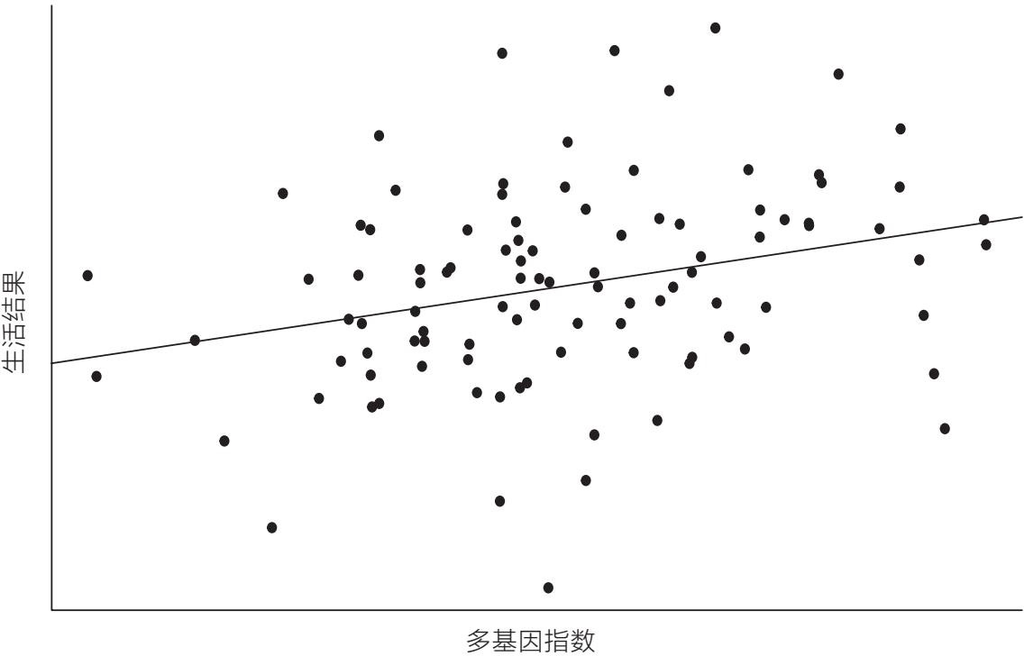

图3.2 假设的多基因指数可以捕捉到生活结果中10%的差异。横轴为多基因指数；纵轴为假设的生活结果，如受教育程度。每个点代表一个人。对于多基因指数的每个值，人们的生活结果都有相当大的差异。

这些基准比较得出的数字可能比你想象的要小。芬德和奥泽在论文中指出了三个原因，以解释为什么R2值通常比我们预期的要低。首先，也是最简单的原因：人类彼此之间非常不同。有很多差异性需要解释。

第二，人类生活的因果关系很复杂，是多种因素相互作用的结果。鉴于潜在相关因素的数量之多，期望任何一个变量（即使是像收入或遗传这样重要的因素）能够解释结果中较大的差异，是不现实的。用芬德和奥泽的话说，“也许所有研究者都应该稍微（或大幅）降低他们的期望”。 ㊟ 【Funder and Ozer,“Evaluating E.ect Size in Psychological Research.”】

最近一项名为“脆弱家庭挑战”(Fragile Families Challenge)的研究强调，研究者需要降低他们对任何变量的期望，无论是环境变量还是遗传变量。“脆弱家庭和儿童福祉研究”是一项正在进行的研究，研究对象是4000多个家庭，他们在孩子出生时被征集参加儿童发展研究。此后，这些孩子在1岁、3岁、5岁、9岁和15岁时接受了一系列变量的测量。他们的父母、老师，以及孩子们自己，都接受了调查，调查项目包括“儿童健康和发展、父亲和母亲的关系、父亲在养育中发挥的作用、婚姻态度、与大家族的关系、环境因素和政府项目、健康和健康行为、人口统计学特征、教育和就业及收入、父母的监督和亲子关系、父母对孩子施加的纪律、兄弟姐妹之间的关系、生活常规、学校、青少年犯罪、任务完成和行为，以及健康和安全”。 ㊟ 【Matthew J.Salganik et al.,“Measuring the Predictability of Life Outcomes with a Scienti.c Mass Collaboration,”Proceedings of the National Academy of Sciences 117,no.15 (April 14,2020):8398–8403,https://doi.org/10.1073/pnas.1915006117.】 换句话说，就是研究者能想象得到的关于儿童环境和发展的一切。

就在研究者公布孩子们15岁时的测量数据之前，他们设计了一项挑战任务：让多个科学家团队使用尽可能多的变量和统计方法（只要他们想得到），来预测孩子们15岁时的结果。最终，超过160个科学家团队参与了这项挑战，每个团队都获得了关于一个孩子及其家庭的1.2万多个变量。结果很能令人清醒。最好的模型（它有可能包含自孩子出生以来被测量的成千上万个变量）只能预测学生15岁时成绩差异的20%。在描述这些结果时，“脆弱家庭挑战”的组织者附和了芬德和奥泽的呼吁，即在研究复杂的人类生活时，研究者应当保持谦逊：“如果用我们的预测能力来衡量我们的理解程度，那么研究结果……表明，我们对儿童发展和生命过程的理解实际上是相当贫乏的。” ㊟ 【Salganik et al.】

那么，任何关于遗传与人类生活结果的关联是“强”还是“弱”的讨论，都必须面对这样一个事实：当研究者在研究像儿童学业成绩这样复杂的东西时，即使研究者测量了他们能想象得到的环境的每一个方面，仍然没有一个变量或一组变量的R2值看起来令人印象深刻。

不过，即使是一个小的R2值，也可能是相当有意义的。芬德和奥泽解释为什么R2值往往比我们想象的要小的第三个理由是，当小的影响一次又一次地重复，在一个又一个人身上重复时，这些小的影响就会累积起来。我们习惯于考虑收入的微小但系统性的影响是如何累积的：在教育轨迹的每一点上，富裕的家庭都可以“作弊”，使他们的孩子更有可能获得某种结果，比如考试获得某个分数，或被分到“快班”，或被精英学校录取。这个过程乘以数以百万计的家庭，就形成了不可忽视的教育不平等的社会模式。因此，DNA也可能是儿童生活中的一种系统性力量，在教育轨迹的每一个点上都会有它的影响。而拥有某种遗传变异组合所赋予的优势，会在数百万人中累积，同样会导致不可忽视的教育不平等的模式。从长远来看，那些看起来很小的影响可能是有意义的。

在统计学层面，多基因评分能够同我们已经确信对研究社会不平等很重要的其他变量（如家庭收入）“竞争”，这改变了我对GWAS的价值的看法。知道一个名为rs11584700的SNP与在学校能够多待两天相关，可能并不特别有价值。但如果一个多基因指数对受教育程度的影响大到这种程度——多基因得分最高的学生和得分最低的学生之间在受教育程度上的差距跟最富有的学生和最贫穷的学生之间的差距一样大，那么这个多基因指数就是有价值的。正如我们在接下来的篇幅中将会看到的，这一进展为研究的可能性开辟了新的前景，并且势如雪崩地带来了大量新的阐释性问题。

在接下来的章节中，我将逐一处理这些阐释性问题。我将考虑这些多基因关联是否是因果关系（第五章和第六章），基因影响像教育这样复杂的事物的机制是什么（第七章），以及这些结果对我们改变人们教育轨迹的能力有什么影响（第八章）。

不过，在我们深入探讨这些问题之前，读者可能已经注意到，我描述的这些研究都是用那些被认定为白人的样本进行的。这些遗传学研究告诉我们的，是在种族同质化的人群内部的个体差异状况。与此同时，在教育结果或收入方面的一些最大差异，是在不同种族群体之间出现的。正如我在导言中提到的，如果认为我描述的遗传学结论为我们提供了关于群体间差异原因的任何信息，那将是一个严重的错误。但是为什么？在下一章，我们将考虑这个问题。

## 第四章

## 血统与种族

在我给本科生开设的“心理学入门”课程当中，有一堂课是关于记忆的，我要求学生们记住一串单词，其中包括像“梦”“床”和“休息”这样的词。然后我要求他们写下他们记得的单词。无一例外，他们（错误地）记得听到了“睡眠”这个词，但我并未说过“睡眠”这个词。“睡眠”的概念之所以在大脑中被激活，是因为同一语义网络中的其他词语，即与睡眠相关的词语，通过一再重复也被激活了。“睡眠”这个词因此被检索出来，仿佛他们真的听到了这个词，尽管我并未提起它。

当人们听到“床”时，他们会自动听到“睡眠”。当人们听到“基因”或“智力”时（特别是在美国），他们会自动听到“种族”。因此，刚接触这个话题的读者可能会惊讶地发现，没有任何证据表明基因可以解释不同种族群体之间在教育等结果方面的差异。目前，关于各个种族在现代工业化经济体中跟社会不平等相关的复杂人类特征（如持久性、自觉性、创造性和抽象推理等）方面存在遗传差异的故事，都只是故事而已。

不过，在一本关于遗传学的书中很有必要讨论一下种族和种族主义。从遗传科学发展的早期开始，遗传学研究就被纳入种族主义的观念中，从而为种族主义的行动辩护。种族主义者对遗传学的侵吞和滥用一直持续到21世纪。 ㊟ 【Aaron Panofsky and Joan Donovan,“Genetic Ancestry Testing among White Nationalists:From Identity Repair to Citizen Science,”Social Studies of Science 49,no.5 (October 1,2019):653–81,https://doi.org/10.1177/0306312719861434;Jedidiah Carlson and Kelley Harris,“Quantifying and Contextualizing the Impact of BioRxiv Preprints through Automated Social Media Audience Segmentation,”PLOS Biology 18,no.9 (September 22,2020):e3000860,https://doi.org/10.1371/journal.pbio.3000860.】 如果我们避免提及种族，就会留下一个真空，而这个真空会被错误填满，会被解释为对科学种族主义的默许。同时，关于遗传学与阶级结构和资源再分配之关系的讨论，已经被几十年间形成且植根的种族“科学”所毒害，所以用心良好的人们常常觉得，他们必须直截了当地拒绝接受关于遗传学如何影响社会和经济结果的论点及信息，以维护他们的反种族主义立场。因此，关键是要把“遗传对个人的社会经济成就有影响”这样一个经验现实，与关于人类群体间差异的种族主义言论加以分别。

在本章中，我会澄清为什么今天的科学种族主义的遗传学理念在经验上是错误的，在道德上是盲目的。我将首先解释遗传学家所说的血统(ancestry)的具体定义，以及将血统的概念与种族相联系为什么是错误的。然后我将描述，遗传学研究是如何由以白人为主的科学家使用以白人为主的样本完成的，这种情况为种族群体之间的错误比较创造了条件，并有可能加剧种族群体之间的不平等。我还将解释为什么这种想法是错误的——对人群中个体差异的遗传原因的研究，能让我们了解群体间差异的深层源头。这种统计上的谬误通常受到白人至上的种族主义思想的支持。最后，我将展望即将投入研究的海量的多民族基因组数据，并解释为何我们无需担心任何统计结果会危害我们的立场——反种族主义和追求种族平等。

#### 我们都是世界上每个人的后代

我的祖父母是五旬节派基督徒，他们背诵了基督教《圣经》的大部分内容，并鼓励他们的儿孙也这样做。我一直觉得《圣经》中最难背诵的部分是族谱：约兰生乌西亚，约西亚生耶哥尼雅。我小的时候经常想问，这些长长的人名清单的意义何在？

我现在发觉，《圣经》族谱的作者和使用Ancestry或FamilyTree或MyHeritage等服务的21世纪客户，受到了同一种冲动的驱使。这些服务将基因测试与档案记录相结合，构建人们的族谱。也就是这种冲动，促使摩门教会记录死者姓名，并将其储存在犹他州一个可以抵御核弹攻击的储存库内。 ㊟ 【Alex Shoumato.,“The Mountain of Names,”The New Yorker,May 6,1985,51..,https://www.newyorker.com/magazine/1985/05/13/the-mountain-of-names.】 知道谁生了谁，就可以掌握身份信息，并将身份合法化。族谱可以促进团结和归属感：“我们是一家人。”

当你想到家庭时，你会想到谁？我想到的是我的孩子和他们的父亲、我的兄弟和母亲、父亲和继母、同父异母的兄弟和继姐妹、我兄弟的妻子和他们将来可能有的孩子、我父亲的三个兄弟姐妹和我在他那边的四个堂兄弟姐妹及其子女、我母亲的三个兄弟姐妹和我在她那边的四个表兄弟姐妹及其子女。我与这些人的情感纽带和遗传关系各不相同，从强有力到不存在。但他们都是我的家人。

随着我们把时间往前追溯，我们的家庭成员名单很快就会变得庞大，因为我们的祖先人数每一代都会增加一倍，如两个父母、四个祖父母、八个曾祖父母，等等。往前追溯三十三代，或大约1000年，得出233=85.89934592亿。

那时地球上甚至没有80亿人同时活着，但有些人是我们多重的祖先。例如，我的叔叔肖恩和婶婶克里斯汀属于“亲上加亲”，因为他们有两个祖辈是兄弟。因此，我的堂兄斯特林并没有24=16个高祖父母，而只有14个，其中一对高祖父母在他的族谱中出现了两次。就这样，我们的血统、我们的族谱树形图中的树冠，开始坍塌了。

人类有时会近亲繁殖，这只是使人类交配变得复杂的众多过程之一。人类在历史上或多或少是保持原地不动的，在离他们父母生儿育女的地方不远的地方求偶生子。在整个人类历史上，迁徙，尤其是长距离的迁徙很少。即使在今天，有了喷气式飞机和州际公路，典型的美国人生活的地方离他/她母亲的住处只有29公里远。 ㊟ 【Quoctrung Bui and Claire Cain Miller,“The Typical American Lives Only 18 Miles From Mom,”The New York Times,December 23,2015,https://www.nytimes.com/interactive/2015/12/24/upshot/24up-family.html.】 人们通常在地理上临近的邻居当中，与拥有相同语言、文化且处于相同社会阶层的人交配。

因为性很复杂，所以需要运用一点复杂的数学手段来估计当前所有人类最近的共同祖先（即出现在今天活着的每个人的族谱上的人）生活在多久以前。答案是，并没有那么久远：在过去几千年内。 ㊟ 【Douglas L.T.Rohde,Steve Olson,and Joseph T.Chang,“Modelling the Recent Common Ancestry of All Living Humans,”Nature 431,no.7008 (September 30,2004):562–66,https://doi.org/10.1038/nature02842;Graham Coop,“Our Vast,Shared Family Tree.,”gcbias (blog),November 20,2017,https://gcbias.org/2017/11/20/our-vast-shared-family-tree/.】 一个保守的估计是公元前1500年左右，那时赫梯人正在学习如何锻造铁制武器。但也可能晚至公元50年左右，也就是尼禄在罗马燃起大火时弹琴的时候。再往前追溯，在公元前5000年到前2000年之间的某个时候，苏美尔人正在发明一种字母，埃及的第一个王朝正在建立。你会发现一个更显著的问题：当时活着的每个人如果留下后代，那么他们都是今天活着的每个人的共同祖先。而如果我们把自己的族谱追溯到足够古早的时代，我们的族谱会变成同一部族谱。

这看上去似乎不可能，因为我们的大多数近期祖先都生活和死亡在同一个地方，与地球上其他大部分地区都相隔万水千山。为了理解这一发现，我们需要了解，当我们在谈论你一千年前的祖先的数量时，我们在谈论多少人。即使是罕见的事件，如长途迁徙，或语言、文化和阶级不同的人们之间的交配，也必然会在每部族谱中偶尔发生。

而这些罕见的事件，将你与全球其他地区联系在一起。归根结底，你的家庭就是我的家庭，我的家庭就是你的家庭。正如群体遗传学家格雷厄姆·库普总结的，“你的族谱是巨大而极其混乱的；没有人纯粹是单一人群的后代”。我们都是人类共同家庭的一部分。“我们都是世界上每个人的后代。” ㊟ 【Coop.】

#### 族谱祖先与遗传祖先

让我们把事情再复杂化一点。我刚才描述的是你的族谱祖先。但你的族谱祖先不一定是你的遗传祖先，特别是当我们追溯到很多代以前时。撇去性染色体（X或Y）不谈，你从你父亲那里继承了22条染色体。在制造后来成为你的精子细胞时，你父亲从他的母亲和父亲那里得到的染色体交换了大块的遗传物质，以产生一个新的DNA序列，也就是独一无二的你。平均而言，每当一个基因组被传递给下一代时，就会发生33次这样的重组事件。因此，你继承的22条染色体可以分解成22+33=55个不同的块，每一块都可以追溯到你的祖父母中的一个。

当然，同样的过程也发生在再上一代，所以你也可以把你继承的染色体分解成22+33×2=88块，每一块都可以追溯到你四个父系曾祖之一。在你家族历史的早期，块的数量(88)远远大于族谱上的祖先数量(4)，所以你几乎肯定从这些人那里继承了DNA。

我们没有从绝大多数遥远的族谱祖先那里继承任何DNA，这一事实可以帮助我们理解下面两个事实，否则这两个事实可能看起来很矛盾。首先，追溯到几千年前，每个人的族谱都是相同的，无论他们生活在世界的哪一地区；我们都是世界上每一个人的后代。其次，生活在世界不同地区的人在基因上是不同的，这些遗传差异可能非常古老，比几千年还要古老许多。

你的一位族谱祖先可能是占领军，他对你的另一位族谱祖先的强奸，将你的族谱与现在生活在地球另一端的人的族谱联系起来。但有可能的是，那个强奸犯的DNA没有一个仍然潜伏在你的基因组中（同样，Y染色体在这里是一个例外）。这是因为我们任何一个上古的族谱祖先同时也是遗传祖先的概率很小。族谱祖先经常从你的DNA中消失，而你与远方民族的遗传联系也随之消失。

你只继承了你的大量族谱祖先当中一小部分人的DNA。而你的大多数祖先都是在地理上相互接近的情况下生活、繁殖和死亡的。大多数的交配机会不仅受限于地理亲近性，还受限于关于谁可以与谁发生性关系的复杂文化规则。这一过程的净结果是，人类的遗传变异存在着结构(structure)。也就是说，任何一个人的基因构成跟其他任何人的基因构成的相似性和差异性，都有一定的模式。这些模式——这种结构——反映了地理和文化的影响。

#### 血统与种族

人类之间遗传相似性和差异性的最重要模式，反映了最显著的地理障碍和边界，如海洋、沙漠和大陆分水岭。与遗传祖先居住在欧洲的人相比，遗传祖先居住在东亚的人彼此之间的遗传相似性更高。因此，遗传相似性和差异性的统计学模式可以通过这样的手段来总结：根据人们的遗传相似性对其分组，然后给这些分组贴上大陆地理的标签（非洲、亚洲与欧洲）。这种操作是很合理的。“非洲血统”这个短语作为一种科学的速记方法，被用来描述一群在遗传上相似的人，因为他们有许多共同的遗传祖先，而这些遗传祖先生活在非洲大陆。

但是，随着科学家学会了更好地分析人类种群的遗传相似性和差异性模式，并开始为具有共同遗传祖先的人群贴上地理标签，其他人开始发出警告。遗传学家是否在重新创造种族，将其视为生物现实，而不是社会建构？这种可能性令人震惊，因为种族的生物学概念长期以来一直被用来为压迫辩护。多萝西·罗伯茨在《致命的发明：科学、政治和大企业如何在21世纪重新创造种族》一书中指出，“使种族成为一个生物学概念”一直“具有重要的意识形态功能”。“在一个声称平等乃其最珍视的理想的社会中，将种族视为生物学概念，构成了对奴隶制唯一合适的‘道德辩护’。” ㊟ 【Dorothy Roberts,Fatal Invention:How Science,Politics,and Big Business Re-Create Race in the Twenty-First Century (New York and London:The New Press,2011).】 罗伯茨和她的三位同行认为，种族的生物学概念“在其最好的情况下也仍然值得商榷，在其较坏的情况下则是有害的”。他们继续呼吁科学家使用“血统”(ancestry)和“种群”(population)等术语，而不是“种族”。 ㊟ 【Michael Yudell et al.,“Taking Race out of Human Genetics,”Science 351,no.6273 (February 5,2016):564–65,http://www.ask-force.org/web/Golden-Rice/Yudell-Taking-Race-out-of-human-genetics-2016.pdf.】

血统和种族之间的这种区别有时被认为是一种诡辩，它使科学家能够在谈论种族之间的生物差异时避免使用“种族”一词。例如，在一次播客采访中，《钟形曲线》的作者查尔斯·默里说：“现在遗传学家喜欢用‘种群’这个词来代替‘种族’，我不怪他们。” ㊟ 【Sam Harris,Making Sense Podcast #73,“Forbidden Knowledge,”April 22,2017,https://samharris.org/podcasts/forbidden-knowledge/.】 像这样的评论把种族和遗传血统混为一谈，使“种族不平等的结果肯定是由于先天的生物学差异”的思想得以延续。因此，关键是要理解，为什么把种族和遗传血统混为一谈是错误的。

在1995年的电影《独领风骚》中，主角雪儿·霍洛维茨把她的一个竞争对手称为“彻头彻尾的莫奈”：“这就像一幅画，看到了吗？远看还行，近看就是一塌糊涂。”对人类种群的遗传结构的分析，就是这样一幅彻头彻尾的莫奈画作。镜头拉远之后，图案(pattern)看起来足够清晰，超群(super-population)与地球上的主要大洲相对应。

将镜头拉近，你仍然可以看到模式，但它们模糊了起来。一项关于欧洲的“基因反映地理”的研究确实发现，祖辈都居住在现今的法国的人，比祖辈都居住在现今的瑞典的人在基因上更相似。但是一些意大利人在基因上与其他意大利人差距较大，而与祖辈都是瑞士人的人重合。样本中没有犹太人，也没有祖辈不都来自同一地点的人。

把镜头拉近到一个人，我们从远处看到的清晰图景就会烟消云散。凡是有边界的地方，就有其历史跨越这些边界的人。特别是当人们的家族史受到了殖民主义、奴役、占领、移民或战争的塑造，是由“以前分离的民族被迫聚集在一起”这种现象塑造的时候，我们就很难将他们归类为从远处看来很分明的类别。

不过，正如我们可能将莫奈画作的一部分称为“天空”一样，我们可以将人类的一部分称为“欧洲血统”的人。或者更狭义地说，“北欧血统”。甚至更狭义的话，可以说“英国白人血统”。

如果人类的遗传祖先图是“彻头彻尾的莫奈画作”，那么我们的种族区分更像是蒙德里安的画作：由清晰的边界分开的对比强烈的原色。种族类别是不连续的、相互排斥的：美国人口普查始于1790年，直到2000年才允许人们选择一个以上的种族来定义。而这些类别本质上是有等级的，因为种族分类的过程是为了限制谁能获得权力、财富和物理空间。奥黛丽·斯梅德利和布莱恩·斯梅德利在总结人类学和历史学对于种族的观点时写道：“种族将人及其社会地位、社会行为、社会等级本质化(essentialize)和刻板印象化。” ㊟ 【Audrey Smedley and Brian D.Smedley,“Race as Biology Is Fiction,Racism as a Social Problem Is Real:Anthropological and Historical Perspectives on the Social Construction of Race,”American Psychologist 60,no.1,special issue:Genes,Race,and Psychology in the Genome Era (January 2005):16–26,https://doi.org/10.1037/0003-066X.60.1.16.】

不过我要明确一点，我并不是说种族和血统是完全独立的。不同的种族群体在遗传血统上当然不同，而这种对应关系是由种族分类的社会史和法律史塑造的。例如，在美国，强制实行种族隔离的法律（例如，“仅限白人”的学校、饮水机、火车车厢、游泳池和其他空间）需要明确界定谁是白人，谁不是。20世纪初，美国南方的几个州通过了“一滴血”种族分类法：任何数量的非白人血统，都足以否定某人在美国种族等级制度中的地位。弗吉尼亚州1924年的《种族完整性法案》是这样规定的：如果一个人“没有任何高加索人种以外的血统”，他就是白人。“一滴血”规则是“降格继嗣”(hypodescent)规则的极端版本。在“降格继嗣”规则中，混血儿被算作父母双方中社会地位较低一方的种族。

由于种族分类“降格继嗣”规则的社会史和法律史，目前在美国被认定为白人的人极不可能有任何数量的非欧洲的遗传血统。一项研究估计，只有0.3%自认为白人的人有任何数量的非洲血统。同时，非洲人被强行带到美国并被奴役，他们的后代被归类为“黑人”，因此，几乎所有（根据一项研究，99.7%）被社会归类为黑人的人，都至少有一些“非洲”遗传血统。 ㊟ 【Yambazi Banda et al.,“Characterizing Race/Ethnicity and Genetic Ancestry for 100,000 Subjects in the Genetic Epidemiology Research on Adult Health and Aging (GERA) Cohort,”Genetics 200,no.4 (August 1,2015):1285–95,https://doi.org/10.1534/genetics.115.178616.】

尽管在“只有欧洲遗传血统”与“被归类为白人”之间存在着接近1:1的对应关系，或者说在“具有一些非洲遗传血统”与“被归类为黑人”之间存在着接近1:1的对应关系，但将种族概念视为血统的同义词，仍然是一个错误。原因有四：

第一，当我们把人划分为种族时，我们突出了人与人之间的某些区别，而忽略了其他区别。这些种族区别是由文化和历史决定的。如果你回顾一下20世纪早期信奉优生学的思想家的作品，他们痴迷的“种族”问题可能会让你觉得很怪诞。阅读普林斯顿大学心理学教授、智力测试的早期倡导者卡尔·布里格姆关于“种族问题”的文章，我们会发现他试图弄清楚来自每个欧洲国家的移民有多少北欧、阿尔卑斯和地中海“血统”。 ㊟ 【Carl Campbell Brigham,A Study of American Intelligence (Princeton,NJ:Princeton University Press,1922).】 一波又一波的欧洲移民，如意大利人、爱尔兰人、犹太人，起初并不被视为美国“白人”统治阶级的一部分。 ㊟ 【Noel Ignatiev,How the Irish Became White (New York:Routledge,1995).】 对种族的界定不可避免地带有社会层面的偶然性，因为种族（与血统不同）是一个固有的等级概念，用于安排(structure)谁可以获得空间和社会权力。

第二，人们在社会层面是否被归类为不同的种族，并不直接对应他们的遗传差异程度。特别是非洲血统的人口，其遗传多样性非常突出，有些非洲人群之间的遗传差异比欧洲人和东亚人之间的差异更大。但每一个非洲裔美国人都被划入同一个“黑人”类别。同样，在遗传血统方面，南亚裔与东亚裔是有区别的，以至于南亚人通常被算作一个单独的大陆超群(super population)。 ㊟ 【The 1000 Genomes Project Consortium,“A Global Reference for Human Genetic Variation,”Nature 526,no.7571 (October 2015):68–74,https://doi.org/10.1038/nature15393.】 但美国人口普查局将亚裔的种族类别定义为“起源于远东、东南亚或印度次大陆的任何原初民族的人”。 ㊟ 【United States Census Bureau,“Race:About This Topic,”accessed November 7,2019,https://www.census.gov/topics/population/race/about.html.】

第三，在任何一个具有自我认同的种族群体中，人们可能有一系列迥异的大陆祖先背景，所以如果我们只掌握了种族信息，几乎不可能有把握地确定一个人的血统。正如我们所看到的，自我认同的美国黑人几乎都有部分非洲血统（这本身就是一个非常异质的超范畴），但与此同时，90%以上的美国黑人也有部分欧洲血统。 ㊟ 【Banda et al.,“Characterizing Race/Ethnicity and Genetic Ancestry for 100,000 Subjects in the Genetic Epidemiology Research on Adult Health and Aging (GERA) Cohort.”】 虽然我们可以相当有把握地认为，在美国被认定为白人的人有欧洲遗传血统，但反过来就不对了，因为有一定量欧洲血统的人几乎可以被认定为任何其他种族类别。

第四，血统可以被非常精细地量化，而这些精细的区别不可能用我们熟悉的种族术语来描述。正如我前面提到的，“一滴血”的社会规则保证了，被认定为白人的美国人不太可能有任何非欧洲的遗传血统，所以在这种情况下，自我报告的(self-reported)种族和遗传血统似乎趋同。但是，即使在完全是欧洲血统的人群中，仍然有反映更精细的地理渐变的遗传结构，以及所有潜在的语言、文化和阶级差异，这些差异使交配变得非随机。

为了捕捉这种遗传结构（它可能是“隐秘的”或隐藏的），遗传学家通常使用一种叫作“主成分分析”(PCA)的方法。PCA分析人与人之间的遗传相似性（这反映了他们有共同的祖先）的模式，并产生一组有关血统信息的主成分，即“PC”。 ㊟ 【Alkes L.Price et al.,“Principal Components Analysis Corrects for Stratification in Genome-Wide Association Studies,”Nature Genetics 38,no.8 (August 2006):904–9,https://doi.org/10.1038/ng1847.】 这些变量中的每一个都是连续的（意味着人们可以是高的，矮的，或介于两者之间的任何位置），而不是非黑即白的。研究者在研究中考虑了40个或更多的血统信息PC，这并不罕见，即使他们只关注一个在纸面上看起来已经相当同质的群体（例如，所有被认定为“英国白人”的人）。 ㊟ 【Clare Bycroft et al.,“The UK Biobank Resource with Deep Phenotyping and Genomic Data,”Nature 562,no.7726 (October 2018):203–9,https://doi.org/10.1038/s41586-018-0579-z.】 这种方法精细地描述了一群人的特征，否则这些人都会被归为单一的种族类别，而每一个血统信息PC都不可能用种族术语来解释。

把所有这些情况放在一起，罗伯茨和她的同行这样总结了种族和血统之间的区别：“血统是一个基于过程(process)的概念，是关于一个人在其族谱历史中与其他人的关系的声明；因此，它是对一个人的基因组遗产的非常个人化的理解。而种族是一个基于模式(pattern)的概念，它使科学家和普通人都得出了关于人类等级制组织的结论，该组织将一个人与一个更大的、预设的、有明确地理范围或社会构建的群体联系起来。”（强调是我加的） ㊟ 【Yudell et al.,“Taking Race out of Human Genetics.”】

#### 为什么血统对GWAS很重要？

历史上的科学种族主义者会指出被划归不同种族的人的头骨差异。现代的科学种族主义者更倾向于谈论遗传血统的模式，以说明先天的种族差异。但是，正如我在本章迄今为止描述的，仔细研究一下遗传血统的科学，就会发现，“种族在科学上是站不住脚的”。 ㊟ 【Dalton Conley and Jason Fletcher,“What Both the Left and Right Get Wrong About Race,”Nautilus,June 1,2017,http://nautil.us/issue/48/chaos/what-both-the-left-and-right-get-wrong-about-race.】 遗传数据并没有“证明”种族的生物学现实。相反，很有讽刺意味的是，了解社会定义的种族群体在其遗传血统方面的差异，有助于我们理解为什么现代“种族科学”实际上是伪科学。有些人（往往）心术不正地企图利用全基因组关联分析(GWAS)发现的人间群内(within)的个体差异，得出关于人群差异来源的结论。在下一节中，我将解释为什么不同人群之间的遗传差异会让上述企图必然失败。

人群间差异的第一个方面是，遗传变异的呈现及其常见程度不同。在某一人群中罕见的遗传变异，在另一个人群中可能很常见。 ㊟ 【The 1000 Genomes Project Consortium,“A Global Reference for Human Genetic Variation.”】 大约四分之三的遗传变异只在一个大陆群体中发现，甚至只在一个次大陆群体中发现，而非洲血统的人群显示出最大的遗传多样性。因此，在一个人群中对表型最重要的遗传变异，在另一人群中不一定是最重要的：例如，CFTR基因的一个特定突变在欧洲血统的人群中造成超过70%的囊性纤维化病例，但在非洲血统的人群中只造成了不到30%的病例。 ㊟ 【Cheryl Stewart and Michael S.Pepper,“Cystic Fibrosis in the African Diaspora,”Annals of the American Thoracic Society 14,no.1 (January 2017):1–7,https://doi.org/10.1513/AnnalsATS.201606-481FR;Giorgio Sirugo,Scott M.Williams,and Sarah A.Tishko.,“The Missing Diversity in Human Genetic Studies,”Cell 177,no.1 (March 21,2019):26–31,https://doi.org/10.1016/j.cell.2019.02.048.】 因此，关注世界上更多遗传多样性的研究具有非凡的潜力，可以发现新的遗传变异，而只关注欧洲血统人群的研究永远不会发现这些变异。例如，对生活在埃塞俄比亚、坦桑尼亚和博茨瓦纳的非洲人的研究发现了影响皮肤色素的新的遗传变异。皮肤色素在整个非洲大陆的差异很大，有浅色皮肤的桑人(San)，也有东非的皮肤很深的尼罗—撒哈拉人。 ㊟ 【Nicholas G.Crawford et al.,“Loci Associated with Skin Pigmentation Identi.ed in African Populations,”Science 358,no.6365 (November 17,2017),https://doi.org/10.1126/science.aan8433;Sirugo,Williams,and Tishkoff,“The Missing Diversity in Human Genetic Studies.”】

人群间差异的第二个方面是，在基因组中看到的连锁不平衡(LD)的模式不同，如哪些遗传变异与哪些其他变异相关联。同样，非洲血统的人群在这里特别值得注意，因为他们的LD比非非洲血统的人群低，而且LD在不同的非洲人群中是异质的。 ㊟ 【Michael C.Campbell and Sarah A.Tishko.,“African Genetic Diversity:Implications for Human Demographic History,Modern Human Origins,and Complex Disease Mapping,”Annual Review of Genomics and Human Genetics 9 (September 22,2008):403–33,https://doi.org/10.1146/annurev.genom.9.081307.164258.】 我们回顾一下，GWAS通常不测量每一个DNA序列，而是测量一小部分SNP。因此，GWAS的结果可能是由“与被测SNP的关联”或“与被测SNP的LD中的任何遗传变异的关联”所驱动的。魔鬼就在这个技术细节中：同一个遗传变异可能与不同人群的结果相关，但仅在一个人群中进行的GWAS的结果仍可能无法移植到别的人群，因为实际测量的SNP在一个人群中“标记”的因果变异(causal variant)与另一个人群的不同。

那么，最重要的一点是，我们不能，也不应该期望GWAS的结果可以在遗传血统或社会定义的种族之间“移植”。你在一个人群中发现的东西，不能期望它会适用于另一个人群；如果你研究一个不同的人群，你可能会发现不同的基因。这种期望在数据中得到了明确的证实。纵观从高密度脂蛋白胆固醇到精神分裂症的各种表型，基于欧洲血统人群分析的多基因指数，与在其他人群（特别是非洲血统人群）中测量到的表型的关系并不紧密。 ㊟ 【L.Duncan et al.,“Analysis of Polygenic Risk Score Usage and Performance in Diverse Human Populations,”Nature Communications 10 (July 25,2019):3328,https://doi.org/10.1038/s41467-019-11112-0.】 当研究者在英国、美国威斯康星州或新西兰的被识别为白人、欧洲血统的样本中使用受教育程度GWAS来构建一个多基因指数时，那么这个分数就“奏效”了：它捕获了这些样本中受教育程度的10%以上的差异。但是，当研究者在非裔美国人（这些人都被认为至少有部分非洲血统）样本中测试这个多基因指数时，它与受教育程度的联系就不那么紧密了。 ㊟ 【James J.Lee et al.,“Gene Discovery and Polygenic Prediction from a Genome-Wide Association Study of Educational Attainment in 1.1 Million Individuals,”Nature Genetics 50,no.8 (August 2018):1112–21,https://doi.org/10.1038/s41588-018-0147-3.】 正如我们在囊肿性纤维化或肤色等在遗传上比较简单的表型研究中看到的，未来对非洲和非洲裔人群的受教育程度或其他社会和行为表型的遗传学研究，可能会发现与欧洲人群不同的相关基因。

#### GWAS研究的欧洲中心主义偏见

不过，就目前而言，几乎所有的GWAS研究都集中在遗传血统完全为欧洲的人身上。截至2019年，欧洲血统的人只占全球人口的16%，却占GWAS参与者的近80%。尽管基因型分型(genotyping)的成本在下降，但上述情况并没有改善。在过去的五年里，尽管基因型分型的总人数继续爆炸性增长，但专注于欧洲血统者的遗传学研究的比例一直保持稳定。 ㊟ 【Alicia R.Martin et al.,“Clinical Use of Current Polygenic Risk Scores May Exacerbate Health Disparities,”Nature Genetics 51,no.4 (April 2019):584–91,https://doi.org/10.1038/s41588-019-0379-x;Duncan et al.,“Analysis of Polygenic Risk Score Usage and Performance in Diverse Human Populations.”】

由于在一个血统群体中进行的遗传学研究的结果不可能移植到另一个血统群体的人身上，目前遗传学研究的欧洲中心主义有可能加剧现有的健康差距。 ㊟ 【Martin et al.,“Clinical Use of Current Polygenic Risk Scores May Exacerbate Health Disparities.”】 医学遗传学方面的工作正在开发多基因风险评分，以预测未来癌症、肥胖症、心脏病和糖尿病的发病情况。这些工作的目标是更早地发现高风险人群，并使他们更快地得到有效治疗。不过，这些慢性疾病对美国的有色人种造成了不成比例的影响。因此，多基因指数的使用有可能进一步扩大不同人群间的健康差距，因为它只改善了那些完全是欧洲血统的人的健康。

解决这个问题的唯一办法是，优先投资于对全球其他人群的遗传学研究。但是，遗传学研究不仅仅是不成比例地研究白种人，它也是不成比例地由白种人进行的。因此，从非欧血统的人群中收集和分析基因数据，处于进退两难的困境。如果不对整个全球人群进行遗传学研究，就有可能使遗传学知识只对原本就处于优势的人有益。但也有一些合理的、根深蒂固的担忧，即DNA会成为白人为了白人的利益从边缘人群中提取的又一宝贵资源，同时使参与者容易受到更多的监视、歧视和其他伤害。这样看来，遗传学研究的欧洲中心主义是一个很好的例子，说明不同的种族主义体系如何相互作用、相互加强，使得任何一个体系都难以孤立地发生改变。

#### 生态谬误和种族主义先验

说到这里，希望大家能明白，为什么任何关于智力、受教育程度、犯罪或任何行为特征的“遗传”种族差异的说法，在科学上都是毫无根据的。因为现有的大规模GWAS是基于欧洲血统人群的，在谈到遗传如何与生活结果的不平等相关时，我们的知识纯粹是关于血统完全是欧洲的、自我认定的种族很可能是白人的人们之间的个体差异。我们之所以不能假设这些基因关联在具有不同遗传血统的人身上会以同样的方式发挥作用，部分是由于有关基因组测量和分析的技术性很强。我们不能用不同血统群体的多基因指数来“比较”其遗传信息。我们不能假设种族相同的人都有相同的遗传祖先。无论我们谈论的是像教育这样复杂的社会表型，还是像身高这样相对没有争议的体质表型，现代分子遗传学研究，像较早的双生子研究一样，都完全不能解释种族不平等的原因。

但是，即使在遗传的种族差异没有任何“证据”的情况下，人们通常会提出一个貌似合理的论点。如果(1)白人群体中教育的个体差异是由遗传差异造成的，并且(2)美国黑人的平均教育水平较低，那么(3)群体间差异也是由遗传造成的，或者至少有一点点是由遗传造成的，这难道不是很直观的道理吗？

从“X导致群体内的个体差异”到“X的平均水平差异导致群体间的平均差异”的跳跃似乎很简单。但从统计学的角度来看，假设一个群体内的相关关系能告诉你群体间差异的原因，是一个只有傻瓜才会做的跳跃。这是一个生态谬误(ecological fallacy)。

为了解释生态谬误，不妨举一个与遗传学无关的例子。但愿这能更清楚地表明，我反对将个体差异与群体间差异联系起来，不仅仅是因为我认为种族群体间差异由“遗传造成”这一结论令人不适。我不是在试图表现得“政治正确”。我提出的是一个统计学观点，它适用于我们试图从一个层次的集合跳到另一个层次的任何时候，而不仅仅是我们在谈论遗传和种族这个争议性话题的时候。

1950年，社会学家W.S.罗宾逊写了一篇关于生态谬误的开创性论文，在其中提出了两组相关关系。 ㊟ 【W.S.Robinson,“Ecological Correlations and the Behavior of Individuals,”American Sociological Review 15,no.3 (June 1950):351–57.】 第一组是在国外出生或在（美国）本土出生与英语文盲之间的个体相关性(individual correlation)。这是一个正数(～.12)，说明在美国以外出生的成年人比在美国出生的成年人更难用英语流利地阅读和书写。接下来，罗宾逊计算了一个州的境外出生居民的百分比和该州文盲率之间的“生态”相关性。它不仅与个体相关性不同，而且实际上转换了方向(～-.5)。对这一明显悖论的解释是，外来移民到了美国之后，往往定居在本土出生的居民更有可能识字的州。也就是说，各州的识字率之所以不同，除了我们在计算个体相关性时测量的变量之外，还有其他很多原因。

现在想象一下，如果我们只拥有罗宾逊掌握的信息的一部分。在这种情况下，我们可以观察到境外出生和英语文盲之间正的个体相关关系，但我们只能在美国的部分州观察到这种个体相关关系。我们可以合理地猜测，其他州的个体相关性也是一样的，但这只是猜测而已。而且，在这种情况下，我们可以观察到美国各州的文盲率不同。但是，由于测量问题，我们没有任何关于各州境外出生居民比例的数据。我们可以看到结果中的群体间差异，但我们无法测量假设的解释变量(explanatory variable)中的群体间差异。

在只掌握了部分信息的情况下，我们可以（不正确地）推测生态相关性(ecological correlation)与个体相关性是相同的，或者至少是同方向的。因此，你看到那些文盲率较高的州，然后得出结论，那些州有更多的出生于境外的居民。你可能会对冲一下。“好吧，我不是说密西西比州的文盲率比加州高的唯一原因是密西西比州的移民多。也许这只是原因的一半。”

但是你完全搞错了，真相是：你观察到的文盲率较高的州，出生于境外的居民实际上较少。

这种以不完整的信息和错误的假设为特征的情况，正是我们在几乎任何性状的人群间差异（无论是身高、智力测试分数，还是受教育程度）中发现的。例如，在一个群体（欧洲血统的人）中，我们可以观察到遗传变异和受教育程度之间的正相关关系。我们可以观察到不同血统群体之间教育结果的差异。但我们不能可靠地测量假设的解释变量——遗传的群体间差异。在一个群体中，我们可以观察到遗传和受教育程度之间的个人层面的相关性。似乎可以合理地认为，这意味着某个血统群体的教育结果更差是因为导致更好教育结果的遗传变异更少。

但现实可能恰恰相反。对教育有正面影响的基因可能在受教育程度较差的血统群体中更常见。个体相关性和生态相关性不仅仅是不同的东西，而且其中一个并不能提供关于另一个的信息。半个多世纪后，罗宾逊在他的论文中扼要地写下的结论仍然很有意义：“唯一合理的假设是，生态相关性几乎肯定不等于其相应的个体相关性。”

那么，对于这种谬论——“科学表明”生活结果中的种族差异是由于种族之间的遗传差异，我们能做什么？的确，社会构建的种族差异与遗传血统有系统性的关系。而且，确实，在欧洲血统的人群内部，人们之间的遗传差异与他们在社会层面重要的生活成果的差异相关。但是，这些信息中的任何一个，都不能提供关于种族间差异来源的任何信息。

在贝叶斯统计中，有一种叫先验(a prior)的东西，它指的是，在考虑任何证据之前，你相信什么以及你对这些信念的不确定性的数学表达。当没有信息可用时，你知道什么，或相信你知道什么？在观察教育等复杂的生活结果中的人群间遗传差异时，我们所处的局面就是这样。我们不妨更进一步。“生活结果中的种族差异是由于种族之间的遗传差异”是一种先验的信念，如果它没有科学证据，那么它的基础是什么？

白人因其基因而享有更好的生活结果这一先验的信念，是一种有害的顽固观念。1960年代，教育心理学家阿瑟·詹森推测，由于遗传的限制，黑人学童的教育进步不会超越某一程度，当然也无法达到白人学童的水平。 ㊟ 【Arthur Jensen,“How Much Can We Boost IQ and Scholastic Achievement?,”Harvard Educational Review 39,no.1 (Winter 1969):1–123,https://doi.org/10.17763/haer.39.1.l3u15956627424k7.】 1990年代，赫恩斯坦和默里轻率地提出了他们的假设，即美国黑人和西班牙裔的平均智商测试分数之所以低于白人，至少有一部分原因是不同种族之间的遗传差异。 ㊟ 【Richard J.Herrnstein and Charles Murray,The Bell Curve:Intelligence and Class Structure in American Life (New York:Free Press,1994).】 今天，“种族现实主义者”和“人类生物多样性”团体张贴了《自然—遗传学》的文章，他们认为这些文章证明了种族之间存在遗传差异，进而导致智力测试分数、冲动行为和经济成功方面的差异。

这些团体坚持认为，他们“只是在问”一个经验性的问题：遗传血统群体之间是否存在能够导致平均生活结果差异的遗传差异？然而，一旦我们认识到他们的假设没有任何正当的科学根据，我们就可以认识到，这个问题建立在关于某些种族群体至高无上的种族主义的先验信念之上。

#### 后基因组世界中的反种族主义和责任

我已经解释了为什么关于基于遗传的种族差异的猜测在今天没有科学依据，但明天呢？毕竟，人类遗传学领域正在以非凡的速度发展。目前，群体遗传学领域的研究者已经在使用GWAS的结果，试图了解人类之间的差异是否可能随着时间的推移而演变。 ㊟ 【John Novembre and Nicholas H.Barton,“Tread Lightly Interpreting Polygenic Tests of Selection,”Genetics 208,no.4 (April 1,2018):1351–55,https://doi.org/10.1534/genetics.118.300786.】 2018年，遗传学家大卫·赖克在《纽约时报》发表评论，敦促人们考虑：“我们应当如何准备应对如下情况，即在未来若干年里，遗传学研究将证明许多性状受到遗传变异的影响，而这些性状在人类不同种群之间存在差异？否认这些差异将是不可能的，事实上，是反科学的、愚蠢的和荒谬的。” ㊟ 【David Reich,“How Genetics Is Changing Our Understanding of 'Race,’”The New York Times,March 23,2018,https://www.nytimes.com/2018/03/23/opinion/sunday/genetics-race.html.】

2020年夏天，当我参加作家萨姆·哈里斯的播客节目时，他也提出了类似的论点。在解释了我为什么认为种族群体的智力存在“遗传”差异的想法没有科学根据（原因我在本章中已经介绍过）之后，哈里斯发动了反击，认为我的立场“会被遗传学和其他科学的未来发展推翻”。他预测：“如果你能列出人类最关心的100件事物，智力将是其中之一……如果我们关心的100件事物的平均值对每一个可以想象的人类群体都是一样的，那将是一个奇迹……因此，在政治上，我的观点是，我们需要能够消化这个事实。” ㊟ 【Sam Harris,“A Conversation with Kathryn Paige Harden,”Making Sense,July 29,2020,https://samharris.org/subscriber-extras/212-july-29-2020/.】

我对赖克和哈里斯的前提持怀疑态度，有多方面的原因。我怀疑群体之间在社会和行为特征（如教育）方面的差异能否在遗传学的分析层次(level of analysis)得到最好的理解（我会在第八章再探讨分析层次的问题）。我不相信科学结论会恰好与白人为了给奴隶制和压迫提供“道德辩护”而编造的故事相一致。我对任何自称洞悉了人类遗传学将向我们揭示什么的人持怀疑态度，因为迄今为止，人类遗传学的发展经常出乎研究者的预料。

不过，虽然我对赖克和哈里斯关于“未来的基因组数据分析会发现什么”的先验立场持怀疑态度，但我确实同意他们的一个观点：如果人们对种族平等的道德承诺依赖于整个人类种群的精确的基因同一性，那么这些承诺的基础就是不稳固的。例如，考虑一下伊布拉姆·肯迪的畅销书《如何成为反种族主义者》。 ㊟ 【Ibram X.Kendi,How to Be an Antiracist (New York:One World,2019).】 在“生物学”一章中，肯迪坚持认为“生物学上的反种族主义者”是这样的人：他“相信各种族在生物学上的意义是相同的，不存在遗传层面的种族差异”（强调是我加的）。

正如我在上文讨论的，种族不是一个有效的生物学范畴。但是，认为被认定为不同种族的人群之间不存在任何遗传差异，是完全不正确的：正如我在本章前面所描述的，种族群体在遗传血统上是不同的，因此在哪些遗传变异存在以及这些变异的常见程度上也是不同的。我们对反种族主义和种族平等的承诺，难道必须建立在“不同种族之间不存在遗传差异”这种摇摇欲坠的基础之上吗？正如我告诉哈里斯的，“将公平、包容或正义的主张……建立在不存在遗传差异的基础上，是一个严重的错误”。这样做会使我们的道德承诺从根本上不稳定，有可能被《自然—遗传学》的下一篇论文推翻。

如果我们要使我们的反种族主义立场在后基因组世界中保持稳定，我认为有必要考虑赖克的问题（尽管这么做可能令人不快），即我们应该如何为将来的科学发现做准备，无论它们是什么。我们不应当害怕去考虑看似最坏的情况：如果明年突然出现了科学证据，表明欧洲血统人群的演化方式使他们在遗传上更容易发展出在学校获得高分的那种认知能力，那该怎么办？我们将如何“消化”这一事实？

赖克在回答自己的问题时，呼吁“把每个人当作一个个体”，“给予［每个人］同等的自由和机会，无论他们之间的差异如何”。虽然我同意应当避免基于群体身份的成见并提供平等机会，但我认为这些还不足以解答他的问题。很多时候，“机会均等”的想法是一种修辞上的回避，是为了避免考虑人类生活结果的严重不平等。现在对每个人都一视同仁，只会复制过去的不平等现象。

而如果我们有兴趣使我们对种族平等的承诺“得到遗传学的证明”(genetics-proof)，我认为我们必须消除“社会有责任解决的不平等”和“生物学差异造成的不平等”之间的错误区分。 ㊟ 【哲学家托马斯·内格尔描述了对种族之间“先天”差异或“生物学”差异的兴趣是如何在人们心中与责任的问题联系起来的。“如果一个人认为社会的责任……只延伸到那些由社会不公正造成的劣势，那么他就会对平均智商的种族差异受遗传影响的程度（如果有的话）赋予政治上的重要性。”Thomas Nagel,Mortal Questions (Cambridge,UK,and New York:Cambridge University Press,1979).】

萨姆·哈里斯在我们的播客谈话快结束时的评论中，提出了“遗传原因是社会责任的边界”这种明显错误的想法。我们谈话的时候，正值乔治·弗洛伊德和布伦娜·泰勒被警察谋杀的夏天，世界各地的城市都爆发了“黑人的命也是命”的抗议活动，而《白人的脆弱性》和《你想谈谈种族》这两本书在《纽约时报》的畅销书排行榜上名列前茅。 ㊟ 【“Paperback Non.ction Books—Best Sellers,”The New York Times,July 26,2020,https://www.nytimes.com/books/best-sellers/2020/07/26/paperback-nonfiction/;Ijeoma Oluo,So You Want to Talk About Race,illustrated ed.(Seal Press,2019);Robin DiAngelo,White Fragility:Why It's So Hard for White People to Talk About Racism,foreword by Michael Eric Dyson (Boston:Beacon Press,2018).】 这些迹象表明，美国正在发生关于警政、住房、医疗保健、教育、财富和政治权力等方面的种族差异的全国性对话。关于这一点，哈里斯问道：

真正的问题是，造成所有这些差异的原因是什么？目前政治上的问题是，当你谈论美国社会中的白人—黑人差异时……在许多方面，唯一可以接受的解释是白人种族主义，或系统性的种族主义、制度性的种族主义，奴隶制和“吉姆·克劳法”的遗留影响……这是非常不可靠的，因为我们会发现一些关于群体间差异的东西。

这些评论提出了一个非此即彼的观点：要么是系统性的种族主义，白人有道德责任来解决这个问题；要么是遗传，它被假定为生物学的一个固定的、决定论的方面，所以不应该让任何人感到自己对其负有责任。正如女权主义哲学家凯特·曼恩在其关于性别歧视的著作中所说的：“这里未说明的前提是‘应该蕴含能够’(ought implies can)原则的一个版本……可能被弱化为‘不能够甚至蕴含懒得管’(can't even implies don't bother)。” ㊟ 【Kate Manne,Down Girl:The Logic of Misogyny (New York:Oxford University Press,2017).】 将遗传而非种族主义定位为种族差异的原因，其未点明的前提是要暗示人们，特别是处于种族等级制顶端的白人，他们不必在道德上感受到压力，要去为改变差异做任何事情，因为种族差异是遗传造成的。

这种思维的关键缺陷并不是它假设种族群体之间存在遗传差异。正如我们看到的，种族并不能代表遗传血统，但种族与遗传血统并非毫无关系。上述思维的关键缺陷也不在于它将遗传差异与生活结果的差异联系起来。正如我将在本书中解释的，有大量的科学证据表明，我们的基因对塑造自我很重要，而且不仅限于我们身体特征的塑造。

上述思维的关键缺陷在于，它认为，遗传造成的人类差异的存在，意味着我们无需承担解决不平等问题的社会责任。正如我在接下来的章节将会描述的，遗传影响的存在（无论它如何在社会定义的群体中分布）并没有对通过社会机制进行社会变革的前景施加一个硬性界限，也不是我们逃避社会责任的“免罪金牌”。

最终，我认为学界即将获得的来自多血统人群的海量基因组数据很可能会显示，与心理特征（比如我们目前的一系列智力测试所测试的认知能力）有关的遗传变异在各人群中的分布占比相当，差异很小（如果有差异的话）。但是，无论人们的遗传差异如何，无论人们的遗传差异如何在社会定义的种族群体中分布，无论这些遗传差异多么强烈地影响人类特征的发展，无论这些特征是生理的还是心理的，我们仍然不能逃避为所有人谋福利的责任，而不能仅仅服务于全球遗传多样性中以欧洲血统为主的那一小群人。这一责任必须在我们的社会政策中得到体现。也就是说，我们的社会政策应该反映这样一个事实：正如演化生物学杜布赞斯基所写的，“遗传多样性是人类最宝贵的资源，而非对单调的同一性这一理想状态的令人遗憾的偏差……不充分实现人类的潜力，是对人力资源的浪费”。 ㊟ 【Theodosius Dobzhansky,“Genetics and Equality:Equality of Opportunity Makes the Genetic Diversity among Men Meaningful,”Science 137,no.3524 (July 13,1962):112–15,https://doi.org/10.1126/science.137.3524.112.】

#### 总结并展望未来

在这里，让我重述一下本章提出的观点：遗传血统是一个基于过程的概念，将人们与他们个人的族谱历史联系起来；而种族是一个基于模式的概念，将人们与社会构建的群体联系起来，以维持等级权力关系。GWAS研究要考察的是单纯具有“欧洲”血统的人在智力、行为和成就上的个体差异。由于美国社会构建“白人”这一群体的方式，这些人都可能被认定为白人。GWAS的这些结果不一定能推广到其他的血统人群，也不能用来在不同的血统人群之间进行比较。没有科学证据表明不同的种族群体或血统人群之间的智力测试分数表现差异是遗传差异造成的。美国黑人因为基因不好而获得更糟糕的社会结果的想法，不是基于科学证据，而是基于许多世纪以来的种族主义思想。种族主义思想以种族化的等级制度来看待人与人之间的差异，而白人处于等级制度的顶端。而且，最关键的是，我们有责任妥善地改造社会，使其惠及所有人，而不仅仅是具有某种遗传特征的人。任何遗传学的发现都不能免除我们的这种社会责任。

当我们讨论遗传和社会不平等之间的关系时，要清楚地记住上述观点可能非常困难。这种困难不是偶然的，而是几十年来种族主义思想的结果，这种思想一直将生物学作为其意识形态工具的一部分，对种族等级制度进行正当化。那么，在接下来的章节中，当我论证为什么我们应当认真对待“作为个体差异之原因的基因”时，读者诸君不妨回过头来看看本章，提醒自己，为什么个体差异和种族差异不是一回事，以及为什么遗传差异的存在并不能免除我们的社会责任。

同时，本章已经开始触及一些需要慢慢解释的重要问题，如遗传原因可能具有社会机制（第七章），以及遗传影响并不对社会变革的可能性施加硬性界限（第八章和第九章）。但在这之前，我们必须解答一个更基本的问题。什么是遗传原因？正如我在上一章所描述的，GWAS将一小部分DNA与某种结果相关联。但是，正如人们常说的，相关不代表因果。我们如何从GWAS的相关结果，推进到理解基因如何在特定的历史文化背景下成为社会不平等的原因之一？要回答这个问题，就要求我们对“原因”这个词有准确的定义。在下一章，我们会集中探讨这个话题。

## 第五章

## 生活机遇的抽彩

每个学过心理学入门课程的学生都知道，“相关不代表因果”。在每道菜中加入更多磨碎海胆的餐厅可能在Yelp上得到更高的评分，但这种相关性并不意味着在每份菜单中都加入海胆，就会让人们更喜欢这家餐厅。同样，全基因组关联分析发现，具有某些遗传变异的欧洲血统的儿童在学校表现更好，但这是否意味着这些遗传变异导致了相应的教育结果？

这个问题比乍看之下更为复杂，因为要回答这个问题，我们必须先解决一个更大的问题：什么是“原因”？正如我将在本章描述的，“原因”这个词从来就没有一个单一的定义。当探讨“遗传是否可以成为原因”时，人们对“原因”一词的定义尤其五花八门。它的定义会根据需要而伸缩，从而使其囊括他们想要接受的因果关系，同时回避其他因素。为了论证遗传确实能导致收入、教育、健康和福利方面的社会不平等，我们需要具体说明什么是原因，什么不是。

#### 一个收养实验

1966年，罗马尼亚立法禁止45岁以下或子女少于5个的女性堕胎和避孕。 ㊟ 【Amy Mackinnon,“What Actually Happens When a Country Bans Abortion,”Foreign Policy (blog),May 16,2019,https://foreignpolicy.com/2019/05/16/what-actually-happens-when-a-country-bans-abortion-romania-alabama/.】 很多女性被迫生下她们不想要也无力养活的孩子，于是纷纷把孩子交给国营孤儿院。超过50万名儿童在国营孤儿院长大，他们是在“灵魂的屠宰场”中长大的“迷失的一代”。 ㊟ 【Vlad Odobescu,“Half a Million Kids Survived Romania's 'Slaughterhouses of Souls.'Now They Want Justice,”The World,GlobalPost,PRX (Public Radio Exchange),December 28,2015,https://www.pri.org/stories/2015-12-28/half-million-kids-survived-romanias-slaughterhouses-souls-now-they-want-justice.】 当罗马尼亚向西方开放之后，参观罗马尼亚孤儿院的人们对他们目睹的情况感到震惊。数以百计的儿童被关在光秃秃的金属围栏婴儿床里，坐在一片诡异的静谧之中。这些孩子缺乏对照顾者的持续依恋，每天都要遭受暴力和羞辱，并且对自己的情感需求和智力需求得到满足不抱任何希望，所以已经退缩到沉默之中。

看到罗马尼亚孤儿在国营孤儿院遭受极端的疏于照料之后，一群美国科学家觉得这是解答一个人类心理学问题的绝佳机会：是否存在一个关键窗口期，在这个窗口期里，足够好的环境对正常的心理发展是绝对必要的？20世纪中期，心理学家哈里·哈洛为了解答这个问题，进行了残酷而不道德的实验，将小猴子与其母亲分离。哈洛的野蛮实验得出了一个令人不安的结论，即年幼的灵长类动物不仅需要食物和哺乳，还需要来自照顾者的身体上的亲近，才能茁壮成长。 ㊟ 【Harry F.Harlow,“Love in Infant Monkeys,”Scienti.c American 200,no.6 (June 1959):68–75.】 在接下来的几十年里，英国精神分析学家约翰·鲍尔比和他的学生、心理学家玛丽·安斯沃思，将哈洛的见解扩展为一种他们称之为“依恋”(attachment)的理论。 ㊟ 【Inge Bretherton,“The Origins of Attachment Theory:John Bowlby and Mary Ainsworth,”Developmental Psychology 28,no.5 (September 1992):759–75,https://doi.org/10.1037/0012-1649.28.5.759.】 年幼的灵长类动物不仅仅需要身体上的亲近，还需要与照料者建立一种温暖的互动关系，才能在认知和情感上成熟。

现在，罗马尼亚有一群被剥夺了依恋关系的儿童。鲍尔比和安斯沃思的理论是正确的吗？如果把儿童从被剥夺依恋关系的环境中解救出来，他们能恢复吗？能否恢复与多早介入有关系吗？

为了解决这个问题，科学家们在罗马尼亚建立了一个寄养制度（罗马尼亚没有这样的制度）。然后他们抽签决定哪些孩子将留在孤儿院，哪些孩子将与寄养家庭一起生活。这是一项为了提出科学问题而设立的生活机遇(life chances)的抽彩。 ㊟ 【Charles H.Zeanah et al.,“Designing Research to Study the Effects of Institutionalization on Brain and Behavioral Development:The Bucharest Early Intervention Project,”Development and Psychopathology 15,no.4 (December 2003):885–907,https://doi.org/10.1017/S0954579403000452.】 哪些孩子在寄养家庭长大，哪些留在孤儿院，纯粹是随机决定的（研究者获得了进行这项实验的批准，并在至少一篇论文中讨论了他们的研究存在的伦理问题。不过，对弱势人群进行实验的伦理可接受性仍有争议 ㊟ 【Charles H.Zeanah,Nathan A.Fox,and Charles A.Nelson,“The Bucharest Early Intervention Project:Case Study in the Ethics of Mental Health Research,”The Journal of Nervous and Mental Disease 200,no.3 (March 2012):243–47,https:// doi.org/10.1097/NMD.0b013e318247d275;Stephen T.Ziliak and Edward R.Teather-Posadas,“The Unprincipled Randomization Principle in Economics and Medicine,”in The Oxford Handbook of Professional Economic Ethics,ed.George F.DeMartino and Deirdre N.McCloskey (New York:Oxford University Press,2016).】 ）。

研究者继续跟踪这两组儿童（在寄养家庭长大的和留在孤儿院的），并以多种方式测试他们，看他们的身体、大脑、情感、思想和生活有什么不同。2007年，该研究的一篇里程碑式的论文发表在《科学》上。 ㊟ 【Charles A.Nelson et al.,“Cognitive Recovery in Socially Deprived Young Children:The Bucharest Early Intervention Project,”Science 318,no.5858 (December 21,2007):1937–40,https://doi.org/10.1126/science.1143921.】 在54个月大时，被随机分配到寄养家庭的儿童的平均智商为81，而被随机安排留在孤儿院的儿童的平均智商为73（智商分数的设计是，人群的平均分数为100分，标准差为15分。根据这些标准，81分的智商低于大约90%的人，而73分的智商低于96%的人）。这种差异是“重大的”，意味着它不可能是偶然发生的。

这项研究的结论很简单和直接：比起在一个光秃秃的金属围栏婴儿床中长大，没有人抱你、和你说话、给你读书或让你出去，在家庭中长大会使你更聪明。时机也很重要。在最年幼时被从孤儿院解救出来的孩子，平均来说智商最高。相比之下，那些在30个月后才被随机送到寄养家庭的孩子，其平均智商与整个儿童期留在孤儿院的孩子没有区别（30个月仍然是非常年幼的。这个月龄的许多孩子还在用尿布）。

你可能认为，我介绍这项研究是为了证明环境的质量，特别是早期环境的质量，会影响儿童早期认知能力的发展。早期环境肯定会影响认知能力，但这不是我要谈的重点。我想把你的注意力引向一个不同的问题：从孤儿院里解救出来并安置在一个寄养家庭里，是否会导致儿童的智商提高？

研究者自己当然是这么认为的。他们在论文中写道：“我们相信，寄养干预所产生的［智商］差异反映了真正的干预效果。”（强调是我加的）他们并不是说寄养与更高智商有关(associated)，也不是说寄养与更高智商相关(correlated)。他们的观点是，与孤儿院的照料相比，寄养导致了智商的提高。

也就是说，他们声称发现了一个因果效应。这在社会科学家当中并没有特别大的争议。我们中的大多数人都会把这样一个适当进行的实验的结果解释为存在因果关系的证据。而我们在这里对“原因”这个词的欣然接受，意味着我们对因果关系有一种具体的定义：原因是指造成了变化的东西。

#### 原因和反事实

1748年，苏格兰哲学家大卫·休谟 ㊟ 【David Hume,An Enquiry concerning Human Understanding,ed.Peter Millican (New York:Oxford University Press,2008;orig.pub.1748).［引文译文借用《人类理智研究》，吕大吉译，商务印书馆，1999年，第68页。］】 对“原因”提出了一个定义，不过实际上是将两个定义合二为一：

我们将“原因”恰当地定义为：原因是一种有另一种对象随之而来的对象，并且在所有类似于第一种对象的地方，都有类似于第二种的对象随之而来。换句话说，如果第一个对象不存在，第二个对象也一定不存在。

休谟定义的前半部分是关于规律性(regularity)的：如果你看到一件事，你是否总是看到某种其他的东西？如果我按下电灯开关，灯就会有规律地、几乎毫无例外地亮起来。从这里开始，我将我们认为是原因的东西（如按动电灯开关）称为X，而将它的结果（灯亮了）称为Y。

在接下来的两个世纪里，对因果关系的规律性描述吸引了哲学家们的注意力，而休谟定义的后半部分（如果第一个对象不存在，第二个对象也一定不存在）则相对被忽视了。到了1970年代，哲学家大卫·刘易斯 ㊟ 【David Lewis,“Causation,”Journal of Philosophy 70,no.17 (October 1973):556–67,https://people.stfx.ca/cbyrne/Byrne/Lewis%20-%20Causation.pdf.】 提出了一个更接近休谟定义后半部分的“原因”的定义。刘易斯将原因描述为“能够产生差异的东西，而它所产生的差异必须是与没有它就会发生的事情的差异”（强调是我加的）。

刘易斯对原因的定义聚焦于“反事实”：X发生了，但如果X没有发生呢？如果被寄养的孩子没有被送去寄养，会怎样？根据“原因”一词的反事实定义，说X导致Y，意味着，如果X没有发生，那么Y发生的概率会不同。据此，说寄养会导致智商提高，意味着说如果一个孩子没有被收养到寄养家庭，那么他的智商有可能会更低。

刘易斯的论文可能被誉为哲学界的新事物，但“原因是差异制造者”的想法已经在多个场合或多或少地独立演变出来了。例如，约翰·斯图亚特·密尔曾写道（1843年）：

如果一个人吃了某道菜，并因此而死亡，也就是说，如果他没有吃这道菜他就不会死，人们就会说吃这道菜是他死亡的原因（强调是我加的）。 ㊟ 【John Stuart Mill,“A System of Logic:Ratiocinative and Inductive,”in Collected Works of John Stuart Mill,vol.7 (Toronto:University of Toronto Press,1974),327,https://oll.libertyfund.org/title/mill-the-collected-works-of-john-stuart-mill-volume-vii-a-system-of-logic-part-i.】

而就在刘易斯发表1973年论文的一年后，统计学家唐纳德·鲁宾 ㊟ 【Donald B.Rubin,“Estimating Causal Effects of Treatments in Randomized and Nonrandomized Studies,”Journal of Educational Psychology 66,no.5 (1974):688–701,https://doi.org/10.1037/h0037350.】 用与之惊人类似的术语定义了因果关系：

直观地说，对于一个特定的单位和一个从t1到t2的时间间隔来说，一种治疗方法(E)与另一种疗法(C)的因果效应是，“如果该单位在t1开始接触E，在t2时间会发生什么”，与“如果该单位在t1开始接触C，在t2时间会发生什么”的差别。如果一小时前我吃了两片阿司匹林，而不是只喝了一杯水，我的头痛现在就会消失（强调是我加的）。

#### 观察原本可能发生的事情

1998年的电影《双面情人》正是以这个问题开始的：“你是否曾想过，原本可能发生什么？”在电影开始不久后的一个场景中，由GOOP丑闻 ㊟ 【格温妮丝·帕特洛于2008年创办的电子商务公司和生活方式品牌“古普”(GOOP)销售一种售价六十六美元的玉蛋。根据公司网站上的广告，将它塞进阴道后，能够“有助于聚集性能量，清理体内的灵气通道，提升女性气质，复苏我们的生命力”。这种玉蛋引发了冷嘲热讽，有人指控帕特洛在兜售健康效果可疑或者根本没有效果的虚假保健品。】 之前的格温妮丝·帕特洛扮演的主角勉强赶上火车，回到家后发现她的男友和另一个女人在床上。在下一个场景中，格温妮丝·帕特洛错过了同一列火车，结果就没发现男友的不忠，并继续在一段令人深感失望的关系中蹒跚前行，用她的话说，这个男人是一个“可悲的，可悲的窝囊废”。电影在两条不同的情节线、两种潜在的结果之间来回跳动：如果格温妮丝赶上或没赶上火车，会发生什么？

一般来说，反事实就是这样：它们是关于一个实际上不存在的世界的条件性陈述。这就是所谓的“因果推断(causal inference)的基本问题”： ㊟ 【Paul W.Holland,“Statistics and Causal Inference,”Journal of the American Statistical Association 81,no.396 (1986):945–60,https://doi.org/10.2307/2289064.】 我们几乎永远没有机会观察一个人身上可能发生的另一种情况。我没有机会看到我的生活的“双面情人”式的替代现实：如果我接受了另一份工作机会呢？如果我接受了另一个人的求婚呢？

我们作为科学家，也没有机会看到我们想要了解的情况的反事实。研究者不能把一个孩子留在孤儿院，同时把他送去寄养，然后比较同一个孩子的另一种生活。人只能活一次。人不可能把同一个蛋糕烤两次。人不可能既经历X，又经历非X。

要解决因果推断的基本问题，通常的方法是比较经历过X的人和经历过非X的人的结果。你从孤儿院地狱里被救出来后的生活告诉我，如果我也被救出来，我的生活可能是什么样子。

这里很明显的困难是，即使你我都被送去寄养，你的生活也会与我的生活不同。你是你，我是我。那么，如何将我们生活中的差异归结为一个你经历过而我不曾经历的事件？

像罗马尼亚孤儿院研究这样的实验，通过研究多个群体并比较其平均结果，而不是任何一个个体的结果，来克服这个困难。在这个案例中，68个孩子被送到寄养家庭，68个孩子留在孤儿院。我们的想法是，对68个人（他们都有一个共同点，被寄养或被孤儿院照料）进行平均，能够平均掉他们各自生活结果的所有“噪声”。剩下的，就是由他们的共同点驱动的“信号”。

但这只有在人们的共同点恰好是研究者感兴趣的东西时才有效。例如，如果研究者选择让所有的男孩留在孤儿院，所有的女孩被寄养，那么就没有办法判断检测到的统计信号是由“寄养”还是由“女性”驱动的。每个大一学生都会在某个时候被告知“相关不代表因果”，部分原因就在这。例如，一个县的冰激凌销售量与谋杀率呈正相关，但吃很多冰激凌并不是多个县的唯一共同点，它们还共同处于温暖的气候中。只有当你能把X从人们之间的其他差异中分离出来时，为了窥视反事实的世界而对多个人群进行比较才会有效。

我们需要将假定的因果变量与其他一切隔离开来，这就是为什么随机性对实验设计至关重要。通常情况下，我们的生活经历是交织在一起的。随机分配（也就是研究者干预宇宙，决定谁经历什么，完全独立于人们其他所有的生活特征）就解开了交织在一起的东西。有些孩子之所以被送去寄养，并不是因为他们应得这样的待遇，也不是因为他们最高、最漂亮、最乖巧或者最需要有爱的家。他们被送去寄养，仅仅是因为他们的名字被随机抽中了。运气闯入了他们的生活，而这种运气（由于它是运气）是与他们生活结果的所有其他原因相隔离的。

罗马尼亚孤儿院研究进行的统计分析，实际上非常简单。被收养的儿童与留在孤儿院的儿童的平均智商是多少，这些平均数之间的差异比预期的要大是否完全出于偶然？两组之间的差异有多大，以及我们是否可能错误地得出结论，认为寄养“有效”地提高了智商，而实际上却没有；或者错误地得出结论，认为寄养没有作用，而实际上它有作用？这些都是科学家要着重考虑的。但这些问题在这里都是无关紧要的。重要的一点是：将参与者随机分配到不同的X值（在本案例中，是寄养家庭与孤儿院）的实验被普遍接受为一种恰当的方法，它允许科学家测试X是否导致Y（在本案例中，是智商的提高），因为群体间比较被视为观察X时发生的情况与非X时发生的情况之间差异的有效方法。 ㊟ 【更具体地说，这种方法允许我们估计平均处理效应（Average Treatment E.ect，缩写为ATE）。但ATE并不是研究者可能感兴趣的唯一数值。例如，他们可能对处理反应(treatment response)的异质性特别感兴趣。进一步的讨论见Angus Deaton and Nancy Cartwright,“Understanding and Misunderstanding Randomized Controlled Trials,”Social Science & Medicine 210,special issue:Randomized Controlled Trials and Evidence-based Policy:A Multidisciplinary Dialogue (August 2018):2–21,https://doi.org/10.1016/j.socscimed.2017.12.005。】

你也许有相关的科研背景，所以这些对你来说，可能是显而易见的。事实上，到目前为止，我解释的内容放在心理学概论课上都不会有什么不妥。如果它看起来理所当然，那是因为反事实或潜在结果的因果关系分析已经被深深地嵌入科学实践中。计算机科学家朱迪亚·珀尔(Judea Pearl)是《因果推断期刊》(Journal of Causal Inference)的创刊编辑，他甚至说反事实推理是“科学思想的基石”。 ㊟ 【Kevin Hartnett,“To Build Truly Intelligent Machines,Teach Them Cause and Effect,”Quanta Magazine,May 15,2018,https://www.quantamagazine.org/to-build-truly-intelligent-machines-teach-them-cause-and-e.ect-20180515/.】 当我们问一项干预措施是否导致儿童在学校的表现更好，或一种药物是否导致症状减轻，或一个广告是否增加了销售额时，我们通常会问：“这些东西对世界造成的平均差异是什么？”

#### 原因不是什么

鉴于对因果关系的反事实分析在医学和社会科学的每个分支中都很普遍，将这种对因果关系的理解应用于遗传原因似乎也很合理。用大卫·刘易斯的话说，遗传原因是一种“产生差异的东西，而它产生的后果必须是与没有它就会发生的后果不同的”。

这一点值得反复强调。称一个基因为原因（事实上，称任何东西为原因），意味着与该原因没有发生的另一种现实进行比较（X与非X）。说一个基因有影响，就是说这个基因产生了差异。 ㊟ 【演化生物学家理查德·道金斯(Richard Dawkins)指出，即使是对于相对简单的、在直觉上是“可遗传的”表型，如眼睛的颜色，也应将遗传原因定义为差异制造者。他写道：“任何可能原因的‘效果’(e.ect)，只有在与至少一个替代原因的比较中才有意义，即使只是隐含的比较。把蓝眼睛说成某个基因G1的‘效果’，严格来说是不完整的。如果我们说这样的话，我们实际上在暗示至少有一个替代的等位基因潜在地存在，姑且称之为G2，以及至少有一个替代的表型P2，比如说，棕色眼睛。”他又举了一个例子，即有两个基因都与皮肤色素有关：“可以肯定的是，A基因的蛋白质产物是黑色色素，是个体成为黑人的必要条件……但我不会把A基因称为黑人的基因，除非人群中的一些变异是由于缺乏A基因……这里有意义的一点是，A和B都有可能被称为黑人的基因，这取决于人群中存在的替代情况（强调是我后加的）。将A基因与黑色色素分子的产生联系起来的因果链很短，而B的因果链很长，很曲折，这一事实是没有意义的。”最后，道金斯指出，自然选择关注的是差异：某些版本的基因变得比其他版本的基因更常见，是因为这些版本造成了身体健康方面的差异。演化是需要比较的。哲学家内德·布洛克(Ned Block)一篇至今仍被广泛引用的文章中的推理的主要缺陷是，他没有认识到这样一个事实：遗传原因，像所有其他原因一样，是差异的制造者，这暗示着与某种替代情况的比较。布洛克写道（强调是我加的）：“遗传决定(Genetic determination)是一个关于什么导致某个特征的问题：脚趾的数量是遗传决定的，因为我们的基因导致我们每只脚有五个脚趾。相比之下，遗传率是什么导致某个特征的差异的问题：脚趾数量的遗传率，是遗传差异导致脚趾数量变化的程度的问题（有些猫每只脚有五个脚趾，有些有六个）。”布洛克的错误是显而易见的。根据原因的定义，导致某一特征的原因，就是导致某一特征的差异的原因。说基因G1导致我们每只脚有五个脚趾，就是暗示存在另一种等位基因和另一种表型，也就是说拥有G1以外的基因会导致你有不同数量的脚趾。事实上，基因是差异的制造者，这一点可以用布洛克的五个脚趾的例子来经验性地说明。决定脚趾数量的两个基因是EVC1和EVC2。这些基因的罕见突变会导致多指畸形（有额外的手指或脚趾），以及短肋、牙齿异常和心脏缺陷，这种综合征被称为“埃利伟氏综合征”。EVC基因编码的蛋白存在于每个细胞周围的小小的毛发状突起上；这种蛋白质帮助细胞相互沟通，使其能够将自己排列成正确的形状。科学界通过研究9个阿米什人(Amish)家庭发现了EVC1和EVC2基因，这些家庭的一些成员天生就有额外的手指和脚趾。该研究中的科学家们关注的正是被布洛克错误地认定为有别于遗传因果关系的问题。科学家们问道：哪些基因与你是否有五个手指和五个脚趾的差异有关？那些继承了两个拷贝的EVC1或EVC2突变基因的人，有额外的脚趾；没有继承的人则每只脚有五个脚趾。Richard Dawkins,The Extended Phenotype:The Long Reach of the Gene,rev.ed.(Oxford and New York:Oxford University Press,1999);Ned Block,“How Heritability Misleads about Race,”The Boston Review 20,no.6 (January 1996):30–35;Victor A.McKusick,“Ellis-van Creveld Syndrome and the Amish,”Nature Genetics 24,no.3 (March 2000):203–4,https://doi.org/10.1038/73389.】

但是，在我们沿着这条思路走下去之前，有必要提前列出这个反事实框架对我们理解因果关系所施加的界限。罗马尼亚孤儿院的研究是一个从随机实验中推断因果关系的相对简单的例子。通过在这项研究的背景下考虑这些界限，我们将能够更清楚地看到“原因”这个词是如何被应用于对遗传原因的审视的。

首先，被分配到寄养家庭导致儿童智商提高的结论，并不意味着研究者洞悉其中的作用机制。例如，寄养对儿童产生影响的一个潜在机制是这样的：亲近那些温暖和富有同情心的照顾者，可以降低儿童的生理反应，从而防止糖皮质激素干扰学习和记忆所需的突触连接(synaptic connection)的发育。另一种可能性是这样的：寄养家庭更有可能给儿童提供有足够碘含量的饮食。还有一种可能性是这样的：儿童大脑是一个“期待着经验”的器官，如果儿童在发展早期没有充分接触到语言，其大脑皮层的突触就不会充分扩散。

这些潜在机制中的每一个，都可以被分解为一组子机制，仿佛一个“如何？”的俄罗斯套娃：这是大脑如何编码关于照顾者接近的信息，这是糖皮质激素如何影响前脑的神经元，这是身体如何代谢碘，等等。要了解寄养对认知发展的影响，需要弄清这些机制。

但是，理解机制是一套单独的科学活动，与确立因果关系的科学活动不同。在普通的科学话语中，即使我们几乎完全不了解某原因发生作用的机制，我们也完全可以认定它是一个“原因”。离开孤儿院会导致儿童智商提高，但为什么会提高？没有人真正知道。

其次，在反事实框架中把某事物确定为原因，并不意味着这个原因决定了结果，而只是说，这个原因提高了结果发生的概率。在通常的科学实践中，以及在日常生活中，我们一直在提出非决定性的原因。而这些说法超出了“事物仅仅具有相关性”的主张：非决定性的原因是基于实验结果的，在这些实验中，随机分配到的经历提高了一个人经历特定结果的概率，但并不必然会产生这个结果。心理治疗与抗抑郁药相结合，提高了患抑郁症的青少年停止考虑自杀的概率（但不是对所有人都有效）。 ㊟ 【John March et al.,“Fluoxetine,Cognitive-Behavioral Therapy,and Their Combination for Adolescents with Depression:Treatment for Adolescents With Depression Study (TADS) Randomized Controlled Trial,”JAMA 292,no.7 (August 1,2004):807–20,https://doi.org/10.1001/jama.292.7.807.】 锻炼可以降低体重增加的概率（但有些人即使锻炼，仍然难以维持体重）。 ㊟ 【Robert Ross et al.,“Reduction in Obesity and Related Comorbid Conditions after Diet-Induced Weight Loss or Exercise-Induced Weight Loss in Men:A Randomized Controlled Trial,”Annals of Internal Medicine 133,no.2 (July 18,2000):92–103,https://doi.org/10.7326/0003-4819-133-2-200007180-00008.】 怀孕时服用足够的叶酸可以降低新生儿神经管畸形的概率（但并不能完全消除这种可能性）。 ㊟ 【MRC Vitamin Research Study Group1,“Prevention of Neural Tube Defects:Results of the Medical Research Council Vitamin Study,”The Lancet 338,no.8760 (July 20,1991):131–37,https://doi.org/10.1016/0140-6736(91)90133-A.】 自杀念头、体重增加和神经管畸形都是偶然事件，但这并不妨碍我们使用因果关系的措辞。我们用因果的措辞来谈论我们改变生活机会的能力。

我们回顾一下罗马尼亚孤儿的智商问题。留在孤儿院的孤儿的平均智商为73，但仍有差异。有些留在孤儿院的孩子的智商比被寄养的孩子高。让我们规定一个任意的分界线，比如我们规定“正常”智商是70或更高（这个分界线虽然是任意选定的，但也是有意义的：例如，它是决定一个人在美国是否会因犯罪而被处决的分界线）。被分配到寄养家庭会导致个别儿童发展“正常”认知能力的概率增加，但没有什么东西是百分之百确定的。即使是像彻底改变孩子的环境（他吃什么、在哪里睡觉、如何学习、受什么人照顾，以及他们多么爱护他和坚持爱护他的程度）这样激进的干预，也不足以决定某种水平的认知能力。但这种普通的非决定性并不会使某些东西丧失成为原因的资格。

再次，在缺乏决定性因果关系的情况下，我们无法对“特定个体的结果是由什么造成的”做出任何有把握的主张。让我们考虑一个从罗马尼亚孤儿院收养的孩子，他的智商为82。这个孩子的智商有多少是由收养造成的？我们不知道。我们可以说，平均而言，被收养的孩子的智商比没被收养的孩子的智商高8分。但我们不能说，某个被收养的孩子的智商比某个留在孤儿院的孩子高，是因为前者是被收养的；我们也不能说一个孩子的82分智商中有8分是由于他被收养了。

最后，一个原因的可移植性(portability)可能是有限的，或未知的。我们可以描述罗马尼亚孤儿院的研究结果，它似乎让我们了解到寄养相对于孤儿院的好处，但这些结果是否适用于所有时间和所有地点的所有孤儿院或所有寄养家庭？如果这项研究是在2019年的新泽西州进行的呢？如果这项研究是在16世纪的法国进行的，又会怎样？

发展心理学家尤里·布朗芬布伦纳提到了人们生活的“生物生态学”(bioecological)背景。 ㊟ 【Urie Bronfenbrenner and Pamela L.Morris,“The Bioecological Model of Human Development,”in Handbook of Child Psychology,vol.1,Theoretical Models of Human Development,ed.Richard M.Lerner and William Damon,6th ed.(Hoboken,NJ:John Wiley and Sons,2007),https://onlinelibrary.wiley.com/doi/abs/10.1002/9780470147658.chpsy0114.】 每个人都被嵌入同心圆的环境中，每一个圆圈都是相互影响的。离一个人最近的圆圈是他所处的微观环境，包括他的直接关系和周围环境：家庭、朋友、学校、社区、日常机构。你每天看到谁，和谁说话？你呼吸的是什么空气，你喝的是什么水，你吃什么食物？这些微观背景存在于政治体制、经济和文化的宏观背景中，而各种机构（如学校和工作场所）是宏观系统和一个人的日常关系之间的中介。

我发现布朗芬布伦纳的生物生态学模型是一个有益的框架，可以帮助我们思考人类行为原因的可移植性。这些圆圈中的哪些必须改变，以及改变多少，才会使因果关系的主张不再成立？在这里，对机制的了解也有助于我们了解可移植性，因为对机制的良好理解使我们能够预测因果关系将如何发展，哪怕在从未被观察到的条件下。“钠钾泵的作用导致神经元有电势”是一个因果断言，无论布朗芬布伦纳的圆圈发生什么变化，它都是高度可移植的。它在古代的狩猎采集者身上和21世纪初的朝鲜人身上同样真实。“领养一个孩子会导致他的智商更高”这种因果关系的主张在生物生态环境的不同变化中，很可能不那么容易移植。

确切地说，遗传关联在不同时间和地点的可移植性如何，是科学界刚刚开始用数据处理的一个经验问题。例如，研究者发现，在最近几代女性中，教育多基因指数与受教育程度的关联性更强，因为她们有更多的受教育机会，而前几代女性在上学方面面临着更多的社会障碍。 ㊟ 【Pamela Herd et al.,“Genes,Gender Inequality,and Educational Attainment,”American Sociological Review 84,no.6 (December 1,2019):1069–98,https://doi.org/10.1177/0003122419886550.】 我们将在第八章中讨论更多类似的例子。这里我们可以简单地说，有限的可移植性本身并不排斥因果关系。

对行为遗传学的一些最持久的批评，就是基于这样一种立场：认为完美的可移植性是因果关系的必要条件。演化生物学家理查德·陆文顿是人类行为遗传学研究的激烈批评者，他认为那些具有“历史（即时空）限制”和不能提供“功能关系”（即机制）信息的科学成果“根本没有用”。 ㊟ 【Richard C.Lewontin,“The Analysis of Variance and the Analysis of Causes,”International Journal of Epidemiology 35,no.3 (June 2006):520–25,https://doi.org/10.1093/ije/dyl062.】

与这种立场相对，我们不妨考虑一下，假设科学家测试认知行为疗法能否减少暴食症症状，或公立学校的性健康课程能否降低梅毒发病率，或苹果手机是否会增加青少年自杀率。所有这些当然都是社会和历史上的具体现象。如果我们从关注“作为原因的基因”后退一步，改为使用广角镜头来考虑所有不同类型的原因（这些原因通常由历史学、经济学、社会学、政治学和心理学研究，也就是所有的社会科学来研究），那么坚持认为原因必须具有完美的可移植性就开始显得怪诞了。根据一个渐变的尺度给可移植性打分要有用得多，从“这只发生在星期二下雨的实验室里”到“这是一条自然法则，我们可以期望它在任何时间和地点对人类都是成立的”。

#### 强与弱的因果关系

在普通的社会科学和医学领域，即便是在下面的情况当中，我们也会称某物为原因：(a)我们不了解该原因发生作用的机制，(b)该原因与后果有概率上的联系，但不是决定性的，以及(c)该原因在时间和空间上的可移植性不确定。要断言你已经找到了一个原因，你“只需要”证明，如果一群人经历了X而不是非X，他们的平均结果会有所不同。而你知道可能原本会发生什么的最有说服力的证据，是将人们随机分配到X或非X（此处的“只需要”这个词要打引号，因为任何研究人类行为和社会的科学家都知道，将你感兴趣的变量从潜在的混杂物中分离出来，以便对因果关系做出推断，是一个非常困难和微妙的操作）。我把这称为“弱”(thin)的因果关系。 ㊟ 【我感谢本杰明·多明戈(Benjamin Domingue)指出我这里的措辞与格尔茨对行为的“弱”和“强”的描述之间的相似之处，例如，“迅速收缩他的右眼皮”与“对一位朋友进行滑稽模仿，假装眨眼，欺骗一个天真的人，让他以为一个阴谋正在进行中”。Cli.ord Geertz,“Thick Description:Toward an Interpretive Theory of Culture,”in The Interpretation of Culture (New York:Basic Books,1973),https://philpapers.org/archive/geettd.pdf.】

我们可以将这种“弱”的因果关系与我们在单基因遗传病或染色体异常中看到的那种“强”的因果关系进行对比。以唐氏综合征为例。唐氏综合征是由一个单一的、决定性的、可移植的原因造成的。21号染色体有三个拷贝，而不是两个，是唐氏综合征的必要、充分和唯一的原因。21号染色体有三个拷贝和唐氏综合征之间的因果关系是一对一的，所以正向和反向的推论同样有效：唐氏综合征的原因是21号染色体三体化；21号染色体三体化的结果是唐氏综合征。21号染色体有三个拷贝并不会提高你患唐氏综合征的概率，它是该病的决定性因素。这种因果关系是作为一种“自然法则”运作的，也就是说，不管一个人出生在什么样的社会环境中，21号染色体三体化与唐氏综合征的关系或多或少是以同样的方式运作的。

关于复杂的人类结果（如受教育程度）是否存在遗传原因的争论，很大程度上是由于人们（科学家和非专业人士）认为基因始终必须是“强”(thick)原因。也就是说，人们认为基因总是要像在唐氏综合征中那样运作。作为一名社会科学家，当我说基因导致某行为时，我是在做一个关于反事实的概率声明：如果你的基因（与实际状况）不同，那么你的生活就有一个非零概率。我没有说任何特定的DNA序列是一个人的生活结果的必要原因或充分原因，没有说DNA决定了你生活中的任何事情，没有说这种反事实在不同的时间和地点是完全可以移植的，没有说我可以追溯性地推断你的生活之所以如此的原因就是你的基因，更没有说我知道任何一段DNA是如何运作的。

#### 随机的基因？

我希望我已经说服了你，如果X与非X是随机分配的，那么观察到与X和非X有概率性联系的结果存在差异，就是令人满意的证据，足以证明X是这些结果的一个“弱”原因。但是，遗传学家（目前）没有对人类进行这样的遗传实验，即随机地将他们分配到一种基因型或另一种基因型。那么，我们如何理解作为原因的基因呢？下一章将集中考虑这个问题。